# Ch. 15 Compressible Flow — fluidpy

#### 🧮 Derivation — The wave equation for sound in a uniform stream `D02` ★★ (Eq. 15.12: $\dfrac1{c^2}\left(\dfrac{\partial}{\partial t}+U_j\dfrac{\partial}{\partial x_j}\right)^2p'-\dfrac{\partial^2p'}{\partial x_j\partial x_j}=0$)

**What we want to show.** Combine the two linear equations into one equation for the pressure alone.

**Assumptions.** $U_j$, c and $\rho_0$ are constants (step 4).

**The plan.**

1. Name the bracket.
2. Apply it to the first equation.
3. Take the divergence of the second.
4. Subtract.

**Tools we use** (each explained before this point): an operator in brackets, applied twice (primer P354) · operator elimination (P177 reminder) · the Laplacian (Ch. 2 recap)

**We start from**

$$ \begin{array}{l}\dfrac1{c^2}\left(\dfrac{\partial}{\partial t}+U_j\dfrac{\partial}{\partial x_j}\right)p'+\rho_0\dfrac{\partial u_j'}{\partial x_j}=0\ \text{(15.10) and} \\ \left(\dfrac{\partial}{\partial t}+U_j\dfrac{\partial}{\partial x_j}\right)u_i'+\dfrac1{\rho_0}\dfrac{\partial p'}{\partial x_i}=0\ \text{(15.11)}\end{array} $$

*In words:* One equation with a time-like derivative of $p'$ and a divergence of $u'$; one with a time-like derivative of $u'$ and a gradient of $p'$

**Step 1 of 6 — Name the convective bracket.**

$$ \mathcal D\equiv\dfrac{\partial}{\partial t}+U_j\dfrac{\partial}{\partial x_j} $$

- *Why we can do this:* A shorthand, so that the two equations read $\dfrac1{c^2}\mathcal Dp'+\rho_0\dfrac{\partial u_j'}{\partial x_j}=0$ and $\mathcal Du_i'+\dfrac1{\rho_0}\dfrac{\partial p'}{\partial x_i}=0$.
- *In words:* $\mathcal D$ is the rate of change seen by someone drifting with the stream.

**Step 2 of 6 — Apply $\mathcal D$ to the first equation.**

$$ \dfrac1{c^2}\mathcal D^2p'+\rho_0\,\mathcal D\!\left(\dfrac{\partial u_j'}{\partial x_j}\right)=0 $$

- *Why we can do this:* An equation that holds everywhere may be differentiated; c and $\rho_0$ are constants and pass through. We do it to create a term we can cancel.
- *In words:* The stream-following rate of the continuity equation.

**Step 3 of 6 — Take the divergence of the second equation, times $\rho_0$.**

$$ \rho_0\dfrac{\partial}{\partial x_i}\!\left(\mathcal Du_i'\right)+\dfrac{\partial^2p'}{\partial x_i\partial x_i}=0 $$

- *Why we can do this:* Differentiate with respect to $x_i$ and sum over i; multiplying by the constant $\rho_0$ makes the velocity term match step 2.
- *In words:* How fast the disturbance velocity converges is tied to the curvature of the pressure.

**Step 4 of 6 — Swap the order of the two operations.**

$$ \rho_0\,\mathcal D\!\left(\dfrac{\partial u_i'}{\partial x_i}\right)+\dfrac{\partial^2p'}{\partial x_i\partial x_i}=0 $$

- *Why we can do this:* $\mathcal D$ has constant coefficients, and partial derivatives of a smooth function may be taken in any order. Now the velocity term is identical to that of step 2.
- *In words:* The same statement with the derivatives reordered.

**Step 5 of 6 — Subtract step 4 from step 2.**

$$ \dfrac1{c^2}\mathcal D^2p'-\dfrac{\partial^2p'}{\partial x_j\partial x_j}=0 $$

- *Why we can do this:* The two velocity terms are equal and cancel; the name of a summed index (i or j) does not matter.
- *In words:* One equation for the pressure alone.

**Step 6 of 6 — Write the bracket out again.**

$$ \dfrac1{c^2}\left(\dfrac{\partial}{\partial t}+U_j\dfrac{\partial}{\partial x_j}\right)^2p'-\dfrac{\partial^2p'}{\partial x_j\partial x_j}=0\ \text{(15.12)} $$

- *Why we can do this:* Only notation; the square means "apply the bracket twice" (primer P354).
- *In words:* In a frame moving with the stream, the pressure obeys the ordinary wave equation with speed c.

**Result**

$$ \dfrac1{c^2}\left(\dfrac{\partial}{\partial t}+U_j\dfrac{\partial}{\partial x_j}\right)^2p'-\dfrac{\partial^2p'}{\partial x_j\partial x_j}=0\ \text{(15.12)} $$

*In words:* The field equation of sound in a uniform stream

**What it means.** The only speeds in the equation are U ± c (in one dimension) — this is where every later $1-M^2$ comes from. **Fails when:** $U_j$ or c vary in space (then the operators do not commute and extra terms appear).

**Check it.** Units — both terms Pa/m² ✓. Limit — $U_j=0$, one dimension: $\dfrac1{c^2}\dfrac{\partial^2p'}{\partial t^2}-\dfrac{\partial^2p'}{\partial x^2}=0$ (15.13). Number — $p'=\cos(x-(U+c)t)$ with c = 340, U = 170 m/s satisfies it (worked example in C01); the speed 400 m/s does not. Code — `AC.convected_wave_residual` ≈ 0 for a pulse riding at U + c.

> ⚠️ **Common confusion (traps in `D02`):** The squared bracket is an operator applied twice, not a squared number; the cancellation needs *constant* $U_j$; apply $\mathcal D$ to the first equation and the divergence to the second, not the other way round.

#### ✏️ Tiny example: a travelling cosine, by hand

Take $c$ = 340 m/s, $U$ = 170 m/s ($M$ = 0.5) and try $p'=\cos(x-(U+c)t)$ in $\dfrac1{c^2}\left(\dfrac{\partial}{\partial t}+U_j\dfrac{\partial}{\partial x_j}\right)^2p'-\dfrac{\partial^2p'}{\partial x_j\partial x_j}=0$ (15.12) in one dimension.

1. One application of the bracket: $\partial_t$ gives $+(U+c)\sin$, $U\partial_x$ gives $-U\sin$; sum $c\sin(\cdot)$.
2. Apply it again: $c\,[-(U+c)+U]\cos=-c^2\cos$.
3. Divide by $c^2$: $-\cos$.
4. The second x-derivative is $-\cos$.
5. Left side: $-\cos-(-\cos)=0$ ✓. The shape rides at $U+c$ = 510 m/s. Try the speed 400 m/s instead and the bracket leaves a remainder: only $U\pm c$ work.

```python
out = ch15.linearised_acoustics_sympy()                     # the expansions of D01 done by sympy
print("dropped from continuity:", out["continuity_dropped"])  # every term with two primes
print("dropped from momentum:  ", out["momentum_dropped"])    # every term with two primes
p_good = lambda x, t: np.exp(-(x - (170.0 + c0) * t)**2)     # a Gaussian riding at U + c [shape in metres]
p_bad = lambda x, t: np.exp(-(x - 400.0 * t)**2)             # the same shape riding at the wrong speed 400 m/s
print(AC.convected_wave_residual(p_good, 0.3, 0.001, c0, U=170.0))   # (15.12) left side: ≈ 0
print(AC.convected_wave_residual(p_bad, 0.3, 0.001, c0, U=170.0))    # of order one: not a solution
```

```
dropped from continuity: rho1(x, t)*Derivative(u1(x, t), x) + u1(x, t)*Derivative(rho1(x, t), x)
dropped from momentum:   u1(x, t)*Derivative(u1(x, t), x) - rho1(x, t)*Derivative(p1(x, t), x)/rho_0**2
-4.288707869060104e-06
1.0540223452854338
```

**What does the code above do?**

1. `ch15.linearised_acoustics_sympy()` puts the split $u_i=U_i+u_i',\ p=p_0+p',\ \rho=\rho_0+\rho',\ T=T_0+T'$ (15.4) into continuity and Euler's equation symbolically and returns, among others, the terms that D01 drops: each is a product of two primed quantities.
2. `p_good` is a Gaussian bump that rides at $U+c$ = 510 m/s; `p_bad` rides at 400 m/s.
3. `AC.convected_wave_residual` evaluates the left side of $\dfrac1{c^2}\left(\dfrac{\partial}{\partial t}+U_j\dfrac{\partial}{\partial x_j}\right)^2p'-\dfrac{\partial^2p'}{\partial x_j\partial x_j}=0$ (15.12) by central differences at one point (x = 0.3 m, t = 1 ms): almost zero for the right speed, of order one for the wrong one.
4. So the equation picks out the speeds; the shape is free.

```python
c, U = 1.0, 0.5                                             # units in which c = 1 (so M = 0.5)
p = lambda x, t: np.exp(-(x - (U + c)*t)**2)                # a Gaussian riding at U + c
x0, t0, h = 0.3, 0.2, 1e-3                                  # the point and the step of the differences
ptt = (p(x0, t0 + h) - 2*p(x0, t0) + p(x0, t0 - h)) / h**2  # second difference in t
pxx = (p(x0 + h, t0) - 2*p(x0, t0) + p(x0 - h, t0)) / h**2  # second difference in x
pxt = (p(x0 + h, t0 + h) - p(x0 + h, t0 - h) - p(x0 - h, t0 + h) + p(x0 - h, t0 - h)) / (4*h*h)   # mixed difference
lhs = (ptt + 2*U*pxt + U**2*pxx) / c**2 - pxx              # (15.12) in one dimension, operator expanded as in primer P354
lib = AC.convected_wave_residual(p, x0, t0, c, U=U, h=h)    # the tested function
print(lhs, lib)                                             # both ≈ 0 (discretisation error only)
assert abs(lhs) < 1e-5 and np.isclose(lhs, lib, atol=1e-5)  # same numbers -> the library does exactly this
```

```
-5.437456040979782e-06 -5.437456040979782e-06
```

**From scratch.** Three central differences (the Ch. 10 stencils): $(p_{i+1}-2p_i+p_{i-1})/h^2$ for a second derivative and a four-point stencil for the mixed one. Put together as in primer P354 — $\partial_{tt}+2U\partial_{xt}+U^2\partial_{xx}$ — they give the left side of $\dfrac1{c^2}\left(\dfrac{\partial}{\partial t}+U_j\dfrac{\partial}{\partial x_j}\right)^2p'-\dfrac{\partial^2p'}{\partial x_j\partial x_j}=0$ (15.12). It vanishes for a shape riding at $U+c$, and agrees with `AC.convected_wave_residual`.

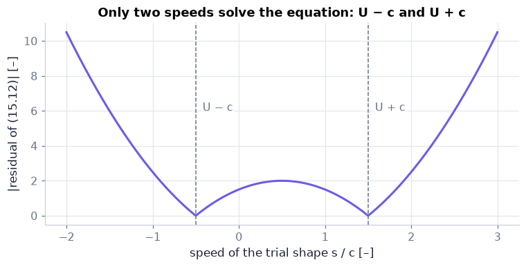

```python
U, c = 0.5, 1.0                                             # M = 0.5 in units where c = 1
speeds = np.linspace(-2.0, 3.0, 501)                        # trial speeds s from -2c to 3c
t0 = 0.2                                                    # the instant at which we test
res = [AC.convected_wave_residual(lambda x, t, s=s: np.exp(-(x - s*t)**2), s*t0, t0, c, U=U, h=1e-3)
       for s in speeds]                                     # residual at the peak of a bump riding at speed s
fig, ax = plt.subplots(figsize=(6.8, 3.4))                  # one panel
ax.plot(speeds, np.abs(res), color=COLORS["accent"])        # |left side of (15.12)| against the trial speed
for s0, lab in ((U - c, "U − c"), (U + c, "U + c")):        # the two zeros the theory predicts
    ax.axvline(s0, color=COLORS["muted"], ls="--", lw=1)    # dashed line at each
    ax.text(s0 + 0.08, 6.0, lab, ha="left", color=COLORS["muted"],
            bbox=dict(fc="white", ec="none", pad=1))        # its label, just right of the line (clear of curve and line)
ax.set(xlabel="speed of the trial shape s / c [–]", ylabel="|residual of (15.12)| [–]",
       title="Only two speeds solve the equation: U − c and U + c")   # units and message
savefig(fig, "ch15", "c01_residual_vs_speed"); plt.show()  # save to outputs/ch15/ and display
```

**What you see.** The size of the left side of $\dfrac1{c^2}\left(\dfrac{\partial}{\partial t}+U_j\dfrac{\partial}{\partial x_j}\right)^2p'-\dfrac{\partial^2p'}{\partial x_j\partial x_j}=0$ (15.12) for a Gaussian bump riding at speed s, against s, for a stream at M = 0.5 (in units where c = 1). The residual itself is a parabola in s that crosses zero at two speeds; we plot its absolute value, so the curve is a W: two V-shaped dips that touch zero at exactly those two speeds.

**How to read it.** The zeros sit at $U-c=-0.5$ (the shape travels upstream, slowly) and $U+c=1.5$ (downstream, fast). Any other speed leaves a residual — the shape would have to change as it moves, and $\dfrac1{c^2}\left(\dfrac{\partial}{\partial t}+U_j\dfrac{\partial}{\partial x_j}\right)^2p'-\dfrac{\partial^2p'}{\partial x_j\partial x_j}=0$ (15.12) does not allow that.

**What would change if…** …U rose above c? Both zeros would be positive: no shape can travel upstream. C02 turns that into "no news upstream".

**What would change if…** …the amplitude were not small? The dropped products come back, compressions travel faster than expansions, and the wave steepens into a shock — N22 below, then §15.6.

### 🧩 Two shapes sliding apart: $p'(x,t)=f(x-ct)+g(x+ct)$ (15.15) `C02`

*The question:* What does the most general plane sound wave look like — and which way does the air itself move?

#### The problem in plain words

Pluck a long string, or pop a balloon in a long pipe. The bump you made does not sit there and does not spread out: it splits into two copies that run off in opposite directions, each keeping its shape. That is all a plane sound wave can do. The air itself only shuffles: forward under a compression that runs forward, backward under one that runs backward.

#### The idea

```
t = 0:            __/‾‾\__
t > 0:   _/‾\_   ⟵ g        f ⟶   _/‾\_        each half as high
         air moves ⟵                air moves ⟶
```

Each half carries half the bump; under the right-going half the air moves right, under the left-going half it moves left.

📝 **Note.** **N15 [B]** $\dfrac1{c^2}\dfrac{\partial^2p'}{\partial t^2}-\dfrac{\partial^2p'}{\partial x^2}=0$ (15.13): $\dfrac1{c^2}\left(\dfrac{\partial}{\partial t}+U_j\dfrac{\partial}{\partial x_j}\right)^2p'-\dfrac{\partial^2p'}{\partial x_j\partial x_j}=0$ (15.12) with $U_j=0$ in one space dimension — the second-order relative of the first-order wave equation of Ch. 7. `AC.wave_equation_residual` evaluates its left side.

> 🔁 **Tools from earlier chapters used in this block** (one line each; the full primers are in the chapters named)
- **first-order wave equation and characteristics** — ∂q/∂t + c ∂q/∂x = 0 keeps q constant for an observer moving at c, so its solution is a shape sliding at c along the lines x − ct = const; the sound equation below has two such families. *(Ch. 7, P174)*
- **chain rule (two new variables)** — if p′ depends on ξ and ζ, and these depend on x and t, then ∂p′/∂x = (∂p′/∂ξ)(∂ξ/∂x) + (∂p′/∂ζ)(∂ζ/∂x), and the same for t; it translates the wave equation into the coordinates that ride with the waves. *(Ch. 1, P49, P357)*
- **frames of reference and the Galilean shift** — an observer moving at constant speed U measures positions x′ = x − Ut and the same time; velocities change by U, but pressure, density and temperature do not — used for sound in a stream, for moving shocks and for oblique shocks. *(Ch. 3, P96)*
- **domain of dependence** — the value at a point (x, t) of a hyperbolic problem depends only on the data inside the wedge cut out by the characteristics through it; here the wedge of a sound wave is bounded by the lines of slope U + c and U − c. *(Ch. 10, P227)*
- **definite integral** — ∫ f dt between two limits adds up f dt over that range; here the time integral of the pressure gradient gives the air's velocity under a sound wave. *(Ch. 1, P27)*

> 📎 **Primer — the second-order wave equation and its two characteristic coordinates.** `P357` · A first-order wave equation has one family of lines along which things are carried (Ch. 7, P174). The second-order one has two: $\xi=x-ct$ and $\zeta=x+ct$. Rewritten in ξ and ζ (chain rule, twice) it becomes $\partial^2p'/\partial\xi\,\partial\zeta=0$ — "the ξ-slope does not depend on ζ" — whose solutions are a function of ξ plus a function of ζ.

```python
import sympy as sp                                       # symbolic algebra
x, t, c = sp.symbols('x t c', positive=True)             # position, time, sound speed
f, g = sp.Function('f'), sp.Function('g')                # two arbitrary shapes
p = f(x - c*t) + g(x + c*t)                              # any two shapes, one moving each way
print(sp.simplify(sp.diff(p, t, 2)/c**2 - sp.diff(p, x, 2)))   # 0: it solves the wave equation (15.13)
```

```
0
```

#### 🧮 Derivation — d'Alembert's solution `D03` ★★ (Eq. 15.15: $p'(x,t)=f(x-ct)+g(x+ct)$)

**What we want to show.** Find *every* solution of the one-dimensional wave equation.

**Assumptions.** Still fluid, one space dimension, constant c.

**The plan.**

1. Change to the coordinates that ride with the two waves.
2. The equation collapses to one mixed derivative.
3. Integrate twice.

**Tools we use** (each explained before this point): the second-order wave equation and its two characteristic coordinates (primer P357) · chain rule (P49 reminder)

**We start from**

$$ \dfrac1{c^2}\dfrac{\partial^2p'}{\partial t^2}-\dfrac{\partial^2p'}{\partial x^2}=0\ \text{(15.13)} $$

*In words:* The pressure's acceleration in time is c² times its curvature in space

**Step 1 of 8 — Introduce two new coordinates.**

$$ \xi=x-ct,\qquad\zeta=x+ct $$

- *Why we can do this:* An invertible change of variables is always allowed. A shape moving right at speed c is constant along ξ = const, one moving left along ζ = const.
- *In words:* ξ labels points riding with a right-going wave; ζ with a left-going one.

**Step 2 of 8 — Translate the first derivatives.**

$$ \dfrac{\partial}{\partial x}=\dfrac{\partial}{\partial\xi}+\dfrac{\partial}{\partial\zeta},\qquad\dfrac{\partial}{\partial t}=-c\dfrac{\partial}{\partial\xi}+c\dfrac{\partial}{\partial\zeta} $$

- *Why we can do this:* Chain rule: $\partial\xi/\partial x=\partial\zeta/\partial x=1$, $\partial\xi/\partial t=-c$, $\partial\zeta/\partial t=+c$.
- *In words:* A step in x moves both labels forward; a step in t moves ξ back and ζ forward.

**Step 3 of 8 — Apply the x-rule twice.**

$$ \dfrac{\partial^2p'}{\partial x^2}=\dfrac{\partial^2p'}{\partial\xi^2}+2\dfrac{\partial^2p'}{\partial\xi\,\partial\zeta}+\dfrac{\partial^2p'}{\partial\zeta^2} $$

- *Why we can do this:* Square of the operator in step 2 (it has constant coefficients, so it can be applied twice like an algebraic square).
- *In words:* The curvature in x, in the new coordinates.

**Step 4 of 8 — Apply the t-rule twice.**

$$ \dfrac{\partial^2p'}{\partial t^2}=c^2\left(\dfrac{\partial^2p'}{\partial\xi^2}-2\dfrac{\partial^2p'}{\partial\xi\,\partial\zeta}+\dfrac{\partial^2p'}{\partial\zeta^2}\right) $$

- *Why we can do this:* The same, with the factor −c on one term: the mixed term gets a minus sign.
- *In words:* The acceleration in t, in the new coordinates.

**Step 5 of 8 — Substitute both into the wave equation.**

$$ -4\dfrac{\partial^2p'}{\partial\xi\,\partial\zeta}=0 $$

- *Why we can do this:* Divide step 4 by $c^2$ and subtract step 3: the pure second derivatives cancel, the mixed terms add.
- *In words:* Everything cancels except the mixed derivative.

**Step 6 of 8 — Divide by −4.**

$$ \dfrac{\partial}{\partial\zeta}\!\left(\dfrac{\partial p'}{\partial\xi}\right)=0 $$

- *Why we can do this:* −4 is not zero. Written this way the equation says something simple about $\partial p'/\partial\xi$.
- *In words:* The ξ-slope of the pressure does not change when you move in ζ.

**Step 7 of 8 — Integrate in ζ.**

$$ \dfrac{\partial p'}{\partial\xi}=F(\xi) $$

- *Why we can do this:* A quantity whose ζ-derivative is zero can depend on ξ only; the "constant" of a partial integration is an arbitrary *function* of the other variable.
- *In words:* The ξ-slope is some function of ξ alone.

**Step 8 of 8 — Integrate in ξ.**

$$ p'=f(\xi)+g(\zeta)=f(x-ct)+g(x+ct)\ \text{(15.15)} $$

- *Why we can do this:* $f$ is an antiderivative of F; the constant of this integration is an arbitrary function of ζ, called g. Then put ξ and ζ back.
- *In words:* Any solution is one shape moving right plus one shape moving left.

**Result**

$$ p'(x,t)=f(x-ct)+g(x+ct)\ \text{(15.15)} $$

*In words:* Two arbitrary shapes, each keeping its form, travelling at ±c

**What it means.** Sound does not spread or fade in one dimension; a microphone hears the shape that was emitted. **Fails when:** the wave is not plane (in three dimensions it spreads and weakens), the medium moves or varies, or the amplitude is finite.

**Check it.** Units — f and g are pressures ✓. Substitution — `sp.diff(f(x - c*t) + g(x + c*t), t, 2)/c**2 - sp.diff(…, x, 2)` simplifies to 0 (primer P357's demo). Number — c = 340 m/s: after 1 s the two shapes are 680 m apart.

> ⚠️ **Common confusion (traps in `D03`):** The two second derivatives differ only in the sign of the mixed term; integrating a partial derivative gives a function, not a number; f and g are *any* shapes, not only sines.

📝 **Note.** **N16 [B]** $u_1'(x,t)=-\dfrac1{\rho_0}\displaystyle\int\dfrac{\partial p'}{\partial x}\,dt$ (15.14) — the momentum law $\left(\dfrac{\partial}{\partial t}+U_j\dfrac{\partial}{\partial x_j}\right)u_i'+\dfrac1{\rho_0}\dfrac{\partial p'}{\partial x_i}=0$ (15.11) (with $U_j=0$) integrated in time.

> ⚠️ **Common confusion** (trap T19): the integral is indefinite; its "constant" is a function of x, fixed by "the air was at rest before the wave arrived".

```python
p_fn = lambda x, t: 50.0 * np.exp(-(x - c0 * t)**2)          # a right-going 50 Pa bump (width 1 m) riding at c0
u_quad = AC.velocity_from_pressure(p_fn, 0.5, 0.0015, rho0, t0=-0.02)   # (15.14): time integral from before the wave arrived
u_formula = AC.plane_wave_velocity(0.5, 0.0015, c0, rho0, f=lambda s: 50.0 * np.exp(-s**2))   # (15.16) with g = 0
print(u_quad, u_formula)                                     # the same air speed [m/s], two routes
```

```
0.11993063664389027 0.11993063704354091
```

**What does the code above do?**

1. `p_fn` is a right-going pressure bump.
2. `AC.velocity_from_pressure` integrates $u_1'(x,t)=-\dfrac1{\rho_0}\displaystyle\int\dfrac{\partial p'}{\partial x}\,dt$ (15.14) numerically in time, starting at t₀ = −20 ms when the bump was 7 m away and the air at x = 0.5 m was still at rest (that fixes the "constant").
3. `AC.plane_wave_velocity` uses the closed form $u_1'(x,t)=\dfrac1{\rho_0c}\left(f(x-ct)-g(x+ct)\right)$ (15.16) that D04 derives next. Both give ≈ 0.12 m/s.

#### 🧮 Derivation — The particle velocity of a plane sound wave `D04` ★ (Eq. 15.16: $u_1'(x,t)=\dfrac1{\rho_0c}\left(f(x-ct)-g(x+ct)\right)$)

**What we want to show.** Find how the air itself moves under the two travelling shapes.

**Assumptions.** The fluid was at rest before the wave arrived (step 5).

**The plan.**

1. Differentiate the solution in x.
2. Turn x-derivatives into t-derivatives.
3. Integrate exactly.
4. Fix the "constant".

**Tools we use** (each explained before this point): the chain rule for a function of $x\mp ct$ (primer P357) · the integral of an exact time derivative

**We start from**

$$ \begin{array}{l}u_1'(x,t)=-\dfrac1{\rho_0}\displaystyle\int\dfrac{\partial p'}{\partial x}\,dt\ \text{(15.14) (the momentum law integrated in time) and} \\ p'(x,t)=f(x-ct)+g(x+ct)\ \text{(15.15).}\end{array} $$

**Step 1 of 5 — Differentiate the solution in x.**

$$ \dfrac{\partial p'}{\partial x}=f'(x-ct)+g'(x+ct) $$

- *Why we can do this:* Chain rule; the prime on f and g means the derivative with respect to their own argument.
- *In words:* The pressure gradient is the sum of the two shapes' slopes.

**Step 2 of 5 — Rewrite each slope as a time derivative.**

$$ f'(x-ct)=-\dfrac1c\dfrac{\partial f}{\partial t},\qquad g'(x+ct)=+\dfrac1c\dfrac{\partial g}{\partial t} $$

- *Why we can do this:* Chain rule again: $\partial f/\partial t=-c\,f'$ and $\partial g/\partial t=+c\,g'$. We do it because $u_1'(x,t)=-\dfrac1{\rho_0}\displaystyle\int\dfrac{\partial p'}{\partial x}\,dt$ (15.14) integrates over time.
- *In words:* For a travelling shape, a slope in space is a rate in time — with opposite signs for the two directions.

**Step 3 of 5 — Insert into the time integral.**

$$ u_1'=-\dfrac1{\rho_0}\displaystyle\int\left(-\dfrac1c\dfrac{\partial f}{\partial t}+\dfrac1c\dfrac{\partial g}{\partial t}\right)dt $$

- *Why we can do this:* Substitution of steps 1–2 into $u_1'(x,t)=-\dfrac1{\rho_0}\displaystyle\int\dfrac{\partial p'}{\partial x}\,dt$ (15.14).
- *In words:* The velocity is the time-integral of two exact rates.

**Step 4 of 5 — Integrate.**

$$ u_1'=\dfrac1{\rho_0c}\left(f-g\right)+C(x) $$

- *Why we can do this:* The integral of a time derivative is the function itself; an indefinite time integral leaves an unknown that may depend on x.
- *In words:* The velocity is f minus g over $\rho_0c$, up to something fixed in time.

**Step 5 of 5 — Fix the unknown.**

$$ u_1'(x,t)=\dfrac1{\rho_0c}\left(f(x-ct)-g(x+ct)\right)\ \text{(15.16)} $$

- *Why we can do this:* Before the wave arrives at x both f and g are zero there and the air is at rest, so $C(x)=0$ for every x.
- *In words:* The air moves forward under a right-going compression and backward under a left-going one.

**Result**

$$ u_1'(x,t)=\dfrac1{\rho_0c}\left(f(x-ct)-g(x+ct)\right)\ \text{(15.16)} $$

*In words:* Pressure is f + g; velocity is (f − g)/ρ₀c

**What it means.** $u'/c=p'/\rho_0c^2$ — the air's speed is to the sound speed as the pressure disturbance is to $\rho_0c^2$: tiny. **Fails when:** the air was already moving, or the wave is not plane.

**Check it.** Units — Pa/(kg m⁻² s⁻¹) = m/s ✓. Limit — a bump at rest (f = g): u′ = 0 at t = 0 ✓. Number — 50 Pa in air: 50/(1.2 × 340) = 0.12 m/s. Code — `AC.velocity_from_pressure` (quadrature of $u_1'(x,t)=-\dfrac1{\rho_0}\displaystyle\int\dfrac{\partial p'}{\partial x}\,dt$ (15.14)) equals `AC.plane_wave_velocity`.

📝 **Notes taught inside `D04`:** **N17 [B]** the particle velocity $u_1'(x,t)=\dfrac1{\rho_0c}\left(f(x-ct)-g(x+ct)\right)$ (15.16)

| Wave | Air velocity | In words |
| --- | --- | --- |
| right-going f | $u'=+p'/\rho_0c$ | a compression pushes the air the way the wave goes |
| left-going g | $u'=-p'/\rho_0c$ | a compression pushes the air the other way — still the way *its* wave goes |

$\rho_0c$ is the **acoustic impedance** (our name; 416.9 kg/(m² s) for sea-level air). And $u'/c=p'/\rho_0c^2$ is the condensation: **the air moves far slower than the wave**.

> ⚠️ **Common confusion (traps in `D04`):** The minus sign in front of g comes from $\partial g/\partial t=+c\,g'$ (trap T19); the integration "constant" is a function of x; u′ is not the wave speed.

#### ✏️ Tiny example: a bump released at rest

$c$ = 340 m/s, $\rho_0$ = 1.2 kg/m³. At t = 0 the pressure is a bump F(x) of height 100 Pa and the air is at rest, so $\partial p'/\partial t=G=0$.

1. The initial-value formulas $f(x)=\dfrac12\left[F(x)-\dfrac1c\displaystyle\int_0^xG(\hat x)\,d\hat x\right],\ g(x)=\dfrac12\left[F(x)+\dfrac1c\displaystyle\int_0^xG(\hat x)\,d\hat x\right]$ (unnumbered, Exercise 15.1) with G = 0 give $f=g=\tfrac12F$: two bumps of 50 Pa.
2. After 1 s their centres are at x = +340 m and x = −340 m.
3. Under the right-going one $u'=50/(1.2\times340)$ = +0.12 m/s; under the left-going one −0.12 m/s.
4. At t = 0 the two velocities cancel: the air was at rest ✓.
5. Wave speed 340 m/s, air speed 0.12 m/s: a ratio of 3.6 × 10⁻⁴ — the condensation.

This is **N21 [B]**: the initial-value form, stated; result given, not derived.

```python
F = AC.pulse("gaussian", width=1.0, amplitude=100.0)          # the initial bump F(x) = 100 exp(-x²) [Pa]
f, g = AC.dalembert_fg(F, lambda s: 0.0 * s, c0)              # Exercise-15.1 formulas with G = 0: the two halves
x = np.linspace(-8.0, 8.0, 801)                               # positions [m]
for t in (0.0, 0.01):                                         # at release and 10 ms later (the halves 3.4 m from the centre)
    p = AC.dalembert_initial_value(x, t, c0, F)               # (15.15): p' = f(x - ct) + g(x + ct)
    u = AC.plane_wave_velocity(x, t, c0, rho0, f=f, g=g)      # (15.16): u' = (f - g)/(rho0 c)
    print(f"t = {1e3*t:4.1f} ms: max p' = {p.max():6.2f} Pa, max |u'| = {np.abs(u).max():.4f} m/s")
print(np.allclose(AC.dalembert_initial_value(x, 0.0, c0, F), F(x)), np.allclose(AC.plane_wave_velocity(x, 0.0, c0, rho0, f=f, g=g), 0.0))   # True True
```

```
t =  0.0 ms: max p' = 100.00 Pa, max |u'| = 0.0000 m/s
t = 10.0 ms: max p' =  50.00 Pa, max |u'| = 0.1199 m/s
True True
```

**What does the code above do?**

1. `AC.pulse` builds the bump as a function (a `lambda`-like callable: give it positions, it returns pressures).
2. `AC.dalembert_fg` applies the initial-value formulas $f(x)=\dfrac12\left[F(x)-\dfrac1c\displaystyle\int_0^xG(\hat x)\,d\hat x\right],\ g(x)=\dfrac12\left[F(x)+\dfrac1c\displaystyle\int_0^xG(\hat x)\,d\hat x\right]$ (unnumbered, Exercise 15.1): with no initial rate of change, f and g are each half of F.
3. At t = 0 the pressure is the bump itself (100 Pa) and the air is at rest; 10 ms later two 50 Pa halves have separated and the air under each moves at 50/416.9 = 0.120 m/s.
4. The last line checks the two starting conditions: True, True.

```python
c, t = c0, 0.01                                              # sound speed [m/s] and a time [s]
shape = lambda s: 50.0 * np.exp(-s**2)                       # each half: 50 Pa Gaussian
p_mine = shape(x - c*t) + shape(x + c*t)                     # (15.15) written out
u_mine = (shape(x - c*t) - shape(x + c*t)) / (rho0 * c)      # (15.16) written out
assert np.allclose(p_mine, AC.dalembert(x, t, c, f=shape, g=shape))                 # same pressure as the library
assert np.allclose(u_mine, AC.plane_wave_velocity(x, t, c, rho0, f=shape, g=shape)) # same air speed as the library
print("from scratch = AC.dalembert and AC.plane_wave_velocity")
```

```
from scratch = AC.dalembert and AC.plane_wave_velocity
```

**From scratch.** $p'(x,t)=f(x-ct)+g(x+ct)$ (15.15) and $u_1'(x,t)=\dfrac1{\rho_0c}\left(f(x-ct)-g(x+ct)\right)$ (15.16) are one line each; the assertions confirm that the library does exactly this.

```python
x = np.linspace(-8.0, 8.0, 400)                              # positions [m]
n_frames = 10 if FAST else 16                                # frames (fewer when FAST; each two-panel frame costs 1–3 s to draw)
times = np.linspace(0.0, 0.018, n_frames)                    # 0 to 18 ms: the halves travel 6 m
right = lambda s: 100.0 * np.exp(-(s + 4.0)**2)              # top panel: a right-going 100 Pa pulse starting at x = -4 m
fig, (a1, a2) = plt.subplots(2, 1, figsize=(6.8, 4.6), sharex=True)   # two panels, one clock
(pt,) = a1.plot(x, right(x), color=COLORS["orange"], label="p′ [Pa]")             # pressure (orange)
(ut,) = a1.plot(x, rho0 * c0 * 0 * x, color=COLORS["blue"], ls="--", label="ρ₀c·u′ [Pa]")   # air speed × rho0 c (blue)
a1.set(ylim=(-60, 110), ylabel="[Pa]", title="A right-going pulse: the air moves with the compression")
a1.legend(loc="upper right", fontsize=8)                    # legend
F0 = lambda s: 100.0 * np.exp(-s**2)                         # bottom panel: a bump released at rest
(pb,) = a2.plot(x, F0(x), color=COLORS["orange"])            # pressure
(ub,) = a2.plot(x, 0 * x, color=COLORS["blue"], ls="--")     # rho0 c u'
a2.set(ylim=(-60, 110), xlabel="x [m]", ylabel="[Pa]", title="A bump released at rest splits into two half-height pulses")
def update(i):                                               # draw frame i
    t = times[i]                                             # current time [s]
    pt.set_ydata(right(x - c0 * t))                          # (15.15) with g = 0
    ut.set_ydata(rho0 * c0 * AC.plane_wave_velocity(x, t, c0, rho0, f=right))      # (15.16): equals p' for a right-going wave
    pb.set_ydata(AC.dalembert(x, t, c0, f=lambda s: 0.5 * F0(s), g=lambda s: 0.5 * F0(s)))   # two halves
    ub.set_ydata(rho0 * c0 * AC.plane_wave_velocity(x, t, c0, rho0, f=lambda s: 0.5 * F0(s), g=lambda s: 0.5 * F0(s)))
    return pt, ut, pb, ub
show_animation(animate(update, frames=n_frames, fig=fig, interval=60), player="video")   # smooth motion: video player
```

[video not shown]

**N18 [B]** (animation A1). Top: one right-going pulse; the blue dashed curve is the air speed multiplied by $\rho_0c$, so that it is in pascals — it lies exactly on the pressure. Bottom: the bump released at rest; the two halves carry air speeds of opposite sign, which cancel at t = 0.

**What you see.** Top: a pressure pulse (orange) sliding right, with $\rho_0c\,u'$ (blue dashed) on top of it. Bottom: a 100 Pa bump splitting into two 50 Pa pulses; the blue curve is positive under the right-going half and negative under the left-going one.

**How to read it.** Neither shape changes as it moves — that is $p'(x,t)=f(x-ct)+g(x+ct)$ (15.15). In the top panel the two curves coincide: $u'=p'/\rho_0c$. In the bottom panel the air moves outward from the centre under both halves: each half pushes the air its own way.

**What would change if…** …the bump had been released with the air already moving right at $u'=F/\rho_0c$? Then $G\neq0$ and only a right-going pulse would appear (all of it in f).

📝 **Note.** **N19 [B]** In a stream of speed U the two shapes ride at U + c and U − c: $p'(x,t)=f(x-(c+U)t)+g(x+(c-U)t)$ (15.17).

#### 🧮 Derivation — Sound in a uniform stream `D05` ★ (Eq. 15.17: $p'(x,t)=f(x-(c+U)t)+g(x+(c-U)t)$)

**What we want to show.** Find how the two shapes travel when the whole fluid moves at speed U.

**Assumptions.** U and c constant; U along +x.

**The plan.**

1. Ride with the stream.
2. There the fluid is still, so D03 applies.
3. Come back.

**Tools we use** (each explained before this point): the Galilean shift (P96 reminder) · D03

**We start from**

$$ \begin{array}{l}\dfrac1{c^2}\left(\dfrac{\partial}{\partial t}+U_j\dfrac{\partial}{\partial x_j}\right)^2p'-\dfrac{\partial^2p'}{\partial x_j\partial x_j}=0\ \text{(15.12) with}\ U_j=(U,0,0)\ \text{in one} \\ \text{dimension:}\ \dfrac1{c^2}\left(\dfrac{\partial}{\partial t}+U\dfrac{\partial}{\partial x}\right)^2p'-\dfrac{\partial^2p'}{\partial x^2}=0\ \text{.}\end{array} $$

**Step 1 of 5 — Ride with the stream.**

$$ x'=x-Ut,\qquad t'=t $$

- *Why we can do this:* A change to a frame moving at constant speed U; Newtonian mechanics is the same in it. We choose it because the fluid is at rest there.
- *In words:* $x'$ is the position measured by someone drifting with the fluid.

**Step 2 of 5 — Translate the derivatives.**

$$ \dfrac{\partial}{\partial x}=\dfrac{\partial}{\partial x'},\qquad\dfrac{\partial}{\partial t}+U\dfrac{\partial}{\partial x}=\dfrac{\partial}{\partial t'} $$

- *Why we can do this:* Chain rule: $\partial x'/\partial x=1$, $\partial x'/\partial t=-U$, so $\partial/\partial t=\partial/\partial t'-U\,\partial/\partial x'$.
- *In words:* The convective bracket is just the time derivative seen by the drifting observer.

**Step 3 of 5 — Rewrite the equation.**

$$ \dfrac1{c^2}\dfrac{\partial^2p'}{\partial t'^2}-\dfrac{\partial^2p'}{\partial x'^2}=0 $$

- *Why we can do this:* Substitute step 2; this is $\dfrac1{c^2}\dfrac{\partial^2p'}{\partial t^2}-\dfrac{\partial^2p'}{\partial x^2}=0$ (15.13) in the primed variables.
- *In words:* In the drifting frame it is the still-fluid wave equation.

**Step 4 of 5 — Use d'Alembert's solution there.**

$$ p'=f(x'-ct')+g(x'+ct') $$

- *Why we can do this:* D03 found every solution of that equation.
- *In words:* In the drifting frame: one shape each way at speed c.

**Step 5 of 5 — Come back to the fixed frame.**

$$ p'(x,t)=f(x-(c+U)t)+g(x+(c-U)t)\ \text{(15.17)} $$

- *Why we can do this:* Put $x'=x-Ut$: $x-Ut-ct=x-(c+U)t$ and $x-Ut+ct=x+(c-U)t$. Substituting the definition of the drifting coordinate back is always allowed; we do it to read the speeds in the fixed frame.
- *In words:* One shape travels at U + c; the other at U − c, which is upstream only while U < c.

**Result**

$$ p'(x,t)=f(x-(c+U)t)+g(x+(c-U)t)\ \text{(15.17)} $$

*In words:* The stream simply carries both shapes along

**What it means.** At U = c the upstream-running shape stands still; beyond it nothing travels upstream — the root of choking (C09), shocks (C07) and the Mach cone (C13). **Fails when:** the stream is not uniform.

**Check it.** Units — (c ± U)t is a length ✓. Limit — U = 0: $p'(x,t)=f(x-ct)+g(x+ct)$ (15.15) ✓. Number — M = 0.5 at sea level: +510 and −170 m/s; M = 2: +1021 and +340 m/s. Code — `AC.wave_speeds`.

> ⚠️ **Common confusion (traps in `D05`):** g's speed is U − c, whose sign changes at U = c; "downstream" presumes U > 0 (trap T19); the shapes f and g are unchanged — only their speeds.

```python
print(AC.wave_speeds(0.5 * c0, c0))                          # M = 0.5: (U + c, U - c) = (510.4, -170.1) m/s
print(AC.wave_speeds(2.0 * c0, c0))                          # M = 2: (1020.9, +340.3) m/s — both downstream
print(AC.upstream_signal_possible(0.5 * c0, c0), AC.upstream_signal_possible(2.0 * c0, c0))   # True, False
```

```
(510.4384302979156, -170.14614343263852)
(1020.8768605958312, 340.29228686527705)
True False
```

> ⚠️ **Common confusion:** (trap T19) "Downstream" presumes U > 0; with the stream flowing in −x the roles of f and g swap.

📝 **Note.** **N20 [B]** **Range of influence.** For U < c one shape still travels upstream: a point feels what happens on both sides. For U > c both travel downstream: a point feels only what is upstream of it. That is why a choked nozzle stops listening (C09) and why you hear a supersonic aircraft only after it has passed (C13).

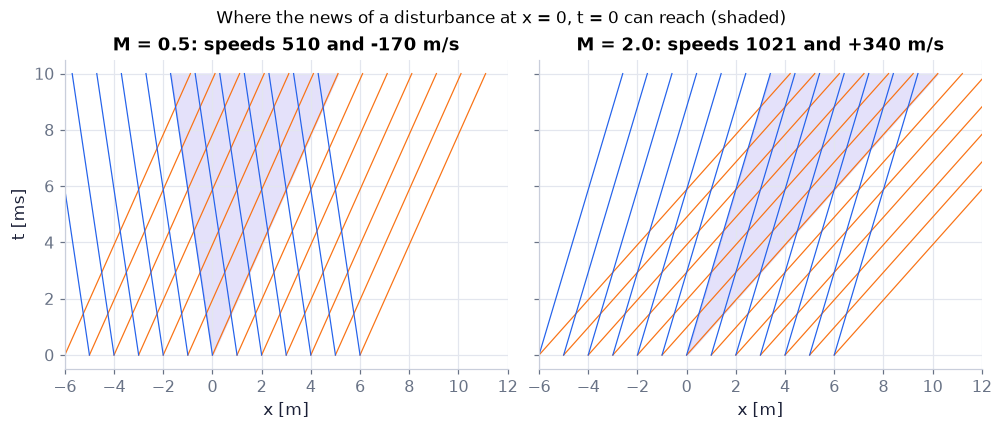

```python
t = np.linspace(0.0, 0.01, 50)                              # times [s]
x0 = np.linspace(-6.0, 6.0, 13)                             # starting points of the lines [m]
fig, axes = plt.subplots(1, 2, figsize=(9.0, 3.8), sharey=True)   # two panels: M = 0.5 and M = 2
for ax, M in zip(axes, (0.5, 2.0)):                         # one Mach number per panel
    ch = AC.xt_characteristics(M * c0, c0, x0, t)           # the two families x = x0 + (U ± c) t
    for k in range(x0.size):                                # every starting point
        ax.plot(ch["x_plus"][k], 1e3 * t, color=COLORS["orange"], lw=0.8)    # f family, slope U + c
        ax.plot(ch["x_minus"][k], 1e3 * t, color=COLORS["blue"], lw=0.8)     # g family, slope U - c
    one = AC.xt_characteristics(M * c0, c0, 0.0, t)         # the two lines through the origin
    ax.fill_betweenx(1e3 * t, one["x_minus"][0], one["x_plus"][0], color=COLORS["accent"], alpha=0.18)   # its range of influence
    ax.set(xlim=(-6, 12), xlabel="x [m]", title=f"M = {M}: speeds {M*c0 + c0:.0f} and {M*c0 - c0:+.0f} m/s")   # labels
axes[0].set_ylabel("t [ms]")                                # time axis
fig.suptitle("Where the news of a disturbance at x = 0, t = 0 can reach (shaded)", fontsize=11)   # the message
savefig(fig, "ch15", "c02_xt_characteristics"); plt.show()  # save and display
```

**What you see.** Two x–t diagrams (time upward). Orange lines: the f family, slope U + c. Blue lines: the g family, slope U − c. The shaded wedge is everything a disturbance made at the origin can reach.

**How to read it.** At M = 0.5 the blue lines lean left: news travels upstream at 170 m/s and the wedge opens to both sides. At M = 2 both families lean right: the wedge lies entirely downstream — a point upstream of the disturbance never hears it (the **domain of dependence** of Ch. 10, read the other way round).

**What would change if…** …M were exactly 1? The blue lines would be vertical: the upstream-running wave would stand still at its starting point — the picture of a sonic throat (C09).

#### 🎮 Interactive: What is a sound pulse made of?

**Why interactive rather than a static figure:** you release the bump, scrub time and watch f and g separate with tracer particles moving opposite ways; then you drag the stream through U = c and one family of characteristics tips over — the change of regime is something you do, not something you read.

Start with the **Walkthrough**; the **Explain** tab works every number out with your settings, and the **Derivation** tab (where there is one) steps through the same derivation as above. The pressure is the disturbance p′ about the undisturbed air, its size set as the dimensionless amplitude p′/ρ₀c²; the probe shows p′ and the air speed u′ at one point.

**What to try:**

- Release a bump at rest and step time: each half is half as high.
- Click a point under each half: the air moves opposite ways.
- Drag the stream Mach number through 1 and watch the x–t view: the upstream line stands up, then leans downstream.

```python
show_viz("ch15", "sound_pulse_dalembert")   # full-width explainer; ⤢ Full screen for more room
```

🎮 Interactive 1/9 What is a sound pulse made of? Open alone ↗

[interactive chart not shown]

📝 **Note.** **N22 [B]** **Steepening (the book argues in words; the formulas are ours).** In a compression the gas is hotter, so c is larger, and the gas itself moves forward: each wavelet travels at $\left.\dfrac{dx}{dt}\right\rvert_{\text{wavelet}}=u+c=c_0+\dfrac{\gamma+1}{2}u,\ \ t_{\text{break}}=\dfrac{2}{(\gamma+1)\max(-\partial u_0/\partial x)}$ (ours). Crests catch up with troughs; a sine becomes a sawtooth; the limit is a shock. Result given, not derived.

> 🔁 **Recap — The shallow-water simple wave** (Ch. 7 N81). The same steepening happens to a long water wave: its crest moves at a speed set by the local depth. It is the γ = 2 twin of this gas wave (`ch07.simple_wave_evolve`).

> 📎 **Primer — Riemann invariant.** `P358` · A combination of the fluid speed and the sound speed that keeps its value along a moving wavelet. In a wave going one way through still gas, $u-2c/(\gamma-1)$ has the same value everywhere, so $c=c_0+\tfrac12(\gamma-1)u$: each bit of the wave knows its own speed.

```python
g, c0_ = 1.4, 340.0                           # air
u = np.array([-5.0, 0.0, 5.0])                # fluid speed in trough, node, crest [m/s]
c = c0_ + 0.5*(g - 1)*u                       # local sound speed from the invariant
print(u - 2*c/(g - 1), u + c)                 # the invariant is constant; wavelet speeds 334, 340, 346 m/s
```

```
[-1700. -1700. -1700.] [334. 340. 346.]
```

```python
L = 150.0                                                    # a loud 1 kHz tone [dB]
p_peak = np.sqrt(2) * 20e-6 * 10**(L / 20)                   # peak pressure of a sine [Pa]: rms × sqrt(2) -> 894 Pa
u_a = p_peak / (rho0 * c0)                                   # (15.16): air-speed amplitude -> 2.15 m/s
lam = c0 / 1000.0                                            # wavelength [m]: c / frequency
x = np.linspace(0.0, lam, 400)                               # one wavelength
u0 = u_a * np.sin(2 * np.pi * x / lam)                       # the initial air speed [m/s]
tb = AC.breaking_time(u0, x)                                 # first time two wavelets meet [s]
print(f"peak {p_peak:.0f} Pa, u_a = {u_a:.2f} m/s, t_break = {1e3*tb:.1f} ms, distance {c0*tb:.2f} m = {c0*tb/lam:.0f} wavelengths")
print(AC.simple_wave_speed(np.array([-u_a, 0.0, u_a]), c0))  # wavelet speeds in trough, node, crest [m/s]
```

```
peak 894 Pa, u_a = 2.15 m/s, t_break = 21.0 ms, distance 7.16 m = 21 wavelengths
[337.7175 340.2923 342.867 ]
```

**What does the code above do?**

1. 150 dB is a peak pressure of 894 Pa; by $u_1'(x,t)=\dfrac1{\rho_0c}\left(f(x-ct)-g(x+ct)\right)$ (15.16) the air moves at 2.15 m/s.
2. `AC.breaking_time` finds where the speed falls fastest with x (the steepest compression) and returns $t_{\text{break}}=2/[(\gamma+1)\max(-\partial u_0/\partial x)]$: 21 ms, after travelling 7.2 m — about 21 wavelengths.
3. `AC.simple_wave_speed` gives the three wavelet speeds: the crest runs 5 m/s faster than the trough.

```python
n_frames = 7 if FAST else 13                                 # frames from 0 to the breaking time (13: stops at exactly ¼, ½ and 1)
times = np.linspace(0.0, tb, n_frames)                       # [s]
fig, ax = plt.subplots(figsize=(6.8, 3.4))                   # one panel
ax.plot(1e3 * x, u0, color=COLORS["muted"], ls="--", lw=1, label="acoustic (shape kept)")   # the ghost
(line,) = ax.plot(1e3 * x, u0, color=COLORS["accent"], lw=2, label="simple wave")            # the steepening wave
ax.set(xlim=(0, 1e3 * lam), ylim=(-1.2 * u_a, 1.2 * u_a), xlabel="x − c₀t [mm] (riding with the sound)",
       ylabel="air speed u [m/s]")                           # fixed axes
ax.legend(loc="lower left", fontsize=8)                      # legend
def update(i):                                               # frame i
    s = AC.simple_wave_evolve(u0, x, times[i], c0)           # each wavelet moved at c0 + (gamma+1)/2 u0
    line.set_xdata(1e3 * (s["x_points"] - c0 * times[i]))    # position seen by an observer riding at c0
    ax.set_title(f"t = {times[i]/tb:.2f} × t_break: compressions catch up")   # time as a fraction of the breaking time
    return (line,)
show_animation(animate(update, frames=n_frames, fig=fig, interval=120), player="frames")   # step through: stop at ¼, ½, 1
```

[figure not shown]

Once Loop Reflect

**Animation A2.** Each point of the wave keeps its air speed and moves at $c_0+\tfrac{\gamma+1}{2}u$; we watch from a frame riding at $c_0$, so the acoustic wave (grey dashed) stands still. Use the frame buttons to stop at ¼, ½ and 1 × the breaking time.

**What you see.** One wavelength of a 150 dB tone, air speed against position, in a frame that rides with the sound. The grey dashed sine is what acoustics predicts (no change); the purple curve is the simple wave.

**How to read it.** Points with u > 0 drift right, points with u < 0 drift left. Where the speed falls with x (the compression, in the middle of the frame) the curve tilts until it is vertical at $t=t_{\text{break}}$: a shock forms there.

**What would change if…** …you looked at the expansion half? It flattens instead: only compressions become shocks. And a quieter tone (say 120 dB, about 32 times smaller in pressure) breaks about 32 times later — after some 660 wavelengths.

📝 **Note.** **N114 [C]** The full nonlinear (Euler) equations can carry a wave *through* breaking, which the simple-wave formula cannot; Ch. 10's MacCormack scheme (C10) is the tool. Not built here (it is part of the backup explainer).

**What would change if…** …the wave were confined in a duct whose area changes? Then we stop following the wave and write the three conservation laws between two stations — C03.

## 15.3 Basic Equations for One-Dimensional Flow

**What is this section about?** Mass, energy and momentum written between two stations of a duct. The rest of the chapter is these three lines with different terms switched on.

### 🧩 The three duct laws: $h_2+\tfrac12u_2^2-h_1-\tfrac12u_1^2=Q$ (15.22) `C03`

*The question:* What must be the same at two cross-sections of a duct — and which of the three statements survives friction and shocks?

#### The problem in plain words

A hair dryer, a jet engine intake, a rocket nozzle: gas goes in one end and out the other. We do not want the flow at every point — only one speed, pressure, density and temperature per cross-section. Three bookkeeping statements tie the outlet to the inlet: what goes in comes out (mass); what the gas carries in plus the heat added equals what it carries out (energy); and the change of momentum equals the push of the pressures and the walls.

#### The idea

```
station 1 │→ u₁ p₁ ρ₁ T₁   A₁ ⟩═══════════⟨ A₂   u₂ p₂ ρ₂ T₂ →│ station 2
                walls: force F on the fluid · heat Q per kg added
```

| Law | What crosses the stations | Switched on in |
| --- | --- | --- |
| mass | ṁ = ρuA | C05, C06 |
| energy | $h+\tfrac12u^2$ per kg, plus the heat Q | C04, C07, C11 |
| momentum | ṁu, plus the pressure forces pA and the wall force F | C07, C11 |

📝 **Note.** **N23 [B]** **Hypotheses of one-dimensional duct flow:** (1) a straight centreline; (2) the area A(x) varies slowly; (3) one value of u, p, ρ, T per cross-section; (4) steady flow.

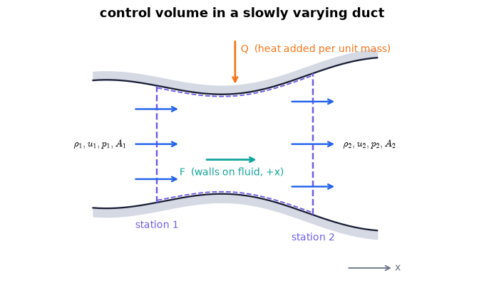

```python
fig = draw_duct_control_volume()                             # our drawing: control volume between stations 1 and 2, normals, F and Q
plt.show()                                                   # display it
```

**How to read it.** The outward normal at station 1 points *against* the flow and at station 2 *with* it — that is where the signs of the inlet and outlet terms in D06 and D07 come from. Nothing crosses the side wall except heat.

**What would change if…** …the area changed abruptly (a step)? Then hypothesis (3) fails near the step: the flow separates and one value per cross-section is no longer enough.

> 🔁 **Recap — Control volume and the Reynolds transport theorem** (Ch. 3 C15, Ch. 4 C01). A fixed region of space through whose surface the fluid flows; the rate of change of what is inside plus the net outflow through the surface equals what is produced inside. In steady flow only the surface fluxes remain.

> 🔁 **Recap — Mass conservation on a control volume `R09`** (Ch. 4 §4.2 (C01)). What flows in flows out: $\rho uA=\dot m=\text{const.}$ (15.18). **New here:** on this control volume the integral law is one line.

```python
print(GD.mass_flow(1.0, 100.0, 0.02))                        # (15.18): rho u A = 1.0 × 100 × 0.02 = 2 kg/s
```

```
2.0
```

> 🔁 **Recap — The steady energy integral `R10`** (Ch. 4 §4.8 (C10)). $\displaystyle\int_{A^*}\rho\left(e+\tfrac12u_i^2\right)u_jn_j\,dA=\int_{A^*}u_i\tau_{ij}n_j\,dA-\int_{A^*}q_jn_j\,dA$ (15.20): the flux of internal plus kinetic energy out of the surface equals the rate of work of the surface stresses plus the heat conducted in.

> ⚠️ **Common confusion** (trap T2): here $A^*$ is the control surface, not the sonic throat area of $\dfrac{A}{A^*}=\dfrac1M\left[\dfrac{2}{\gamma+1}\left(1+\dfrac{\gamma-1}{2}M^2\right)\right]^{(1/2)(\gamma+1)/(\gamma-1)}$ (15.31).

> 🔁 **Tools from earlier chapters used in this block** (one line each; the full primers are in the chapters named)
- **power of a force; heat flux through a surface** — a force does work at the rate force × velocity, and heat q_j crossing a surface delivers −∫q_j n_j dA; here the pressure on the inlet and outlet faces of a duct does work, and the heat added per kilogram is Q. *(Ch. 4, P127)*
- **momentum flux through a surface** — fluid crossing a patch dA carries its momentum with it at the rate ρu(u·n) dA; here the inlet and outlet faces of a duct carry −ṁu₁ in and +ṁu₂ out. *(Ch. 4, P114)*
- **logarithmic differentiation** — d(ln f) = df/f turns a product of powers into a sum of relative changes; here ρuA = const becomes dρ/ρ + du/u + dA/A = 0, and p = ρRT becomes dp/p = dρ/ρ + dT/T. *(Ch. 1, P52)*

> 🔁 **Recap — Enthalpy** (Ch. 1). $h=e+p/\rho$; for a perfect gas $h=C_pT$ and $e=C_vT$.

#### 🧮 Derivation — The energy equation of duct flow `D06` ★★ (Eq. 15.22: $h_2+\tfrac12u_2^2-h_1-\tfrac12u_1^2=Q$)

**What we want to show.** Turn the general energy integral into one line between two stations of a duct.

**Assumptions.** Steady (start); one value of u, p, ρ, e per cross-section (steps 2–4); no slip and no through-flow at the wall (steps 3, 4); viscous normal stress negligible on the end faces (step 4).

**The plan.**

1. Split the surface into inlet, outlet, wall.
2. Evaluate each integral on each part.
3. Divide by the mass flow.
4. Spot the enthalpy.

**Tools we use** (each explained before this point): surface integrals on a simple control volume (Ch. 4 recap) · power of a force and heat flux (P127 reminder) · enthalpy (Ch. 1 recap)

**We start from**

$$ \displaystyle\int_{A^*}\rho\left(e+\tfrac12u_i^2\right)u_jn_j\,dA=\int_{A^*}u_i\tau_{ij}n_j\,dA-\int_{A^*}q_jn_j\,dA\ \text{(15.20)} $$

*In words:* Energy carried out through the surface = work done on the surface + heat conducted in; (steady, no body force)

**Step 1 of 8 — Split the control surface.**

$$ A^*=A_1\cup A_2\cup A_{\text{wall}} $$

- *Why we can do this:* An integral over a surface is the sum of the integrals over its parts. (Here $A^*$ is the control surface — not the sonic area of later sections.)
- *In words:* Inlet face, outlet face, side wall.

**Step 2 of 8 — Energy flux through the inlet.**

$$ \displaystyle\int_{A_1}\rho\left(e+\tfrac12u^2\right)u_jn_j\,dA=-\left(e+\tfrac12u^2\right)_1\rho_1u_1A_1=-\left(e+\tfrac12u^2\right)_1\dot m $$

- *Why we can do this:* Everything is uniform over the face and the outward normal points *against* the flow there, so $u_jn_j=-u_1$; then $\rho uA=\dot m=\text{const.}$ (15.18).
- *In words:* Energy enters with the mass flow — a negative outflow.

**Step 3 of 8 — Outlet and wall.**

$$ \displaystyle\int_{A_2}(\dots)=+\left(e+\tfrac12u^2\right)_2\dot m,\qquad\int_{A_{\text{wall}}}(\dots)=0 $$

- *Why we can do this:* On the outlet the normal points with the flow; no fluid crosses the wall ($u_jn_j=0$).
- *In words:* Energy leaves with the same mass flow; none through the wall.

**Step 4 of 8 — Work of the surface stresses.**

$$ \displaystyle\int_{A^*}u_i\tau_{ij}n_j\,dA=(upA)_1-(upA)_2 $$

- *Why we can do this:* On the end faces the stress is the pressure, $\tau_{ij}n_j=-p\,n_i$, so $u_i\tau_{ij}n_j=-p\,u_in_i$: $+pu$ at the inlet, $-pu$ at the outlet. At the wall the velocity is zero (no slip): no work.
- *In words:* The surroundings push fluid in at station 1 and are pushed by it at station 2.

**Step 5 of 8 — Name the heat.**

$$ -\left(e+\tfrac12u^2\right)_1\dot m+\left(e+\tfrac12u^2\right)_2\dot m=(upA)_1-(upA)_2+\dot mQ\ \text{(15.21), with}\ \dot mQ\equiv-\displaystyle\int_{A^*}q_jn_j\,dA $$

- *Why we can do this:* A definition: Q is the heat *added* per unit mass of fluid passing through. Collecting steps 2–4 gives the line.
- *In words:* Energy out minus energy in = pressure work + heat added.

**Step 6 of 8 — Divide by the mass flow.**

$$ \left(e+\tfrac12u^2\right)_2-\left(e+\tfrac12u^2\right)_1=\left(\dfrac p\rho\right)_1-\left(\dfrac p\rho\right)_2+Q $$

- *Why we can do this:* $\dot m=\rho uA\neq0$, so $upA/\dot m=p/\rho$ — the *flow work* per kilogram.
- *In words:* Per kilogram: the energy gained equals net flow work plus heat.

**Step 7 of 8 — Bring each station's terms together.**

$$ \left(e+\dfrac p\rho+\dfrac12u^2\right)_2-\left(e+\dfrac p\rho+\dfrac12u^2\right)_1=Q $$

- *Why we can do this:* Move the two $p/\rho$ terms to the left.
- *In words:* One combination at the outlet minus the same at the inlet equals the heat added.

**Step 8 of 8 — Recognise the enthalpy.**

$$ h_2+\tfrac12u_2^2-h_1-\tfrac12u_1^2=Q\ \text{(15.22)} $$

- *Why we can do this:* By definition $h=e+p/\rho$. Replacing a combination by its name changes nothing; we do it because h is the quantity tables and gas laws give.
- *In words:* Enthalpy plus kinetic energy per kilogram changes only by the heat added.

**Result**

$$ h_2+\tfrac12u_2^2-h_1-\tfrac12u_1^2=Q\ \text{(15.22)} $$

*In words:* The total enthalpy changes only by heat

**What it means.** Nothing in the derivation asked whether the flow *between* the stations is frictionless or smooth — so the line holds across friction and across shocks. That is why $T_0$ is the chapter's fixed point. **Fails when:** the flow is unsteady, a shaft does work, gravity matters, or the profiles at the stations are far from uniform.

**Check it.** Units — J/kg throughout ✓. Limit — Q = 0, perfect gas: $C_pT_0=C_pT+\tfrac12u^2$ (15.27) when station 2 is at rest. Number — air from 100 to 300 m/s with Q = 0: $C_p\Delta T$ = ½(10⁴ − 9 × 10⁴) → ΔT = −40 K. Code — `GD.energy_residual` ≈ 0 along our nozzle.

📝 **Notes taught inside `D06`:** **N25 [B]** the duct energy law $-\left(e+\tfrac12u^2\right)_1\dot m+\left(e+\tfrac12u^2\right)_2\dot m=(upA)_1-(upA)_2+\dot mQ$ (15.21) → $h_2+\tfrac12u_2^2-h_1-\tfrac12u_1^2=Q$ (15.22) (steps 1–5). Face by face:

| Face | Outward normal | What crosses |
| --- | --- | --- |
| inlet $A_1$ | against the flow ($u_jn_j=-u_1$) | energy in with ṁ; pressure work done *on* the fluid |
| outlet $A_2$ | with the flow ($u_jn_j=+u_2$) | energy out with ṁ; pressure work done *by* the fluid |
| wall | across the flow ($u_jn_j=0$) | heat only (no slip: no work) |

**N26 [B]** flow work $p/\rho$ (step 6)

> ⚠️ **Common confusion (traps in `D06`):** The normal points against the flow at the inlet; the wall does no work because of no slip, even with friction; Q is heat *added*; $A^*$ here is the control surface (trap T2); adiabatic (Q = 0) is not isentropic (trap T17).

📝 **Note.** **N26 [B], continued** **Flow work.** Pushing one kilogram across a face against the pressure costs $upA/\dot m=p/\rho$ of work. That is why $h=e+p/\rho$ replaces e in a flowing system.

```python
T = 293.15                                                   # room temperature [K]
print(air.R * T, air.cv * T, air.cp * T)                     # p/rho = RT = 84.1, e = 210.4, h = 294.5 kJ/kg (×1000)
print((air.R * T) / (air.cp * T), (1.4 - 1) / 1.4)           # flow work is 29 % of h: (gamma - 1)/gamma
```

```
84148.7075 210371.76875000005 294520.47625
0.2857142857142857 0.28571428571428564
```

> 🔁 **Recap — The steady momentum integral `R11`** (Ch. 4 §4.4 (C03)). $\displaystyle\int_{A^*}\rho u_iu_jn_j\,dA=\int_{A^*}\tau_{ij}n_j\,dA$ (15.23): momentum flux out = force of the surface stresses.

#### 🧮 Derivation — Mass and momentum in a duct `D07` ★★ (Eq. 15.25: $\dot m\dfrac{du}{dx}=-A\dfrac{dp}{dx}-F_f$)

**What we want to show.** Write mass and momentum for a duct in the differential forms every later section uses.

**Assumptions.** Steady, quasi-one-dimensional (all steps); frictionless from step 8.

**The plan.**

1. Differentiate the mass law logarithmically.
2. Evaluate the momentum integral between two stations.
3. Shrink the distance to dx and split the wall force.
4. Drop friction.

**Tools we use** (each explained before this point): logarithmic differentiation (P52 reminder) · product rule (P38 reminder) · momentum flux (P114 reminder)

**We start from**

$$ \rho uA=\dot m=\text{const.}\ \text{(15.18) and}\ \displaystyle\int_{A^*}\rho u_iu_jn_j\,dA=\int_{A^*}\tau_{ij}n_j\,dA\ \text{(15.23).} $$

**Step 1 of 9 — Differentiate the mass law.**

$$ uA\,d\rho+\rho A\,du+\rho u\,dA=0 $$

- *Why we can do this:* $\rho uA$ is the same at every station, so its differential is zero; product rule for three factors.
- *In words:* Small changes of density, speed and area must compensate.

**Step 2 of 9 — Divide by ρuA.**

$$ \dfrac{d\rho}{\rho}+\dfrac{du}{u}+\dfrac{dA}{A}=0\ \text{(15.19)} $$

- *Why we can do this:* $\rho uA=\dot m\neq0$. Dividing turns absolute changes into relative ones.
- *In words:* The percentage changes of density, speed and area add to zero.

**Step 3 of 9 — Evaluate the momentum integral.**

$$ -\dot mu_1+\dot mu_2=(pA)_1-(pA)_2+F\ \text{(15.24)} $$

- *Why we can do this:* As in D06: momentum flux $-\dot mu_1$ in, $+\dot mu_2$ out; pressure pushes forward on face 1 and backward on face 2; F collects everything the walls do to the fluid in +x.
- *In words:* Change of momentum = pressure forces on the ends + force of the walls.

**Step 4 of 9 — Take the stations a distance dx apart.**

$$ \dot m\,du=-d(pA)+dF $$

- *Why we can do this:* The differences $u_2-u_1$, $(pA)_2-(pA)_1$ and F become differentials as $x_2\to x_1+dx$.
- *In words:* The same balance for a thin slice.

**Step 5 of 9 — Split the wall force on the slice.**

$$ dF=p\,dA-F_f\,dx $$

- *Why we can do this:* A sloping wall has pressure p acting on the projected area dA, pushing the fluid forward when the duct widens; friction retards with $F_f$ per unit length (positive by definition).
- *In words:* The walls push with their pressure and drag with their friction.

**Step 6 of 9 — Divide by dx.**

$$ \dot m\dfrac{du}{dx}=-\dfrac{d}{dx}(pA)+p\dfrac{dA}{dx}-F_f $$

- *Why we can do this:* Insert step 5 into step 4.
- *In words:* Momentum change per unit length.

**Step 7 of 9 — Expand the product.**

$$ \dot m\dfrac{du}{dx}=-A\dfrac{dp}{dx}-F_f\ \text{(15.25)} $$

- *Why we can do this:* Product rule: $d(pA)/dx=A\,dp/dx+p\,dA/dx$; the $p\,dA/dx$ terms cancel.
- *In words:* Only the pressure *gradient* and friction accelerate the fluid; the area change drops out.

**Step 8 of 9 — Remove friction and insert the mass flow.**

$$ \rho uA\dfrac{du}{dx}=-A\dfrac{dp}{dx} $$

- *Why we can do this:* Frictionless: $F_f=0$; and $\dot m=\rho uA$.
- *In words:* Mass times acceleration equals the pressure-gradient force.

**Step 9 of 9 — Divide by ρA and multiply by dx.**

$$ u\,du+\dfrac{dp}{\rho}=0\ \text{(15.26)} $$

- *Why we can do this:* $\rho A\neq0$. This is Euler's equation along the duct.
- *In words:* Where the speed rises the pressure falls.

**Result**

$$ \begin{array}{l}\dfrac{d\rho}{\rho}+\dfrac{du}{u}+\dfrac{dA}{A}=0\ \text{(15.19);}\ -\dot mu_1+\dot mu_2=(pA)_1-(pA)_2+F\ \text{(15.24);}\ \dot m\dfrac{du}{dx}=-A\dfrac{dp}{dx}-F_f\ \text{(15.25);} \\ u\,du+\dfrac{dp}{\rho}=0\ \text{(15.26).}\end{array} $$

**What it means.** Area does not appear in the momentum line — it acts only through mass conservation. **Fails when:** the area changes abruptly (the flow is no longer one-dimensional).

**Check it.** Units — the momentum line of step 7: (kg/s)(1/s) = N/m ✓. Limit — constant ρ and A: du = 0. Number — our nozzle between the station of area 20 cm² and the throat: F = −426 N. Code — `ch15.duct_equations_sympy()`.

📝 **Notes taught inside `D07`:** **N24 [B]** $\dfrac{d\rho}{\rho}+\dfrac{du}{u}+\dfrac{dA}{A}=0$ (15.19) (steps 1–2) · **N27 [B]** $-\dot mu_1+\dot mu_2=(pA)_1-(pA)_2+F$ (15.24) (step 3) · **N28 [B]** $\dot m\dfrac{du}{dx}=-A\dfrac{dp}{dx}-F_f$ (15.25), the wall force split into the pressure on a sloping wall and friction (steps 4–8) · **R12** $u\,du+\dfrac{dp}{\rho}=0$ (15.26) (step 9)

> ⚠️ **Common confusion (traps in `D07`):** F is the force on the fluid (trap T11); forgetting the wall's pressure term leaves a spurious $p\,dA$; $u\,du+\dfrac{dp}{\rho}=0$ (15.26) needs $F_f=0$.

📝 **Note.** **N27 [B], continued**

> ⚠️ **Common confusion** (trap T11): three F's.

| Symbol | Where | Meaning | Sign |
| --- | --- | --- | --- |
| F | $-\dot mu_1+\dot mu_2=(pA)_1-(pA)_2+F$ (15.24) | force of the walls **on the fluid** | positive along +x |
| $F_f$ | $\dot m\dfrac{du}{dx}=-A\dfrac{dp}{dx}-F_f$ (15.25) | friction force per unit length | positive = *retarding* |
| F | $f=F/(p_1A)$ in $\rho_1u_1=\rho_2u_2,\ \ p_1+\rho_1u_1^2=p_2+\rho_2u_2^2+p_1f,\ \ h_1+\tfrac12u_1^2+h_1q=h_2+\tfrac12u_2^2$ (15.45, with $f=F/(p_1A)$, $q=Q/h_1$) | total friction force | positive = *retarding* |

**N24** in one number: 1 % more area at fixed density gives 1 % less speed.

```python
print(GD.influence_coefficients(0.0, dA_over_A=0.01)["du_over_u"])   # (15.19) at M = 0 (fixed density): -0.01
```

```
-0.01
```

> 🔁 **Recap — The one-dimensional Euler equation `R12`** (Ch. 4 (C07)). With no friction, $u\,du+\dfrac{dp}{\rho}=0$ (15.26) — Euler's equation along the duct.

```python
eqs = ch15.duct_equations_sympy()                            # sympy re-derives (15.19), (15.25), (15.26) from (15.18), (15.24)
for k in ("eq_15_19", "eq_15_25", "eq_15_26"):               # the three derived lines
    print(k, ":", eqs[k])                                    # each printed as a sympy expression (= 0)
```

```
eq_15_19 : 0
eq_15_25 : 0
eq_15_26 : 0
```

> 🔁 **Recap — Euler + Gibbs = the energy Bernoulli equation `R13`** (Ch. 1 (D10); Ch. 4 §4.9). With $dS=0$ the Gibbs relation $T\,dS=dh-dp/\rho$ gives $dh=dp/\rho$, so $u\,du+\dfrac{dp}{\rho}=0$ (15.26) becomes $d(h+\tfrac12u^2)=0$: the Q = 0 case of $h_2+\tfrac12u_2^2-h_1-\tfrac12u_1^2=Q$ (15.22).

> ⚠️ **Common confusion** (trap T17): **adiabatic** = no heat (Q = 0); **reversible** = no friction; **isentropic** = both. $h_2+\tfrac12u_2^2-h_1-\tfrac12u_1^2=Q$ (15.22) needs only "adiabatic"; this route also needs "frictionless". Result given, not derived.

#### ✏️ Tiny example: three laws, easy numbers

Air ($C_p$ ≈ 1000 J/(kg K)) enters a short insulated duct at $u_1$ = 100 m/s, $T_1$ = 300 K, $\rho_1$ = 1.0 kg/m³ through $A_1$ = 0.02 m² and leaves at $u_2$ = 300 m/s.

1. Mass $\rho uA=\dot m=\text{const.}$ (15.18): ṁ = 1.0 × 100 × 0.02 = 2 kg/s.
2. Energy $h_2+\tfrac12u_2^2-h_1-\tfrac12u_1^2=Q$ (15.22) with Q = 0: $C_p(T_2-T_1)=\tfrac12(u_1^2-u_2^2)$ = ½(10⁴ − 9 × 10⁴) = −40 000 J/kg, so $T_2$ = 260 K: the gas cooled by 40 K to pay for its speed.
3. Momentum $-\dot mu_1+\dot mu_2=(pA)_1-(pA)_2+F$ (15.24): ṁ($u_2-u_1$) = 2 × 200 = 400 N must be supplied by the pressure difference on the two faces plus the wall force F.
4. Nothing here asked whether the flow was frictionless — the energy line does not care.

```python
p0, T0, A1, A2 = noz["p0"], noz["T0"], 2.0 * noz["A_t"], noz["A_t"]   # supply state [Pa, K]; station 1 (20 cm²) and the throat (10 cm²)
M1 = GD.mach_from_area_ratio(A1 / noz["A_t"], branch="subsonic")       # (15.31) inverted on the subsonic branch -> 0.306
states = []                                                  # the two stations
for M, A in ((M1, A1), (1.0, A2)):                           # station 1, then the sonic throat
    st = GD.isentropic_state(M)                              # (15.28)-(15.30): ratios to the stagnation state
    p, T = p0 * st["p_over_p0"], T0 * st["T_over_T0"]        # static pressure [Pa] and temperature [K]
    rho, u = p / (air.R * T), M * air.c(T)                   # gas law; u = M c
    states.append(dict(p=p, rho=rho, u=u, T=T, A=A))         # one station as a dict
s1, s2 = states                                              # unpack
for s in states:                                             # print both stations
    print(f"p = {s['p']/1e3:6.1f} kPa, T = {s['T']:5.1f} K, u = {s['u']:5.1f} m/s, mdot = {GD.mass_flow(s['rho'], s['u'], s['A']):.3f} kg/s, "
          f"h0 = {GD.total_enthalpy(s['T'], s['u'], air.cp)/1e3:.1f} kJ/kg")
state1 = dict(p=s1["p"], rho=s1["rho"], u=s1["u"]); state2 = dict(p=s2["p"], rho=s2["rho"], u=s2["u"])   # what the residual functions take
print("energy residual (15.22):", GD.energy_residual(state1, state2))                     # ≈ 0 J/kg
print("wall force on the fluid (15.24):", GD.wall_force(state1, state2, A1, A2), "N")     # -426 N
```

```
p =  468.6 kPa, T = 392.7 K, u = 121.5 m/s, mdot = 1.010 kg/s, h0 = 401.9 kJ/kg
p =  264.1 kPa, T = 333.3 K, u = 366.0 m/s, mdot = 1.010 kg/s, h0 = 401.9 kJ/kg
energy residual (15.22): 1.4551915228366852e-11
wall force on the fluid (15.24): -426.0001592343548 N
```

**What does the code above do?**

1. Station 1 is where the area is twice the throat area; `GD.mach_from_area_ratio(…, branch="subsonic")` gives M = 0.306 there (C05 explains the two branches). The throat is sonic.
2. For each station `GD.isentropic_state` returns the ratios to the stagnation state (C04); times $p_0$, $T_0$ they give p and T; the gas law gives ρ; u = Mc.
3. A station is stored as a Python `dict` with keys `p`, `rho`, `u` — the form the residual functions take.
4. The printed lines: 468.6 kPa, 392.7 K, 121.5 m/s at station 1; 264.1 kPa, 333.3 K, 366.0 m/s at the throat; the **same mass flow** 1.010 kg/s and the **same total enthalpy** 401.9 kJ/kg at both.
5. `GD.wall_force` solves $-\dot mu_1+\dot mu_2=(pA)_1-(pA)_2+F$ (15.24) for F: **−426 N**. The converging walls push the gas *backward* while it accelerates — the pressure difference does all the pushing.

```python
cp = air.cp                                                  # [J/(kg K)]
mdot1 = s1["rho"] * s1["u"] * A1; mdot2 = s2["rho"] * s2["u"] * A2         # (15.18) at both stations [kg/s]
dh0 = cp * s2["T"] + 0.5 * s2["u"]**2 - cp * s1["T"] - 0.5 * s1["u"]**2    # (15.22) with Q = 0: should vanish [J/kg]
F_mine = mdot1 * (s2["u"] - s1["u"]) - (s1["p"] * A1 - s2["p"] * A2)       # (15.24) solved for F [N]
assert np.allclose([mdot1, F_mine], [mdot2, GD.wall_force(state1, state2, A1, A2)])   # mass conserved; same F as the library
assert abs(dh0) < 1e-6 * cp * s1["T"]                        # energy conserved to round-off
print(f"mdot {mdot1:.4f} = {mdot2:.4f} kg/s, F = {F_mine:.1f} N, change of h0 = {dh0:.2e} J/kg")
```

```
mdot 1.0104 = 1.0104 kg/s, F = -426.0 N, change of h0 = 1.46e-11 J/kg
```

**From scratch.** The three laws are three lines of arithmetic. Mass and energy balance by themselves (the isentropic state was built to satisfy them); momentum then *tells* us the wall force, and it equals the library's.

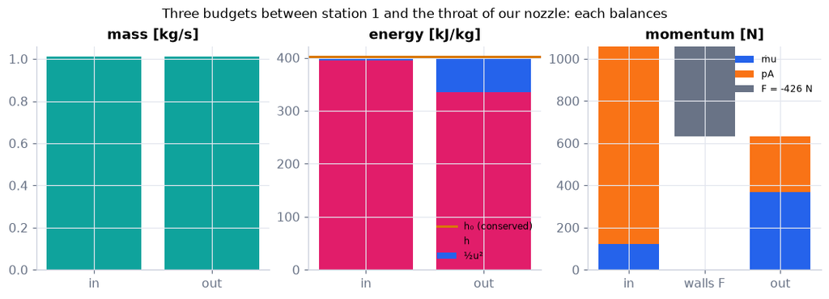

```python
mdot = s1["rho"] * s1["u"] * A1                              # mass flow [kg/s]
F = GD.wall_force(state1, state2, A1, A2)                    # wall force on the fluid [N]
fig, (a, b, c) = plt.subplots(1, 3, figsize=(9.6, 3.4))      # one panel per law
a.bar(["in", "out"], [mdot, s2["rho"] * s2["u"] * A2], color=COLORS["teal"])   # mass flux in and out
a.set(title="mass [kg/s]")                                   # the units are in the title
h = [air.cp * s["T"] / 1e3 for s in states]; k = [0.5 * s["u"]**2 / 1e3 for s in states]   # h and ½u² [kJ/kg]
b.bar(["in", "out"], h, color=COLORS["rose"], label="h")     # enthalpy (rose)
b.bar(["in", "out"], k, bottom=h, color=COLORS["blue"], label="½u²")   # kinetic energy on top (blue)
b.axhline(h[0] + k[0], color=COLORS["amber"], lw=2, label="h₀ (conserved)")   # the total: flat
b.set(title="energy [kJ/kg]"); b.legend(fontsize=8, loc="lower right")
top_in = mdot * s1["u"] + s1["p"] * A1                       # momentum flux plus pressure force at station 1 [N]
c.bar(["in"], [mdot * s1["u"]], color=COLORS["blue"], label="ṁu")                   # momentum flux in
c.bar(["in"], [s1["p"] * A1], bottom=[mdot * s1["u"]], color=COLORS["orange"], label="pA")   # pressure force on face 1
c.bar(["walls F"], [F], bottom=[top_in], color=COLORS["muted"], label=f"F = {F:.0f} N")   # wall force: a step DOWN (waterfall)
c.bar(["out"], [mdot * s2["u"]], color=COLORS["blue"])                              # momentum flux out
c.bar(["out"], [s2["p"] * A2], bottom=[mdot * s2["u"]], color=COLORS["orange"])     # pressure force on face 2
c.set(title="momentum [N]"); c.legend(fontsize=8, loc="upper right")
fig.suptitle("Three budgets between station 1 and the throat of our nozzle: each balances", fontsize=11)
savefig(fig, "ch15", "c03_budgets"); plt.show()              # save and display
```

**What you see.** Bars for station 1 ("in") and the throat ("out"): mass flow; enthalpy (rose) plus kinetic energy (blue) with the conserved total as an amber line; and, on the right, momentum flux (blue) plus pressure force (orange) at each station with the wall force (grey) as a step between them.

**How to read it.** Mass and total enthalpy have equal heights in and out: what enters leaves, and enthalpy is traded for kinetic energy at a fixed total. On the right, read the bars as a waterfall: start at the top of "in", step *down* by the grey wall force (it is negative, −426 N) and you land exactly on the top of "out".

**What would change if…** …you added heat Q? Only the middle pair would change height (the outlet bar rises by Q). Add friction: only the third — and the middle pair still balances.

**What would change if…** …you slowed the gas to rest without heat or friction? The energy line says its temperature would rise to a fixed value $T_0$ — the ruler of the next block.

## 15.4 Reference Properties in Compressible Flow

**What is this section about?** Two imagined states that every point of a flow carries with it: the state it would reach if brought gently to rest (stagnation), and the state it would reach if brought gently to Mach 1 (sonic). All tables and nozzle results are ratios to them.

### 🧩 The stagnation ruler: $\dfrac{T_0}{T}=1+\dfrac{\gamma-1}{2}M^2$ (15.28) `C04`

*The question:* How hot and how compressed would this gas be if you stopped it gently — and which of those two numbers does a real flow keep?

#### The problem in plain words

Hold a thermometer out of an aircraft window at Mach 0.85. It does not read the air's temperature: the air that hits it is brought to rest, its kinetic energy becomes heat, and the reading is about 32 K too high. That higher temperature — and the higher pressure a pitot tube reads — is a property of *each point* of the flow, defined by an imagined experiment. It is the ruler of the chapter: $T_0$ is what an adiabatic flow keeps; $p_0$ is what it loses whenever entropy is made.

#### The idea

```
moving gas (T, p, u)  ──[ stop it: no heat, no friction ]──►  at rest (T₀, p₀, 0)
```

| $T_0$ needs only "no heat" | $p_0$ also needs "no friction" |
| --- | --- |
| kept across friction and shocks | falls whenever entropy rises |

📝 **Note.** **N29 [B]** **Stagnation (total) state:** the state the local gas would reach if brought to rest isentropically; stagnation enthalpy $h_0\equiv h+\tfrac12u^2$ (`GD.total_enthalpy`).

> ⚠️ **Common confusion** (trap T1): this is the third meaning of the subscript 0; most tables write $T_t$, $p_t$.

> 🔁 **Recap — Stagnation temperature `R14`** (Ch. 4 §4.9 (N94)). $C_pT_0=C_pT+\tfrac12u^2$ (15.27): the energy law $h_2+\tfrac12u_2^2-h_1-\tfrac12u_1^2=Q$ (15.22) with Q = 0, between the point and its imagined state of rest.

```python
print(BER.stagnation_temperature(220.0, 250.0, cp=air.cp))   # (15.27): T0 = T + u²/(2 cp) at 220 K, 250 m/s -> 251.1 K (M = 0.841: +31 K)
```

```
251.1045860601687
```

#### 🧮 Derivation — The stagnation ratios `D08` ★ (Eq. 15.28: $\dfrac{T_0}{T}=1+\dfrac{\gamma-1}{2}M^2$)

**What we want to show.** Express the stagnation temperature, pressure and density as multiples of the local values, using the Mach number only.

**Assumptions.** Perfect gas, constant specific heats; adiabatic (steps 1–3); the imagined deceleration is also frictionless, hence isentropic (steps 4–6).

**The plan.**

1. Divide by $C_pT$.
2. Insert $C_p$ and the sound speed.
3. Use the isentropic relations for p and ρ.

**Tools we use** (each explained before this point): the gamma exponents (primer P355) · $C_v=\dfrac{R}{\gamma-1},\ C_p=\dfrac{\gamma R}{\gamma-1}$ (15.1, specific-heat line) · the isentropic relations $\dfrac{p_2}{p_1}=\left(\dfrac{\rho_2}{\rho_1}\right)^{\gamma},\ \dfrac{T_2}{T_1}=\left(\dfrac{\rho_2}{\rho_1}\right)^{\gamma-1}=\left(\dfrac{p_2}{p_1}\right)^{(\gamma-1)/\gamma}$ (15.2) (R05)

**We start from**

$$ C_pT_0=C_pT+\tfrac12u^2\ \text{(15.27)} $$

*In words:* The heat content at rest equals the heat content plus the kinetic energy in motion

**Step 1 of 6 — Divide by $C_pT$.**

$$ \dfrac{T_0}{T}=1+\dfrac{u^2}{2C_pT} $$

- *Why we can do this:* $C_pT\neq0$. We want a ratio. Dividing both sides of an equation by the same non-zero number keeps it true.
- *In words:* The stagnation temperature exceeds the local one by the kinetic energy measured in units of the enthalpy.

**Step 2 of 6 — Insert the specific heat.**

$$ \dfrac{T_0}{T}=1+\dfrac{\gamma-1}{2}\dfrac{u^2}{\gamma RT} $$

- *Why we can do this:* $C_p=\gamma R/(\gamma-1)$ for a perfect gas. It produces the combination γRT.
- *In words:* The same, with γ and R.

**Step 3 of 6 — Recognise the Mach number.**

$$ \dfrac{T_0}{T}=1+\dfrac{\gamma-1}{2}M^2\ \text{(15.28)} $$

- *Why we can do this:* $c^2=\gamma RT$ with the *local* temperature, and $M=u/c$.
- *In words:* The temperature ratio depends on the local Mach number alone.

**Step 4 of 6 — Use the isentropic pressure–temperature relation.**

$$ \dfrac{p_0}{p}=\left(\dfrac{T_0}{T}\right)^{\gamma/(\gamma-1)} $$

- *Why we can do this:* The stagnation state is *defined* by an isentropic deceleration, so $\dfrac{p_2}{p_1}=\left(\dfrac{\rho_2}{\rho_1}\right)^{\gamma},\ \dfrac{T_2}{T_1}=\left(\dfrac{\rho_2}{\rho_1}\right)^{\gamma-1}=\left(\dfrac{p_2}{p_1}\right)^{(\gamma-1)/\gamma}$ (15.2) links the two states.
- *In words:* Pressure rises with the 3.5th power of the temperature ratio (γ = 1.4).

**Step 5 of 6 — Insert step 3.**

$$ \dfrac{p_0}{p}=\left[1+\dfrac{\gamma-1}{2}M^2\right]^{\gamma/(\gamma-1)}\ \text{(15.29)} $$

- *Why we can do this:* Substitution. We put the temperature ratio of step 3 into step 4, so that the pressure ratio depends on M alone.
- *In words:* The stagnation pressure ratio, in terms of M.

**Step 6 of 6 — The same for the density.**

$$ \dfrac{\rho_0}{\rho}=\left[1+\dfrac{\gamma-1}{2}M^2\right]^{1/(\gamma-1)}\ \text{(15.30)} $$

- *Why we can do this:* From $\dfrac{p_2}{p_1}=\left(\dfrac{\rho_2}{\rho_1}\right)^{\gamma},\ \dfrac{T_2}{T_1}=\left(\dfrac{\rho_2}{\rho_1}\right)^{\gamma-1}=\left(\dfrac{p_2}{p_1}\right)^{(\gamma-1)/\gamma}$ (15.2), $\rho_0/\rho=(T_0/T)^{1/(\gamma-1)}$; insert step 3.
- *In words:* The density rises with the 2.5th power (γ = 1.4).

**Result**

$$ \begin{array}{l}\dfrac{T_0}{T}=1+\dfrac{\gamma-1}{2}M^2\ \text{(15.28),}\ \dfrac{p_0}{p}=\left[1+\dfrac{\gamma-1}{2}M^2\right]^{\gamma/(\gamma-1)}\ \text{(15.29),} \\ \dfrac{\rho_0}{\rho}=\left[1+\dfrac{\gamma-1}{2}M^2\right]^{1/(\gamma-1)}\ \text{(15.30).}\end{array} $$

**What it means.** Every point of a flow carries a $T_0$ and a $p_0$; the first is kept by any adiabatic flow, the second only by an isentropic one (D09). **Fails when:** γ varies (very high temperature), or the gas is not perfect.

**Check it.** Units — pure numbers ✓. Limits — M = 0: all ratios 1; small M: $p_0-p\approx\tfrac12\gamma pM^2=\tfrac12\rho u^2$ (the pitot formula). Consistency — $p_0/p=(\rho_0/\rho)(T_0/T)$: exponents 1/(γ − 1) + 1 = γ/(γ − 1) ✓. Number — M = 2: 1.8, 7.82, 4.35.

📝 **Notes taught inside `D08`:** **N30 [B]** $\dfrac{p_0}{p}=\left[1+\dfrac{\gamma-1}{2}M^2\right]^{\gamma/(\gamma-1)}$ (15.29) (steps 4–5) · **N31 [B]** $\dfrac{\rho_0}{\rho}=\left[1+\dfrac{\gamma-1}{2}M^2\right]^{1/(\gamma-1)}$ (15.30) (step 6). The exponents 3.5 and 2.5 are the gamma exponents of primer P355 (§15.1).

> ⚠️ **Common confusion (traps in `D08`):** $T_0/T$ needs only "adiabatic", the other two also need "frictionless"; the Mach number uses the local c; the exponents are γ/(γ − 1) and 1/(γ − 1), not their inverses.

#### ✏️ Tiny example: Mach 2 by hand

γ = 1.4, M = 2.

1. $\dfrac{T_0}{T}=1+\dfrac{\gamma-1}{2}M^2$ (15.28): $T_0/T$ = 1 + 0.2 × 4 = **1.8**.
2. $\dfrac{p_0}{p}=\left[1+\dfrac{\gamma-1}{2}M^2\right]^{\gamma/(\gamma-1)}$ (15.29): $p_0/p$ = 1.8^3.5 = 1.8³ × √1.8 = 5.832 × 1.342 = **7.82**.
3. $\dfrac{\rho_0}{\rho}=\left[1+\dfrac{\gamma-1}{2}M^2\right]^{1/(\gamma-1)}$ (15.30): $\rho_0/\rho$ = 1.8^2.5 = 1.8² × √1.8 = 3.24 × 1.342 = **4.35**.
4. Check with the gas law: 7.82/4.35 = 1.80 ✓. A Mach-2 stream at 288 K would heat to 519 K if stopped.

```python
print(GD.stagnation_temperature_ratio(2.0), GD.stagnation_pressure_ratio(2.0), GD.stagnation_density_ratio(2.0))   # 1.8, 7.8244, 4.3469
print(GD.isentropic_state(2.0))                              # all the ratios at M = 2; p/p0 = 0.1278 (NACA Report 1135 row M = 2)
print(GD.mach_from_pressure_ratio(1 / 7.8244))               # the inverse of (15.29): back to M = 2.000
```

```
1.7999999999999998 7.824449066867263 4.3469161482595915
{'M': 2.0, 'T_over_T0': 0.5555555555555556, 'p_over_p0': 0.12780452546295096, 'rho_over_rho0': 0.2300481458333117, 'A_over_Astar': 1.6875000000000002, 'T0_over_T': 1.7999999999999998, 'p0_over_p': 7.824449066867263, 'rho0_over_rho': 4.3469161482595915}
1.9999959686505382
```

**What does the code above do?**

1. The three functions are $\dfrac{T_0}{T}=1+\dfrac{\gamma-1}{2}M^2$ (15.28)–$\dfrac{\rho_0}{\rho}=\left[1+\dfrac{\gamma-1}{2}M^2\right]^{1/(\gamma-1)}$ (15.30): 1.8, 7.8244, 4.3469.
2. `GD.isentropic_state(M)` returns all ratios at once, both ways round (`p_over_p0` = 0.1278 and `p0_over_p` = 7.82); its values are checked in the tests against the public NACA Report 1135 table.
3. `GD.mach_from_pressure_ratio` inverts $\dfrac{p_0}{p}=\left[1+\dfrac{\gamma-1}{2}M^2\right]^{\gamma/(\gamma-1)}$ (15.29): what a pitot-static pair measures, turned into a Mach number.

```python
g = 1.4                                                      # gamma of air
M = np.linspace(0.0, 5.0, 51)                                # Mach numbers 0 … 5
t = 1 + 0.5 * (g - 1) * M**2                                 # (15.28): T0/T
mine = dict(T_over_T0=1 / t, p_over_p0=t**(-g / (g - 1)), rho_over_rho0=t**(-1 / (g - 1)))   # (15.28)-(15.30) inverted
lib = GD.isentropic_state(M, g)                              # the tested function (arrays in, arrays out)
assert all(np.allclose(mine[k], lib[k]) for k in mine)       # same numbers for every Mach number
print("from scratch = GD.isentropic_state at 51 Mach numbers")
```

```
from scratch = GD.isentropic_state at 51 Mach numbers
```

**From scratch.** One line per ratio, written from $\dfrac{T_0}{T}=1+\dfrac{\gamma-1}{2}M^2$ (15.28)–$\dfrac{\rho_0}{\rho}=\left[1+\dfrac{\gamma-1}{2}M^2\right]^{1/(\gamma-1)}$ (15.30); they agree with `GD.isentropic_state` everywhere.

> 📎 **Primer — dynamic pressure in a gas.** `P359` · $\tfrac12\rho U^2=\tfrac12\gamma pM^2$, because $c^2=\gamma p/\rho$ gives $\rho U^2=\rho c^2M^2=\gamma pM^2$. It lets us trade a speed for a Mach number in any momentum term.

```python
g, p, M = 1.4, 101325.0, 0.3                  # air at sea level, Mach 0.3
rho, c = 1.225, 340.3                         # density, sound speed
print(0.5*rho*(M*c)**2, 0.5*g*p*M**2)         # 6384 Pa both ways
```

```
6383.700461250001 6383.474999999999
```

> 🔁 **Tools from earlier chapters used in this block** (one line each; the full primers are in the chapters named)
- **binomial approximation** — (1 + x)^n ≈ 1 + nx + ½n(n − 1)x² for small x; here it expands the stagnation pressure ratio for a slow flow and recovers the incompressible pitot formula. *(Ch. 14, P342)*

📝 **Note.** **N32 [B]** For small M, $p_0=p+\tfrac12\rho u^2\left(1+\tfrac14M^2+\dots\right)$ (ours) and $\rho_0/\rho=1+\tfrac12M^2+\dots$ (ours; result given, not derived): the incompressible pitot formula of Ch. 4 is the first term.

```python
g_, M_ = sp.symbols("gamma M", positive=True)                # symbols
print(sp.series((1 + (sp.Rational(7, 5) - 1) / 2 * M_**2)**sp.Rational(7, 2), M_, 0, 6))   # p0/p for gamma = 7/5: 1 + 7M²/10 + 7M⁴/40 + …
print(GD.pitot_compressibility_factor(0.3))                  # (p0 - p)/(½ rho u²) at M = 0.3 -> 1.0227: the incompressible formula reads 2.3 % low
print(GD.mach_for_density_change(0.05))                      # the Mach number at which rho0/rho - 1 = 5 % -> 0.314
```

```
1 + 7*M**2/10 + 7*M**4/40 + O(M**6)
1.0227029548085418
0.31390881649759333
```

**What does the code above do?**

1. sympy's `series` expands $\dfrac{p_0}{p}=\left[1+\dfrac{\gamma-1}{2}M^2\right]^{\gamma/(\gamma-1)}$ (15.29) for γ = 7/5: $1+\tfrac{7}{10}M^2+\tfrac{7}{40}M^4+\dots$; the first correction is $\tfrac12\gamma M^2\cdot p=\tfrac12\rho u^2$ (primer P359), the second is ¼M² of that — the pitot factor.
2. At M = 0.3 the compressible pitot pressure is 2.3 % above the incompressible one.
3. Density differs from its stagnation value by 5 % at M = 0.314 — the origin of the rule of thumb "incompressible below M ≈ 0.3".

```python
M = np.linspace(0.0, 2.0, 150)                               # Mach numbers
gammas = [1.1, 1.15, 1.2, 1.25, 1.3, 1.35, 1.4, 1.45, 1.5, 1.55, 1.6, 5 / 3]                         # gamma from 1.1 to 5/3
fig = slider_figure(lambda g: {"p0/p, (15.29)": (M, GD.stagnation_pressure_ratio(M, g)),     # the exact ratio
                               "incompressible 1 + ½γM²": (M, 1 + 0.5 * g * M**2),           # Bernoulli's ghost
                               "M = 0.3": ([0.3, 0.3], [1.0, 12.0])},                         # where they part
                    "γ", gammas, xlabel="Mach number M [–]", ylabel="p₀/p (stagnation / static) [–]",
                    title="Below M ≈ 0.3 the compressible and incompressible stagnation pressures agree", yrange=[1, 12],
                    active=gammas.index(1.4))                # open on air, gamma = 1.4
fig.show()                                                   # every slider position computed now
```

[interactive chart not shown]

**Figure F2.** The slider is γ, from 1.1 to 5/3 in 12 positions; the two curves are $\dfrac{p_0}{p}=\left[1+\dfrac{\gamma-1}{2}M^2\right]^{\gamma/(\gamma-1)}$ (15.29) and its incompressible first term.

**What you see.** The stagnation-to-static pressure ratio against Mach number (purple) and the incompressible estimate $1+\tfrac12\gamma M^2$ (teal), with a dashed line at M = 0.3.

**How to read it.** Left of the dashed line the two curves are one: Bernoulli's equation is fine there. At M = 1 the exact ratio is 1.89 against 1.70; at M = 2 it is 7.8 against 3.8. Drag γ: a stiffer gas (larger γ) gains pressure faster.

**What would change if…** …the gas were monatomic (γ = 5/3)? The pressure exponent γ/(γ − 1) drops from 3.5 to 2.5, yet the curve rises faster at small M because the first term is ½γM².

> 🔁 **Recap — Entropy is a state function** (Ch. 1 C33–C35). S depends only on the state, so $S_2-S_1=C_p\ln\dfrac{T_2}{T_1}-R\ln\dfrac{p_2}{p_1}=C_v\ln\dfrac{T_2}{T_1}-R\ln\dfrac{\rho_2}{\rho_1}$ (15.1, entropy line) holds between *any* two states, however the gas got from one to the other; the logarithm rules ln(ab) = ln a + ln b and n ln a = ln aⁿ do the rest.

#### 🧮 Derivation — $T_0$ is kept, $p_0$ is lost `D09` ★ (Eq. unnumbered, §15.4: $S_2-S_1=-R\ln\dfrac{p_{02}}{p_{01}}+C_p\ln\dfrac{T_{02}}{T_{01}}$)

**What we want to show.** Show that when entropy rises in an adiabatic flow, the stagnation pressure must fall.

**Assumptions.** Perfect gas; adiabatic between stations 1 and 2 (step 4).

**The plan.**

1. Move from the two flow states to their stagnation states.
2. Apply the entropy formula there.
3. Use $T_{02}=T_{01}$.

**Tools we use** (each explained before this point): entropy is a state function (Ch. 1 recap) · logarithm rules

**We start from**

$$ S_2-S_1=C_p\ln\dfrac{T_2}{T_1}-R\ln\dfrac{p_2}{p_1}=C_v\ln\dfrac{T_2}{T_1}-R\ln\dfrac{\rho_2}{\rho_1}\ \text{(15.1, entropy line)} $$

*In words:* The entropy difference between any two states of a perfect gas

**Step 1 of 5 — Compare each state with its own stagnation state.**

$$ S_{01}=S_1,\qquad S_{02}=S_2 $$

- *Why we can do this:* The stagnation state is reached, in imagination, by an isentropic process — entropy unchanged by definition.
- *In words:* A point and its stagnation state have the same entropy.

**Step 2 of 5 — Subtract.**

$$ S_2-S_1=S_{02}-S_{01} $$

- *Why we can do this:* Step 1, twice. Subtracting two true equations side by side gives a true equation; it moves the problem to the stagnation states.
- *In words:* The entropy change of the flow equals the entropy change between the two stagnation states.

**Step 3 of 5 — Apply the entropy formula between the stagnation states.**

$$ S_2-S_1=-R\ln\dfrac{p_{02}}{p_{01}}+C_p\ln\dfrac{T_{02}}{T_{01}}\ \text{(unnumbered, §15.4)} $$

- *Why we can do this:* $S_2-S_1=C_p\ln\dfrac{T_2}{T_1}-R\ln\dfrac{p_2}{p_1}=C_v\ln\dfrac{T_2}{T_1}-R\ln\dfrac{\rho_2}{\rho_1}$ holds between *any* two states because S is a state function; choose states 01 and 02.
- *In words:* Entropy change in terms of stagnation quantities.

**Step 4 of 5 — Use the energy law.**

$$ S_2-S_1=-R\ln\dfrac{p_{02}}{p_{01}} $$

- *Why we can do this:* Adiabatic flow: $h_2+\tfrac12u_2^2-h_1-\tfrac12u_1^2=Q$ (15.22) with Q = 0 gives $h_{02}=h_{01}$, so $T_{02}=T_{01}$ and $\ln1=0$ — whether or not there is friction.
- *In words:* With no heat added, all the entropy change shows up in the stagnation pressure.

**Step 5 of 5 — Solve for the pressure ratio.**

$$ \dfrac{p_{02}}{p_{01}}=e^{-(S_2-S_1)/R}<1\ \text{ when }\ S_2>S_1 $$

- *Why we can do this:* Exponentiate; the second law says entropy cannot fall in an adiabatic flow.
- *In words:* Every bit of entropy made costs stagnation pressure.

**Result**

$$ S_2-S_1=-R\ln\dfrac{p_{02}}{p_{01}}+C_p\ln\dfrac{T_{02}}{T_{01}}\ \text{(unnumbered, §15.4), hence}\ T_{02}=T_{01}\ \text{and}\ S_2>S_1\ \text{give}\ p_{02}<p_{01}\ \text{.} $$

**What it means.** $p_0$ is the flow's "ability to do work"; friction and shocks spend it without changing the energy. **Fails when:** heat is exchanged ($T_0$ changes, C12).

**Check it.** Units — S/R is a number ✓. Limit — isentropic: $p_{02}=p_{01}$. Number — a 10 % loss of $p_0$: ΔS = −287 ln 0.9 = 30.2 J/(kg K).

📝 **Notes taught inside `D09`:** **N33 [B]** $S_2-S_1=-R\ln\dfrac{p_{02}}{p_{01}}+C_p\ln\dfrac{T_{02}}{T_{01}}$ (unnumbered, §15.4)

> ⚠️ **Common confusion (traps in `D09`):** Adiabatic is not isentropic (trap T17); $p_0$ can fall with $T_0$ unchanged; the formula is between stagnation states, not static ones.

> ⚠️ **Common confusion:** (trap T17) Adiabatic is not isentropic — $T_0$ is kept, $p_0$ is not.

```python
dS = GD.entropy_change_from_stagnation(0.9, gas=air)          # (unnumbered, §15.4): a 10 % loss of p0 at fixed T0 -> 30.2 J/(kg K)
print(dS, GD.stagnation_pressure_loss(dS, gas=air))          # ... and back: p02/p01 = exp(-dS/R) = 0.900
```

```
30.243736019579035 0.9
```

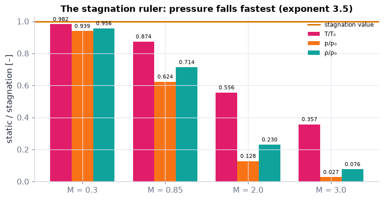

```python
Ms = [0.3, 0.85, 2.0, 3.0]                                   # four Mach numbers
st = [GD.isentropic_state(M) for M in Ms]                    # their ratios to the stagnation state
xpos = np.arange(len(Ms))                                    # bar groups
fig, ax = plt.subplots(figsize=(7.0, 3.6))                   # one panel
w = 0.26                                                     # bar width
ax.bar(xpos - w, [s["T_over_T0"] for s in st], w, color=COLORS["rose"], label="T/T₀")       # temperature (rose)
ax.bar(xpos, [s["p_over_p0"] for s in st], w, color=COLORS["orange"], label="p/p₀")          # pressure (orange)
ax.bar(xpos + w, [s["rho_over_rho0"] for s in st], w, color=COLORS["teal"], label="ρ/ρ₀")    # density (teal)
ax.axhline(1.0, color=COLORS["amber"], lw=2, label="stagnation value")                         # the ruler
ax.set_xticks(xpos, [f"M = {M}" for M in Ms])               # group labels
ax.set(ylabel="static / stagnation [–]", title="The stagnation ruler: pressure falls fastest (exponent 3.5)")
ax.legend(fontsize=8)                                        # legend
for i, s in enumerate(st):                                   # print the numbers on top
    for dx, k in ((-w, "T_over_T0"), (0, "p_over_p0"), (w, "rho_over_rho0")):
        ax.text(i + dx, s[k] + 0.02, f"{s[k]:.3f}", ha="center", fontsize=7)
savefig(fig, "ch15", "c04_ruler"); plt.show()                # save and display
```

**What you see.** For four Mach numbers, the static temperature, pressure and density as fractions of their stagnation values, with the stagnation value as an amber line at 1.

**How to read it.** At M = 0.3 everything is within about 6 % of the stagnation value (the pressure, the farthest, is at 0.939). At M = 2 the pressure is 13 % of it, the density 23 % and the temperature 56 %; at M = 3 the pressure is under 3 %. **The pressure always falls fastest**: its exponent γ/(γ − 1) = 3.5 is the largest.

**What would change if…** …γ were 5/3? The exponents would be 2.5 and 1.5, so pressure and density would fall more slowly for the same temperature drop — but the temperature drop itself is larger, $\tfrac13M^2$ instead of $\tfrac15M^2$.

📝 **Note.** **N34 [C]** A large reservoir at rest holds the stagnation values of everything that flows out of it isentropically; it is the left end of the nozzle figures of C06, C09 and C10.

📝 **Note.** **N38 [C]** Let $T\to0$ in $\dfrac{T_0}{T}=1+\dfrac{\gamma-1}{2}M^2$ (15.28): the speed tends to $u_{\max}=\sqrt{2C_pT_0}$ (ours) — `GD.max_speed(288.15, air.cp)` = 761 m/s for a reservoir at room temperature; the same limit caps the Prandtl–Meyer turn in C15.

```python
print(GD.max_speed(288.15, air.cp))                          # sqrt(2 cp T0): all the enthalpy turned into speed -> 761 m/s
```

```
760.9166856496183
```

**What would change if…** …instead of stopping the gas you brought it to exactly Mach 1? You get a second reference state — and with it the area a flow needs. C05.

### 🧩 One area, two Mach numbers: $\dfrac{A}{A^*}=\dfrac1M\left[\dfrac{2}{\gamma+1}\left(1+\dfrac{\gamma-1}{2}M^2\right)\right]^{(1/2)(\gamma+1)/(\gamma-1)}$ (15.31) `C05`

*The question:* How much room does a given flow need at each Mach number — and why is there a least amount?

#### The problem in plain words

Push a fixed number of kilograms per second down a duct. Where the gas is slow it needs a wide passage. Speed it up and it needs less — until Mach 1. Beyond that the gas thins out so quickly that it needs *more* room again. So the required area has a minimum, exactly at Mach 1: that minimum is the throat, and a throat of given size can pass only so much.

#### The idea

```
A/A* │\                 /
     │ \               /
     │  \             /
   1 ┼───\___________/────
     └──────── M = 1 ─────── M
       one height → two Mach numbers (subsonic, supersonic)
```

> 🔁 **Tools from earlier chapters used in this block** (one line each; the full primers are in the chapters named)
- **`scipy.optimize.brentq`** — `brentq(f, a, b)` finds the root of f inside a bracket [a, b] where f changes sign; here the bracket also chooses which of two Mach numbers you get. *(Ch. 3, P108)*

📝 **Note.** **N35 [B]** **Sonic (critical) state** — not in the book as formulas, ours: put M = 1 in $\dfrac{T_0}{T}=1+\dfrac{\gamma-1}{2}M^2$ (15.28), $\dfrac{p_0}{p}=\left[1+\dfrac{\gamma-1}{2}M^2\right]^{\gamma/(\gamma-1)}$ (15.29), $\dfrac{\rho_0}{\rho}=\left[1+\dfrac{\gamma-1}{2}M^2\right]^{1/(\gamma-1)}$ (15.30): $\dfrac{T^*}{T_0}=\dfrac{2}{\gamma+1},\ \dfrac{p^*}{p_0}=\left(\dfrac{2}{\gamma+1}\right)^{\gamma/(\gamma-1)},\ \dfrac{\rho^*}{\rho_0}=\left(\dfrac{2}{\gamma+1}\right)^{1/(\gamma-1)}$ (ours, from (15.28)–(15.30) at $M=1$). For γ = 1.4: 0.833, 0.528, 0.634.

> ⚠️ **Common confusion** (trap T2): the star now means "if brought to M = 1 isentropically".

```python
print(GD.sonic_ratios())                                     # T*/T0, p*/p0, rho*/rho0, c*/c0 for gamma = 1.4 -> 0.833, 0.528, 0.634, 0.913
print(GD.critical_pressure_ratio())                          # p*/p0 = 0.5283: the number behind choking (C09)
```

```
{'T': 0.8333333333333334, 'p': 0.5282817877171742, 'rho': 0.633938145260609, 'c': 0.9128709291752769}
0.5282817877171742
```

#### 🧮 Derivation — The area ratio `D10` ★★ (Eq. 15.31: $\dfrac{A}{A^*}=\dfrac1M\left[\dfrac{2}{\gamma+1}\left(1+\dfrac{\gamma-1}{2}M^2\right)\right]^{(1/2)(\gamma+1)/(\gamma-1)}$)

**What we want to show.** Find how much area a given flow needs at Mach number M, compared with the area it would need at Mach 1.

**Assumptions.** Isentropic between the station and the imagined sonic station (so $T_0$, $\rho_0$ are common to both).

**The plan.**

1. Write the area ratio as a chain of ratios.
2. Evaluate each from D08 at M and at 1.
3. Collect the exponents.
4. Find the minimum.

**Tools we use** (each explained before this point): a chain of ratios · the gamma exponents (primer P355) · D08 · a minimum by a zero derivative

**We start from**

$$ \rho uA=\rho^*c^*A^*\qquad\text{(mass, }\rho uA=\dot m=\text{const. (15.18), between a station and the sonic station)} $$

*In words:* Mass conservation written between the station of Mach number M and the imagined sonic station, where the speed equals the sonic speed c*.

**Step 1 of 9 — Solve for the area ratio.**

$$ \dfrac{A}{A^*}=\dfrac{\rho^*}{\rho}\,\dfrac{c^*}{u} $$

- *Why we can do this:* Divide the mass balance by $\rho uA^*$.
- *In words:* More area is needed where the mass flux ρu is smaller.

**Step 2 of 9 — Insert the stagnation density and the Mach number.**

$$ \dfrac{A}{A^*}=\dfrac{\rho^*}{\rho_0}\,\dfrac{\rho_0}{\rho}\,\dfrac{c^*}{c}\,\dfrac1M $$

- *Why we can do this:* Multiply and divide by $\rho_0$ and by c; $u=Mc$. Each factor is now a ratio D08 gives.
- *In words:* Four ratios, each depending on one Mach number.

**Step 3 of 9 — Write the sound-speed ratio with temperatures.**

$$ \dfrac{c^*}{c}=\sqrt{\dfrac{T^*}{T}}=\sqrt{\dfrac{T^*}{T_0}\,\dfrac{T_0}{T}} $$

- *Why we can do this:* $c=\sqrt{\gamma RT}$; multiply and divide by $T_0$, which is the same at both stations.
- *In words:* Sound speed goes as the square root of temperature.

**Step 4 of 9 — Evaluate at the station (Mach number M).**

$$ \dfrac{T_0}{T}=\Theta,\quad\dfrac{\rho_0}{\rho}=\Theta^{1/(\gamma-1)},\qquad\Theta\equiv1+\dfrac{\gamma-1}{2}M^2 $$

- *Why we can do this:* $\dfrac{T_0}{T}=1+\dfrac{\gamma-1}{2}M^2$ (15.28) and $\dfrac{\rho_0}{\rho}=\left[1+\dfrac{\gamma-1}{2}M^2\right]^{1/(\gamma-1)}$ (15.30). Θ is a shorthand we keep for the rest of the chapter.
- *In words:* The local stagnation ratios.

**Step 5 of 9 — Evaluate at the sonic station (M = 1).**

$$ \dfrac{T^*}{T_0}=\dfrac{2}{\gamma+1},\qquad\dfrac{\rho^*}{\rho_0}=\left(\dfrac{2}{\gamma+1}\right)^{1/(\gamma-1)} $$

- *Why we can do this:* The same two equations with M = 1: Θ = (γ + 1)/2.
- *In words:* The sonic state as fractions of the stagnation state (0.833 and 0.634 for air).

**Step 6 of 9 — Assemble.**

$$ \dfrac{A}{A^*}=\dfrac1M\left(\dfrac{2}{\gamma+1}\right)^{\frac1{\gamma-1}}\Theta^{\frac1{\gamma-1}}\left(\dfrac{2}{\gamma+1}\right)^{\frac12}\Theta^{\frac12} $$

- *Why we can do this:* Substitute steps 3–5 into step 2.
- *In words:* Everything in terms of M and γ.

**Step 7 of 9 — Add the exponents.**

$$ \dfrac1{\gamma-1}+\dfrac12=\dfrac{\gamma+1}{2(\gamma-1)} $$

- *Why we can do this:* Powers of the same base multiply by adding exponents; common denominator 2(γ − 1).
- *In words:* One combined exponent — 3 for air.

**Step 8 of 9 — Write the result.**

$$ \dfrac{A}{A^*}=\dfrac1M\left[\dfrac{2}{\gamma+1}\left(1+\dfrac{\gamma-1}{2}M^2\right)\right]^{(1/2)(\gamma+1)/(\gamma-1)}\ \text{(15.31)} $$

- *Why we can do this:* Both $\frac{2}{\gamma+1}$ and Θ carry the exponent of step 7.
- *In words:* The area ratio as a function of Mach number.

**Step 9 of 9 — Find where it is smallest.**

$$ \dfrac{d}{dM}\ln\dfrac{A}{A^*}=\dfrac{M^2-1}{M\,\Theta} $$

- *Why we can do this:* Logarithmic derivative: $-\dfrac1M+\dfrac{\gamma+1}{2}\dfrac{M}{\Theta}$, on a common denominator. It is negative for M < 1, zero at 1, positive above.
- *In words:* The area ratio falls to exactly 1 at Mach 1 and rises on both sides.

**Result**

$$ \dfrac{A}{A^*}=\dfrac1M\left[\dfrac{2}{\gamma+1}\left(1+\dfrac{\gamma-1}{2}M^2\right)\right]^{(1/2)(\gamma+1)/(\gamma-1)}\ \text{(15.31)} $$

*In words:* a U-shaped curve with its minimum, 1, at M = 1

**What it means.** Each area ratio above 1 belongs to two Mach numbers, one subsonic and one supersonic; which occurs is decided downstream. A given throat passes a given mass flow at most. **Fails when:** entropy changes between the station and the throat (a shock, friction): then $A^*$ itself changes.

**Check it.** Units — a pure number ✓. Limits — M = 1: 1; M → 0: $A/A^*\to\infty$ like 1/M (a reservoir); M → ∞: grows like $M^{2/(\gamma-1)}$. Number — M = 2: (1/2)(1.5)³ = 1.6875; M = 0.5: 2 × 0.875³ = 1.340. Code — `GD.area_ratio`.

> ⚠️ **Common confusion (traps in `D10`):** $c^*/c$ is a square root; the star is the sonic state here (trap T2); two inverses (trap T8).

#### ✏️ Tiny example: Mach 2 and Mach 0.5 by hand

γ = 1.4, exponent ½(γ+1)/(γ−1) = 3.

1. M = 2: bracket = (2/2.4) × 1.8 = 1.5; 1.5³ = 3.375; ÷ M: **1.6875**.
2. M = 0.5: bracket = (1/1.2) × 1.05 = 0.875; 0.875³ = 0.670; ÷ 0.5: **1.340**.
3. M = 1: bracket = 1: **1**. Both sides of Mach 1 need more area than the throat.

> 📎 **Primer — a function with two inverses.** `P360` · A U-shaped function has two x for each y above its minimum. A root-finder needs to be told which: give it a bracket on one side of the minimum. Here the physics chooses the side.

```python
from scipy.optimize import brentq                 # bracketed root finder (reminder: P108)
A = lambda M: (1/M)*((2/2.4)*(1 + 0.2*M*M))**3    # A/A* for gamma = 1.4
print(brentq(lambda M: A(M) - 2.0, 1e-8, 1.0))    # 0.306 (subsonic side)
print(brentq(lambda M: A(M) - 2.0, 1.0, 100.0))   # 2.197 (supersonic side)
```

```
0.30590383418910816
2.1971981216521863
```

📝 **Note.** **N36 [B]** (ours) The inverse of $\dfrac{A}{A^*}=\dfrac1M\left[\dfrac{2}{\gamma+1}\left(1+\dfrac{\gamma-1}{2}M^2\right)\right]^{(1/2)(\gamma+1)/(\gamma-1)}$ (15.31): `GD.mach_from_area_ratio(2.0, branch="subsonic")` = 0.306, `branch="supersonic"` = 2.197.

> ⚠️ **Common confusion** (trap T8, first half): one area ratio, two Mach numbers — which one occurs is decided downstream, by the back pressure (C09–C10).

```python
print(GD.area_ratio(np.array([0.5, 1.0, 2.0, 3.0])))         # (15.31): 1.3398, 1, 1.6875, 4.2346
for AR in (1.5, 2.0):                                        # two area ratios
    print(AR, GD.mach_from_area_ratio(AR, branch="subsonic"), GD.mach_from_area_ratio(AR, branch="supersonic"))   # (0.4303, 1.8541), (0.3059, 2.1972)
```

```
[1.3398 1.     1.6875 4.2346]
1.5 0.4302617321181023 1.8541235267373257
2.0 0.3059038341891081 2.1971981216521863
```

**What does the code above do?**

1. `GD.area_ratio` evaluates $\dfrac{A}{A^*}=\dfrac1M\left[\dfrac{2}{\gamma+1}\left(1+\dfrac{\gamma-1}{2}M^2\right)\right]^{(1/2)(\gamma+1)/(\gamma-1)}$ (15.31): the worked numbers 1.340 and 1.6875, the minimum 1 at M = 1, and 4.23 at M = 3.
2. `GD.mach_from_area_ratio` inverts it on the side you name with `branch=` — we always name it.

```python
g, M = 1.4, np.array([0.3, 0.5, 2.0, 3.0])                    # gamma; four Mach numbers
Theta = 1 + 0.5 * (g - 1) * M**2                              # D10 step 4: T0/T
rho_star_over_rho0 = (2 / (g + 1))**(1 / (g - 1))             # D10 step 5
rho0_over_rho = Theta**(1 / (g - 1))                          # (15.30)
T_star_over_T = (2 / (g + 1)) * Theta                         # D10 step 3: T*/T0 × T0/T
A_mine = rho_star_over_rho0 * rho0_over_rho * np.sqrt(T_star_over_T) / M   # D10 step 2: a product of four ratios
assert np.allclose(A_mine, GD.area_ratio(M))                  # same as the library

def bisect(f, a, b, n=80):                                    # a ten-line bisection: halve [a, b] n times
    for _ in range(n):                                        # each pass halves the bracket
        m = 0.5 * (a + b)                                     # midpoint
        if f(a) * f(m) <= 0: b = m                            # root in the left half
        else: a = m                                           # root in the right half
    return 0.5 * (a + b)                                      # the midpoint of the last bracket
F = lambda M: GD.area_ratio(M) - 2.0                          # A/A* - 2
M_sub, M_sup = bisect(F, 1e-6, 1.0), bisect(F, 1.0, 50.0)     # one root on each side of the minimum
assert np.allclose([M_sub, M_sup], [GD.mach_from_area_ratio(2.0, branch="subsonic"),
                                    GD.mach_from_area_ratio(2.0, branch="supersonic")], atol=1e-9)
print(A_mine, M_sub, M_sup)                                   # 2.035 1.340 1.6875 4.235 | 0.3059 2.1972
```

```
[2.0351 1.3398 1.6875 4.2346] 0.30590383418910805 2.1971981216521863
```

**From scratch.** The area ratio is assembled exactly as D10 does it — four ratios multiplied — and inverted by plain bisection on each side of Mach 1. Both agree with the library.

> 📎 **Primer — a generated table as a pandas DataFrame.** `P361` · The classical tool is a printed table of ratios against Mach number. We generate ours: a DataFrame is a table with named columns; `.loc` picks rows; reading it "backwards" means finding the row whose column is closest to a value.

```python
tab = GD.isentropic_table(np.arange(0.5, 3.01, 0.5))     # our own table, gamma = 1.4
print(tab.round(4))                                      # columns 'M', 'p/p0', 'rho/rho0', 'T/T0', 'A/A*'
print(tab.loc[(tab['A/A*'] - 1.69).abs().idxmin(), 'M']) # read backwards: nearest row to A/A* = 1.69
```

```
     M    p/p0  rho/rho0    T/T0    A/A*
0  0.5  0.8430    0.8852  0.9524  1.3398
1  1.0  0.5283    0.6339  0.8333  1.0000
2  1.5  0.2724    0.3950  0.6897  1.1762
3  2.0  0.1278    0.2300  0.5556  1.6875
4  2.5  0.0585    0.1317  0.4444  2.6367
5  3.0  0.0272    0.0762  0.3571  4.2346
2.0
```

📝 **Note.** **N37 [B]** The book's table is not reproduced; ours is generated for γ = 1.4 and 5/3 and checked against three rows of the public-domain NACA Report 1135 (M = 0.5, 2, 3). (Slip #9 concerns two misprinted entries of the book's table; a generated table cannot have them.) Note the last line of the demo: reading backwards returns only the nearest row — and only one of the two branches.

#### 🧮 Derivation — The sonic ratios and the choked mass flow `D11` ★★ (Eq. ours: $\dot m_{\max}=p_0A^*\sqrt{\dfrac{\gamma}{RT_0}}\left(\dfrac{2}{\gamma+1}\right)^{(\gamma+1)/(2(\gamma-1))}$)

**What we want to show.** Find the pressure, temperature and density at a sonic throat, and the mass flow such a throat passes.

**Assumptions.** Isentropic from the reservoir to the throat; perfect gas.

**The plan.**

1. Set M = 1 in the three ratios.
2. Write $\dot m=\rho^*c^*A^*$.
3. Express it with the reservoir values.
4. See that it is a maximum.

**Tools we use** (each explained before this point): substitution · $p=\rho RT$ · D10 step 9

**We start from**

$$ \begin{array}{l}\dfrac{T_0}{T}=1+\dfrac{\gamma-1}{2}M^2\ \text{(15.28),}\ \dfrac{p_0}{p}=\left[1+\dfrac{\gamma-1}{2}M^2\right]^{\gamma/(\gamma-1)}\ \text{(15.29),} \\ \dfrac{\rho_0}{\rho}=\left[1+\dfrac{\gamma-1}{2}M^2\right]^{1/(\gamma-1)}\ \text{(15.30) and}\ \rho uA=\dot m=\text{const.}\ \text{(15.18).}\end{array} $$

**Step 1 of 7 — Set M = 1 in the temperature ratio.**

$$ \dfrac{T^*}{T_0}=\dfrac{2}{\gamma+1} $$

- *Why we can do this:* $\dfrac{T_0}{T}=1+\dfrac{\gamma-1}{2}M^2$ (15.28) with M = 1 gives $T_0/T^*=(\gamma+1)/2$.
- *In words:* At a sonic throat the gas has cooled to 5/6 of the reservoir temperature (air).

**Step 2 of 7 — The same in the other two.**

$$ \dfrac{p^*}{p_0}=\left(\dfrac{2}{\gamma+1}\right)^{\gamma/(\gamma-1)},\qquad\dfrac{\rho^*}{\rho_0}=\left(\dfrac{2}{\gamma+1}\right)^{1/(\gamma-1)} $$

- *Why we can do this:* $\dfrac{p_0}{p}=\left[1+\dfrac{\gamma-1}{2}M^2\right]^{\gamma/(\gamma-1)}$ (15.29) and $\dfrac{\rho_0}{\rho}=\left[1+\dfrac{\gamma-1}{2}M^2\right]^{1/(\gamma-1)}$ (15.30) with M = 1.
- *In words:* The pressure has fallen to 52.8 % and the density to 63.4 % (air).

**Step 3 of 7 — Write the mass flow at the throat.**

$$ \dot m=\rho^*c^*A^* $$

- *Why we can do this:* $\rho uA=\dot m=\text{const.}$ (15.18) at the station where the speed equals the local sound speed.
- *In words:* Mass flow = sonic density × sonic speed × throat area.

**Step 4 of 7 — Express density and speed with reservoir values.**

$$ \rho^*=\dfrac{\rho^*}{\rho_0}\,\dfrac{p_0}{RT_0},\qquad c^*=\sqrt{\gamma RT^*}=\sqrt{\gamma RT_0}\left(\dfrac{2}{\gamma+1}\right)^{1/2} $$

- *Why we can do this:* The gas law at the reservoir, $\rho_0=p_0/RT_0$, and steps 1–2.
- *In words:* Everything traced back to what the reservoir holds.

**Step 5 of 7 — Multiply.**

$$ \dot m=p_0A^*\sqrt{\dfrac{\gamma}{RT_0}}\left(\dfrac{2}{\gamma+1}\right)^{\frac1{\gamma-1}+\frac12} $$

- *Why we can do this:* $\sqrt{\gamma RT_0}/(RT_0)=\sqrt{\gamma/(RT_0)}$; the two powers of 2/(γ + 1) multiply.
- *In words:* The throat's mass flow in terms of $p_0$, $T_0$ and its area.

**Step 6 of 7 — Combine the exponents.**

$$ \dot m_{\max}=p_0A^*\sqrt{\dfrac{\gamma}{RT_0}}\left(\dfrac{2}{\gamma+1}\right)^{(\gamma+1)/(2(\gamma-1))}\ \text{(ours)} $$

- *Why we can do this:* The same sum as in D10 step 7.
- *In words:* For air: 0.6847 $p_0A^*/\sqrt{RT_0}$.

**Step 7 of 7 — Show that it is the most the area can pass.**

$$ \dfrac{\dot m\sqrt{RT_0}}{p_0A}=\sqrt\gamma\left(\dfrac{2}{\gamma+1}\right)^{(\gamma+1)/(2(\gamma-1))}\dfrac{A^*}{A} $$

- *Why we can do this:* For any station $\dot m$ is the step-6 expression with $A^*=A\times(A^*/A)$; by D10 $A^*/A\le1$ with equality at M = 1.
- *In words:* The mass flux through a given area is largest when the flow there is sonic.

**Result**

$$ \begin{array}{l}\dfrac{T^*}{T_0}=\dfrac{2}{\gamma+1},\ \dfrac{p^*}{p_0}=\left(\dfrac{2}{\gamma+1}\right)^{\gamma/(\gamma-1)},\ \dfrac{\rho^*}{\rho_0}=\left(\dfrac{2}{\gamma+1}\right)^{1/(\gamma-1)}\ \text{(ours, from} \\ \text{(15.28)–(15.30) at}\ M=1\ \text{) and}\ \dot m_{\max}=p_0A^*\sqrt{\dfrac{\gamma}{RT_0}}\left(\dfrac{2}{\gamma+1}\right)^{(\gamma+1)/(2(\gamma-1))}\ \text{(ours).}\end{array} $$

**What it means.** a sonic throat is a flow meter that depends only on the supply — the idea of choking (C09). **Fails when:** the flow to the throat is not isentropic (losses lower $p_0$ at the throat).

**Check it.** Units — Pa m² √(1/(J/kg)) = N √(s²/m²) = kg/s ✓. Number — $p_0$ = 500 kPa, $T_0$ = 400 K, $A^*$ = 10 cm²: 0.6847 × 500 000 × 0.001/√(287.05 × 400) = 1.010 kg/s. Code — `GD.choked_mass_flow`, `GD.mass_flux_function(1.0)` = 0.6847.

📝 **Notes taught inside `D11`:** **N35 [B]** the sonic ratios (steps 1–2) · **N39 [B]** the choked mass flow $\dot m_{\max}=p_0A^*\sqrt{\dfrac{\gamma}{RT_0}}\left(\dfrac{2}{\gamma+1}\right)^{(\gamma+1)/(2(\gamma-1))}$ (ours) (steps 3–7)

> ⚠️ **Common confusion (traps in `D11`):** $\dot m\propto p_0/\sqrt{T_0}$, so a choked flow still rises with supply pressure (trap T10); the exponent is 3 for γ = 1.4, not 3.5.

```python
print(GD.mass_flux_function(np.array([0.5, 1.0, 2.0])))      # mdot sqrt(R T0)/(p0 A) at three Mach numbers -> 0.5111, 0.6847, 0.4058
print(GD.choked_mass_flow(noz["p0"], noz["T0"], noz["A_t"], air))   # our 10 cm² throat at 5 bar, 400 K -> 1.010 kg/s
```

```
[0.5111 0.6847 0.4058]
1.010372489643832
```

**What does the code above do?**

The flux function $\dfrac{\dot m\sqrt{RT_0}}{p_0A}=\sqrt\gamma\,M\left(1+\dfrac{\gamma-1}{2}M^2\right)^{-(\gamma+1)/(2(\gamma-1))}$ (ours) is largest at M = 1, where it equals $\sqrt\gamma\,(2/(\gamma+1))^3$ = 0.6847; with our nozzle's supply that is 1.010 kg/s — the same number C03 found at the throat.

```python
M = np.geomspace(0.05, 5.0, 200)                             # Mach numbers, log-spaced
gammas = [1.1, 1.15, 1.2, 1.25, 1.3, 1.35, 1.4, 1.45, 1.5, 1.55, 1.6, 5 / 3]                         # gamma slider
def area(g):                                                 # the curves for one gamma
    ms, mp = GD.mach_from_area_ratio(2.0, g, branch="subsonic"), GD.mach_from_area_ratio(2.0, g, branch="supersonic")   # the two roots of A/A* = 2
    return {"A/A*, (15.31)": (M, GD.area_ratio(M, g)), "A/A* = 2: the two roots": ([ms, mp], [2.0, 2.0])}   # curve + two dots
fig_a = slider_figure(area, "γ", gammas, xlabel="Mach number M [–] (log axis)", ylabel="A/A* (area / sonic area) [–]",   # one figure, slider over gamma
                      title="Each area above the throat belongs to two Mach numbers", yrange=[0, 6],   # the message; fixed y-range
                      modes={"A/A* = 2: the two roots": "markers"}, active=gammas.index(1.4))   # roots as dots; open on air
fig_a.update_xaxes(type="log", range=[np.log10(0.05), np.log10(5.0)])   # log axis: subsonic and supersonic get equal room
fig_a.show()   # display
fig_b = slider_figure(lambda g: {"mass flux function (ours)": (M, GD.mass_flux_function(M, g))}, "γ", gammas,   # the flux function for each gamma
                      xlabel="Mach number M [–] (log axis)", ylabel="ṁ√(RT₀)/(p₀A) [–]",   # axis labels
                      title="The mass flux through an area is largest when the flow there is sonic",   # the message
                      active=gammas.index(1.4))               # open on air, gamma = 1.4
fig_b.update_xaxes(type="log", range=[np.log10(0.05), np.log10(5.0)])   # same axis
fig_b.show()   # display
```

[interactive chart not shown]

**Figures F3.** Two slider figures over γ, from 1.1 to 5/3: $\dfrac{A}{A^*}=\dfrac1M\left[\dfrac{2}{\gamma+1}\left(1+\dfrac{\gamma-1}{2}M^2\right)\right]^{(1/2)(\gamma+1)/(\gamma-1)}$ (15.31) with the two roots of A/A* = 2 marked, and the mass flux function $\dfrac{\dot m\sqrt{RT_0}}{p_0A}=\sqrt\gamma\,M\left(1+\dfrac{\gamma-1}{2}M^2\right)^{-(\gamma+1)/(2(\gamma-1))}$ (ours). The horizontal axes are logarithmic (each tick a factor 10), so slow and fast flow get equal room.

**What you see.** Top: the U-shaped area ratio with its minimum 1 at M = 1 and two dots where it equals 2. Bottom: the mass flux per unit area with its maximum at M = 1.

**How to read it.** The two figures are one curve turned upside down: flux × (A/A*) is the same at every Mach number, because a fixed mass flow needs more area exactly where the flux per unit area is smaller. Drag γ: the peak flux and the spread of the two roots both change.

**What would change if…** …the throat area were halved at the same supply? The flux function would not change — but the most the throat can pass, $\dot m_{\max}=p_0A^*\sqrt{\dfrac{\gamma}{RT_0}}\left(\dfrac{2}{\gamma+1}\right)^{(\gamma+1)/(2(\gamma-1))}$ (ours), would halve.

**What would change if…** …you asked not "how much area" but "which way does the speed change when the area changes"? Differentiate — and a factor $1-M^2$ appears. C06.

## 15.5 Area-Velocity Relationship in One-Dimensional Isentropic Flow

**What is this section about?** Which way the speed changes when a duct narrows or widens. Below Mach 1 a nozzle converges; above Mach 1 it must diverge. The first of the chapter's three surprises.

### 🧩 A supersonic nozzle widens: $\dfrac{du}{u}=-\dfrac{1}{1-M^2}\dfrac{dA}{A}$ (15.34) `C06`

*The question:* Why does squeezing a duct speed a slow flow up but slow a supersonic one down?

#### The problem in plain words

Put your thumb over a garden hose: the water speeds up. Everyone's intuition says "squeeze = faster". Now look at the bell of a rocket engine: the gas is supersonic and the bell *opens out* — and the gas keeps accelerating. The mass flow ρuA is fixed. In water ρ cannot change, so u must rise when A falls. In a gas ρ falls as u rises — and above Mach 1 it falls faster than u rises, so the product ρu *drops* and the gas needs more room.

#### The idea

| M < 1 | M > 1 |
| --- | --- |
| speed +1 % costs density −M² % (less than 1 %) | speed +1 % costs density −M² % (more than 1 %) |
| ρu rises → the gas needs **less** area | ρu falls → the gas needs **more** area |

📝 **Note.** **N40 [B]** A **nozzle** is whatever speeds the flow up and drops its pressure; a **diffuser** does the opposite. They are defined by what they do, not by their shape — and a diffuser has nothing to do with molecular diffusion.

> 🔁 **Recap — The constant-density limit `R15`** (Ch. 4 continuity). With ρ fixed, $\dfrac{d\rho}{\rho}+\dfrac{du}{u}+\dfrac{dA}{A}=0$ (15.19) is $\dfrac{dA}{A}+\dfrac{du}{u}=0$: the garden hose.

> ⚠️ **slip #5 — the book prints** $dA/dx+du/dx=0$; **the correct form is** $\dfrac1A\dfrac{dA}{dx}+\dfrac1u\dfrac{du}{dx}=0$ (a metre cannot be added to a per-second).

```python
A, u, x = 1e-3, 30.0, 1.0                                    # an area [m²], a speed [m/s], a length [m]
print("printed terms: dA/dx in m²/m = m;  du/dx in (m/s)/m = 1/s  -> they cannot be added")   # units of the printed form
print("logarithmic terms: (1/A) dA/dx and (1/u) du/dx are both in 1/m -> they can")            # units of the corrected form
print(GD.influence_coefficients(0.0, dA_over_A=0.01)["du_over_u"])   # at M = 0: du/u = -dA/A = -0.01
```

```
printed terms: dA/dx in m²/m = m;  du/dx in (m/s)/m = 1/s  -> they cannot be added
logarithmic terms: (1/A) dA/dx and (1/u) du/dx are both in 1/m -> they can
-0.01
```

> 🔁 **Tools from earlier chapters used in this block** (one line each; the full primers are in the chapters named)
- **l'Hôpital's rule (the 0/0 at the throat)** — when the top and the bottom of a fraction both vanish, its limit is the limit of the ratio of their derivatives; at a sonic throat dA = 0 and 1 − M² = 0 together, and the area rule has a finite slope there. *(Ch. 14, P343)*

> 📎 **Primer — differentials of algebraic laws as a small linear system.** `P362` · Take the differential of each law and divide by the law: every law becomes a *linear* equation between the relative changes $d\rho/\rho$, $du/u$, $dp/p$, … Then solve them like simultaneous equations.

```python
import sympy as sp
dr, du, dA, M = sp.symbols('dr du dA M')              # d rho/rho, du/u, dA/A, Mach number
sol = sp.solve([dr + du + dA, dr + M**2*du], [dr, du])   # mass (15.19) and Euler (15.33)
print(sol[du])                                        # dA/(M**2 - 1), i.e. (15.34)
```

```
dA/(M**2 - 1)
```

#### 🧮 Derivation — The area–velocity relation `D12` ★ (Eq. 15.34: $\dfrac{du}{u}=-\dfrac{1}{1-M^2}\dfrac{dA}{A}$)

**What we want to show.** Find which way the speed changes when the area of a duct changes.

**Assumptions.** Frictionless and adiabatic, hence isentropic (step 2); steady, quasi-one-dimensional.

**The plan.**

1. Link dp to dρ through the sound speed.
2. Get the density change per unit speed change.
3. Put it into the mass balance.

**Tools we use** (each explained before this point): differentials of algebraic laws as a small linear system (primer P362)

**We start from**

$$ \begin{array}{l}u\,du+\dfrac{dp}{\rho}=0\ \text{(15.26) (Euler along the duct),}\ c^2=(\partial p/\partial\rho)_s\ \text{(}\ c^2\equiv(\partial p/\partial\rho)_s\ \text{(1.19)) and} \\ \dfrac{d\rho}{\rho}+\dfrac{du}{u}+\dfrac{dA}{A}=0\ \text{(15.19) (mass).}\end{array} $$

**Step 1 of 7 — Solve Euler's equation for the speed change.**

$$ u\,du=-\dfrac{dp}{\rho} $$

- *Why we can do this:* Move $dp/\rho$ to the right of $u\,du+\dfrac{dp}{\rho}=0$ (15.26).
- *In words:* The speed rises where the pressure falls.

**Step 2 of 7 — Link pressure and density changes.**

$$ dp=c^2\,d\rho $$

- *Why we can do this:* The flow is isentropic, and by definition $c^2=(\partial p/\partial\rho)_s$: along the duct the pressure changes only through the density.
- *In words:* A pressure drop goes with a density drop; the factor is the sound speed squared.

**Step 3 of 7 — Substitute.**

$$ u\,du=-\dfrac{dp}{\rho}=-c^2\dfrac{d\rho}{\rho}\ \text{(15.32, third member with its minus sign restored)} $$

- *Why we can do this:* Step 2 in step 1 — the minus sign has nowhere to go. (The book prints the third member without it; its own next line needs it.)
- *In words:* The speed rises where the density falls.

**Step 4 of 7 — Divide by u².**

$$ \dfrac{d\rho}{\rho}=-M^2\dfrac{du}{u}\ \text{(15.33)} $$

- *Why we can do this:* $u\,du/u^2=du/u$ and $c^2/u^2=1/M^2$; then solve for $d\rho/\rho$.
- *In words:* A 1 % gain in speed costs M² per cent of the density.

**Step 5 of 7 — Put this into the mass balance.**

$$ -M^2\dfrac{du}{u}+\dfrac{du}{u}+\dfrac{dA}{A}=0 $$

- *Why we can do this:* Substitute step 4 for the first term of $\dfrac{d\rho}{\rho}+\dfrac{du}{u}+\dfrac{dA}{A}=0$ (15.19).
- *In words:* One equation between the speed change and the area change.

**Step 6 of 7 — Solve for the speed change.**

$$ \dfrac{du}{u}=-\dfrac{1}{1-M^2}\dfrac{dA}{A}\ \text{(15.34)} $$

- *Why we can do this:* Collect $(1-M^2)\,du/u=-dA/A$ and divide — allowed away from M = 1.
- *In words:* Below Mach 1 a narrowing duct speeds the flow up; above Mach 1 a *widening* duct does.

**Step 7 of 7 — Read the collected form at a throat.**

$$ (1-M^2)\,\dfrac{du}{u}=0\ \text{ where }\ dA=0 $$

- *Why we can do this:* The line before the division, with dA = 0. A product is zero if either factor is.
- *In words:* At a throat either the speed has a maximum or minimum (du = 0), or the flow is exactly sonic.

**Result**

$$ \begin{array}{l}u\,du=-dp/\rho=-c^2d\rho/\rho\ \text{(15.32, third member with its minus sign restored);}\ d\rho/\rho=-M^2\,du/u\ \text{(15.33);} \\ \dfrac{du}{u}=-\dfrac{1}{1-M^2}\dfrac{dA}{A}\ \text{(15.34).}\end{array} $$

**What it means.** The chapter's first surprise and the reason for the convergent–divergent nozzle: the only passage through Mach 1 is a throat. **Fails when:** there is friction or heat exchange (then they join dA on the right — C12).

**Check it.** Units — all terms are pure numbers ✓. Limits — M → 0: $du/u=-dA/A$ (the garden hose, R15); M = 2: $du/u=+\tfrac13 dA/A$. Number — dA/A = +1 % at M = 0.5: du/u = −1.33 %, dρ/ρ = +0.33 %, sum with dA/A: 0 ✓. Code — `GD.influence_coefficients(M, dA_over_A=0.01)`; with `printed_15_32=True` the factor becomes $1+M^2$ and never changes sign.

📝 **Notes taught inside `D12`:** **N41 [B]** Euler's equation for isentropic change, $u\,du=-dp/\rho=-c^2d\rho/\rho$ (15.32, third member with its minus sign restored) (steps 1–3, the minus sign restored) · **N42 [B]** $d\rho/\rho=-M^2\,du/u$ (15.33): density against speed (step 4)

> ⚠️ **Common confusion (traps in `D12`):** The book's missing minus sign in $u\,du=-dp/\rho=-c^2d\rho/\rho$ (slip #4); dA = 0 allows du = 0 *or* M = 1 — a throat need not be sonic; never divide by $1-M^2$ at M = 1.

> ⚠️ **slip #4 — the book prints** $u\,du=-dp/\rho=c^2d\rho/\rho$ (15.32, as printed); **the correct form is** $u\,du=-dp/\rho=-c^2d\rho/\rho$ (15.32, third member with its minus sign restored)

> Why: $u\,du=-dp/\rho$ and $dp=+c^2d\rho$ leave no choice, and the book's own next line $d\rho/\rho=-M^2\,du/u$ (15.33) needs the minus. The cell below shows what the printed sign would do — and a test of the library must fail on it.

```python
good = GD.influence_coefficients(2.0, dA_over_A=0.01)                        # corrected (15.32) at M = 2, 1 % more area
bad = GD.influence_coefficients(2.0, dA_over_A=0.01, printed_15_32=True)     # the sign as printed
print(f"corrected: du/u = {good['du_over_u']:+.5f}, drho/rho = {good['drho_over_rho']:+.5f}")   # +0.00333, -0.01333
print(f"printed:   du/u = {bad['du_over_u']:+.5f}, drho/rho = {bad['drho_over_rho']:+.5f}")    # -0.00200, -0.00800
for M in (2.0, 0.3):                                         # N42 read aloud: density cost of a 1 % speed gain
    print(f"M = {M}: a 1 % gain in speed costs {M**2:.2f} % of the density")   # (15.33): drho/rho = -M² du/u
```

```
corrected: du/u = +0.00333, drho/rho = -0.01333
printed:   du/u = -0.00200, drho/rho = -0.00800
M = 2.0: a 1 % gain in speed costs 4.00 % of the density
M = 0.3: a 1 % gain in speed costs 0.09 % of the density
```

**What does the code above do?**

1. With the corrected sign, at M = 2 a 1 % wider duct speeds the gas up by 0.33 % and thins it by 1.33 % — a nozzle.
2. With the printed sign, density and speed would change in the *same* sense ($d\rho/\rho=+M^2du/u$), the factor $1-M^2$ would become $1+M^2$, and a widening duct would slow every flow: no supersonic nozzle could exist.
3. **N42** in numbers: at M = 2 a 1 % gain in speed costs 4 % of the density; at M = 0.3 only 0.09 %.

📝 **Note.** **N43 [B]** The four cases of $\dfrac{du}{u}=-\dfrac{1}{1-M^2}\dfrac{dA}{A}$ (15.34):

|  | converging (dA < 0) | diverging (dA > 0) |
| --- | --- | --- |
| **M < 1** | nozzle (faster) | diffuser (slower) |
| **M > 1** | diffuser (slower) | nozzle (faster) |

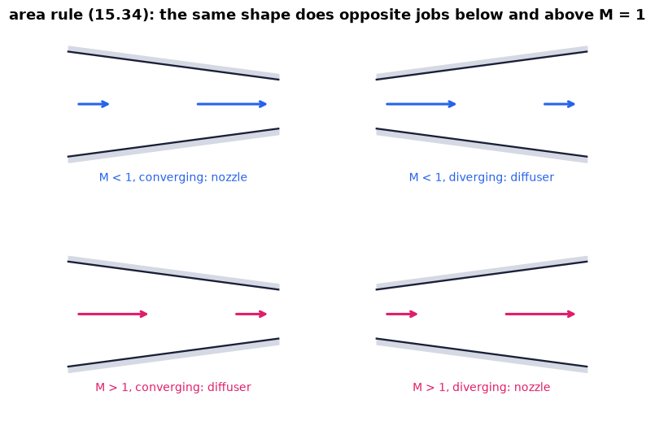

```
M = 0.5: converging -> nozzle, diverging -> diffuser
M = 2.0: converging -> diffuser, diverging -> nozzle
none sonic
```

```python
fig = draw_four_ducts()                                      # our sketch of the four cases
plt.show()                                                   # display it
for M in (0.5, 2.0):                                         # subsonic, supersonic
    print(f"M = {M}: converging -> {GD.duct_role(M, -1)}, diverging -> {GD.duct_role(M, +1)}")   # (15.34) decides
print(GD.duct_role(0.5, 0), GD.duct_role(1.0, -1))           # no area change: "none"; at M = 1: "sonic"
```

**What you see.** Four ducts: converging and diverging, each with a subsonic and a supersonic stream; the printed lines give the role `GD.duct_role` assigns to each.

**How to read it.** Read the table diagonally: a converging subsonic duct and a diverging supersonic duct are both nozzles; the other two are diffusers. The shape alone never tells you which.

**What would change if…** …the flow were exactly sonic? Then $\dfrac{du}{u}=-\dfrac{1}{1-M^2}\dfrac{dA}{A}$ (15.34) divides by zero: a sonic flow cannot sit in a duct whose area changes, only at a throat (N44).

📝 **Note.** **N44 [B]** At a throat dA = 0, so $\dfrac{du}{u}=-\dfrac{1}{1-M^2}\dfrac{dA}{A}$ (15.34) gives either du = 0 or M = 1: **sonic speed can occur only at a throat, but a throat need not be sonic.** (The 0/0 at M = 1 has a finite limit — l'Hôpital's rule.)

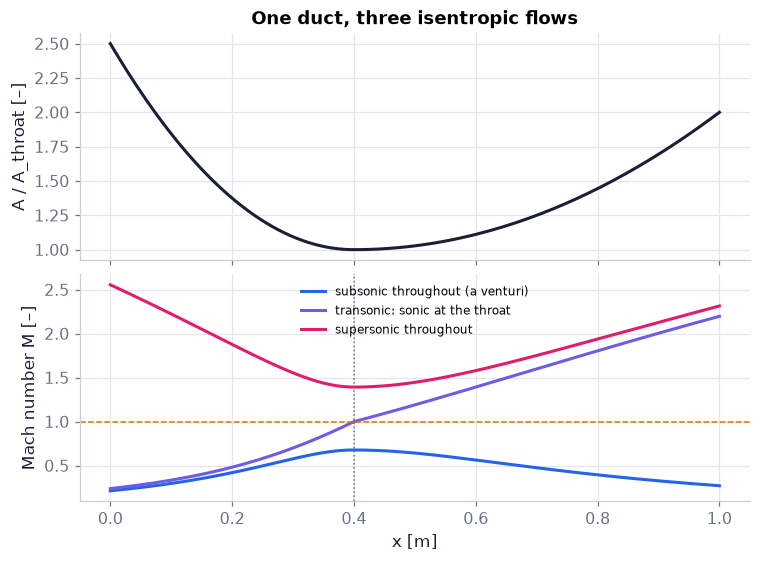

```python
x = np.linspace(0.0, 1.0, 201)                               # 201 stations: the throat x = 0.4 is a grid point
fig, (a, b) = plt.subplots(2, 1, figsize=(6.8, 5.0), sharex=True)   # area above, Mach number below
a.plot(x, GD.laval_area(x), color=COLORS["ink"])             # the duct: two parabolas, throat area 1 at x = 0.4
a.set(ylabel="A / A_throat [–]", title="One duct, three isentropic flows")
for branch, A_star, col, lab in (("subsonic", 0.9, COLORS["blue"], "subsonic throughout (a venturi)"),
                                 ("transonic", None, COLORS["accent"], "transonic: sonic at the throat"),
                                 ("supersonic", 0.9, COLORS["rose"], "supersonic throughout")):
    sol = GD.nozzle_isentropic(x, GD.laval_area, branch=branch, A_star=A_star)   # (15.31) inverted station by station
    b.plot(x, sol["M"], color=col, label=lab)                # Mach number along the duct
b.axhline(1.0, color=COLORS["amber"], ls="--", lw=1)         # M = 1
b.axvline(0.4, color=COLORS["muted"], ls=":", lw=1)          # the throat
b.set(xlabel="x [m]", ylabel="Mach number M [–]"); b.legend(fontsize=8)
savefig(fig, "ch15", "c06_three_solutions"); plt.show()      # save and display
```

**What you see.** A convergent–divergent duct (top) and three steady isentropic flows through it (bottom): subsonic everywhere (blue, with a sonic area 10 % below the throat area), the transonic one that is sonic at the throat (purple), and supersonic everywhere (rose).

**How to read it.** The blue flow speeds up to the throat and slows after it (a venturi): the throat is a speed *maximum* with du = 0. The rose flow does the opposite. Only the purple flow crosses M = 1 — and it does so exactly at the throat.

**What would change if…** …the sonic area of the blue flow rose to the throat area? Its peak would touch M = 1 at the throat; from there it can continue on the purple curve.

📝 **Note.** **N45 [B]** (ours; result given, not derived) the Mach-number twin of $\dfrac{du}{u}=-\dfrac{1}{1-M^2}\dfrac{dA}{A}$ (15.34): $\dfrac{dM}{M}=-\dfrac{1+\frac{\gamma-1}{2}M^2}{1-M^2}\dfrac{dA}{A}$ (ours).

```python
M_, g_ = sp.symbols("M gamma", positive=True)                # symbols
lnA = -sp.log(M_) + (g_ + 1) / (2 * (g_ - 1)) * (sp.log(2 / (g_ + 1)) + sp.log(1 + (g_ - 1) / 2 * M_**2))   # ln of (15.31), written as a sum of logs
resid = sp.diff(lnA, M_) * M_ + (1 - M_**2) / (1 + (g_ - 1) / 2 * M_**2)   # d lnA / d lnM + (1 - M²)/Θ: should vanish
print(sp.simplify(sp.together(resid)))                         # 0: so dM/M = -Θ/(1 - M²) dA/A, the Mach-number twin of (15.34)
```

```
0
```

#### ✏️ Tiny example: 1 % more area

$\dfrac{du}{u}=-\dfrac{1}{1-M^2}\dfrac{dA}{A}$ (15.34) with dA/A = +0.01.

1. M = 0.5: du/u = −0.01/(1 − 0.25) = **−1.33 %** (slower; a diffuser).
2. M = 2: du/u = −0.01/(1 − 4) = **+0.33 %** (faster; still a nozzle).
3. Density by $d\rho/\rho=-M^2\,du/u$ (15.33): at M = 2, dρ/ρ = −4 × 0.33 % = −1.33 %.
4. Check mass $\dfrac{d\rho}{\rho}+\dfrac{du}{u}+\dfrac{dA}{A}=0$ (15.19): −1.33 + 0.33 + 1.00 = 0 ✓.

```python
print(GD.area_velocity(np.array([0.3, 0.5, 2.0]), 1.0))       # du/u per unit dA/A: -1/(1 - M²) -> -1.099, -1.333, +0.333
c = GD.influence_coefficients(0.5, dA_over_A=0.01)           # all the relative changes at M = 0.5 for 1 % more area
print({k: round(c[k], 5) for k in ("du_over_u", "drho_over_rho", "dp_over_p", "dT_over_T", "dM_over_M")})   # -1.33 %, +0.33 %, …
```

```
[-1.0989 -1.3333  0.3333]
{'du_over_u': -0.01333, 'drho_over_rho': 0.00333, 'dp_over_p': 0.00467, 'dT_over_T': 0.00133, 'dM_over_M': -0.014}
```

**What does the code above do?**

1. `GD.area_velocity(M, 1.0)` is the coefficient $-1/(1-M^2)$ of $\dfrac{du}{u}=-\dfrac{1}{1-M^2}\dfrac{dA}{A}$ (15.34): negative (diffuser-like for a widening duct) below Mach 1, positive above.
2. `GD.influence_coefficients` solves the whole small linear system of P362 at once: at M = 0.5 a 1 % wider duct gives du/u = −1.33 %, dρ/ρ = +0.33 %, and dM/M = −1.40 % (the Mach number falls faster than the speed because the gas warms).

```python
x = np.linspace(0.0, 1.0, 201)                               # stations with the throat on the grid
sol = GD.nozzle_isentropic(x, GD.laval_area, branch="transonic")   # the transonic solution
u = sol["M"] * np.sqrt(sol["T_over_T0"])                     # u ∝ M sqrt(T): u = M sqrt(gamma R T0 · T/T0)
slope = np.gradient(np.log(u), x) / np.gradient(np.log(sol["A"]), x)   # (du/u)/(dA/A) by finite differences (np.gradient)
mask = np.abs(sol["M"] - 1.0) > 0.2                          # stay away from the throat, where both differences vanish
assert np.allclose(slope[mask], GD.area_velocity(sol["M"][mask], 1.0), rtol=2e-2)   # the measured slope obeys (15.34)
print(f"{mask.sum()} stations checked; worst relative gap {np.max(np.abs(slope[mask]/GD.area_velocity(sol['M'][mask], 1.0) - 1)):.1e}")
```

```
168 stations checked; worst relative gap 5.4e-03
```

**From scratch.** Along the computed nozzle flow we *measure* the ratio of the relative speed change to the relative area change with `np.gradient` (centred differences of an array) and compare it with $-1/(1-M^2)$: $\dfrac{du}{u}=-\dfrac{1}{1-M^2}\dfrac{dA}{A}$ (15.34) holds station by station.

```python
x = np.linspace(0.0, 1.0, 51)                                # stations (the throat x = 0.4 is a grid point)
ratios = np.linspace(1.2, 4.0, 6 if FAST else 10)            # exit-to-throat area ratios on the slider
def three(AR):                                               # the three isentropic solutions for one nozzle
    A_fn = lambda xx: GD.laval_area(xx, A_exit=AR)           # the duct with this exit area (throat area 1)
    out = {}   # trace name -> (x, M(x))
    for branch, A_star, name in (("subsonic", 0.9, "subsonic throughout"), ("transonic", None, "transonic"),   # the three solutions
                                 ("supersonic", 0.9, "supersonic throughout")):   # (sonic area 10 % below the throat for the two one-sided ones)
        out[name] = (x, GD.nozzle_isentropic(x, A_fn, branch=branch, A_star=A_star)["M"])   # (15.31) inverted at every station
    out["M = 1"] = (x, np.ones_like(x))                      # the sonic line
    return out   # all traces for this area ratio
fig = slider_figure(three, "A_e/A_t", ratios, xlabel="x [m] (throat at 0.4 m)", ylabel="Mach number M [–]",   # slider over the exit area
                    title="A bigger exit area makes the supersonic exit faster", yrange=[0, 3.5])   # the message
fig.show()                                                   # every position computed now
```

[interactive chart not shown]

**Figure F4.** The slider is the exit-to-throat area ratio $A_e/A_t$, from 1.2 to 4.

**What you see.** M(x) for the three isentropic solutions of one duct, with the sonic line; the slider changes the exit area.

**How to read it.** The converging half never changes — it does not know about the exit. The transonic exit Mach number climbs from 1.5 at $A_e/A_t$ = 1.2 to 2.9 at 4; the subsonic one falls toward zero.

**What would change if…** …the gas had γ = 5/3? For the same area ratio the supersonic exit would be faster (2.40 instead of 2.20 for $A_e/A_t$ = 2): the exponent of $\dfrac{A}{A^*}=\dfrac1M\left[\dfrac{2}{\gamma+1}\left(1+\dfrac{\gamma-1}{2}M^2\right)\right]^{(1/2)(\gamma+1)/(\gamma-1)}$ (15.31) drops from 3 to 2, so the area ratio grows more slowly with M.

#### 🎮 Interactive: Why does a supersonic nozzle widen?

**Why interactive rather than a static figure:** you move a cursor along a duct you shaped and three bars — density, speed, area — always sum to zero while the density bar overtakes the speed bar exactly at Mach 1; a static figure shows the result, the bars show the reason.

Start with the **Walkthrough**; the **Explain** tab works every number out with your settings, and the **Derivation** tab (where there is one) steps through the same derivation as above. Areas are ratios to the sonic area A*; station 1 is the reservoir side, and every ratio is to the stagnation state (subscript 0).

**What to try:**

- Play the station through the throat and watch the density bar overtake the speed bar.
- Switch the solution to 'subsonic throughout': the same throat, no Mach 1.
- Find the ghost dot: the other Mach number with the same area.

```python
show_viz("ch15", "area_mach_nozzle")   # full-width explainer; ⤢ Full screen for more room
```

🎮 Interactive 2/9 Why does a supersonic nozzle widen? Open alone ↗

[interactive chart not shown]

📝 **Note.** **N46 [B]** **A rocket nozzle with our own inputs** (`rocket`; air's γ and R, a simplification). The chain: $p_e/p_0$ → $M_e$ (inverse of $\dfrac{p_0}{p}=\left[1+\dfrac{\gamma-1}{2}M^2\right]^{\gamma/(\gamma-1)}$ (15.29)) → $A_e/A^*$ ($\dfrac{A}{A^*}=\dfrac1M\left[\dfrac{2}{\gamma+1}\left(1+\dfrac{\gamma-1}{2}M^2\right)\right]^{(1/2)(\gamma+1)/(\gamma-1)}$ (15.31)) → $T_e$ → $u_e$ → ṁ = thrust/$u_e$ → $A_e$ → $A^*$.

> ⚠️ **Common confusion** (trap T9): the chamber *is* the stagnation state, and the nozzle is designed so that the exit pressure equals the ambient one.

```python
r = ch15.rocket_nozzle(rocket["thrust"], rocket["p0"], rocket["T0"], rocket["p_exit"], air)   # the chain above
print({k: round(float(r[k]), 4) for k in ("M_e", "T_e", "u_e", "mdot", "A_e", "Ae_over_At", "A_throat")})
print(GD.choked_mass_flow(rocket["p0"], rocket["T0"], r["A_throat"], air))   # check: that throat passes the same 25.86 kg/s
```

```
{'M_e': 2.8572, 'T_e': 1139.5147, 'u_e': 1933.4855, 'mdot': 25.86, 'A_e': 0.0432, 'Ae_over_At': 3.6959, 'A_throat': 0.0117}
25.86003367732915
```

**What does the code above do?**

1. $p_e/p_0$ = 101 325/3 × 10⁶ = 0.0338 → $M_e$ = 2.857 → $A_e/A^*$ = 3.70; $T_e$ = 1140 K; $u_e$ = 1933 m/s.
2. ṁ = 50 000/1933 = 25.9 kg/s; the exit area is 0.043 m² and the throat 0.0117 m² (a 12 cm diameter).
3. `GD.choked_mass_flow` with that throat returns the same mass flow: the chain closes.

📝 **Note.** **N47 [B]** Thrust of a pressure-matched nozzle: $\rho_eu_e^2A_e=\dot mu_e=\gamma p_eM_e^2A_e$. Off design a pressure term appears: thrust = $\dot mu_e+(p_e-p_a)A_e$.

```python
T10, p10, rho10 = STAT.standard_atmosphere(10000.0)          # the standard atmosphere at 10 km: 223 K, 26.4 kPa (lapse rate -6.5 K/km in Kundu's sign, +6.5 K/km meteorological)
print(ch15.nozzle_thrust(r["mdot"], r["u_e"], 101325.0, 101325.0, r["A_e"]))   # on design at sea level: 50.0 kN
print(ch15.nozzle_thrust(r["mdot"], r["u_e"], 101325.0, p10, r["A_e"]))        # the same nozzle at 10 km: 53.2 kN
```

```
49999.99999999999
53233.41896560893
```

**What would change if…** …the supersonic stream must come back to a high pressure? It cannot do so smoothly in general. It jumps — C07.

## 15.6 Normal Shock Waves

**What is this section about?** A supersonic stream can change to a subsonic one across a layer a few molecular free paths thick. Across it the three duct laws still hold — and they fix everything from one number, the upstream Mach number.

### 🧩 The jump across a normal shock: $\dfrac{p_2}{p_1}=1+\dfrac{2\gamma}{\gamma+1}\left(M_1^2-1\right)$ (15.39) `C07`

*The question:* If a flow changes abruptly with no heat, no wall force and no change of area, what can the state behind it be?

#### The problem in plain words

Cars on a motorway meet a jam: within a few car lengths they go from fast and far apart to slow and close together. No car is created or destroyed, and the "front" of the jam is thin. A shock is the same thing in a gas: fast, thin gas arrives; slow, dense, hot gas leaves. We do not need to know what happens inside the thin layer — only that mass, momentum and energy that go in must come out.

#### The idea

```
1: u₁ fast, ρ₁, p₁, T₁  ──►│ shock │──►  2: u₂ slow, ρ₂ > ρ₁, p₂ > p₁, T₂ > T₁
```

Three laws, three unknowns (ρ₂, u₂, p₂) → two solutions: nothing happens, or the shock.

📝 **Note.** **N48 [B]** A **shock** is a compression of finite strength, a few mean free paths thick (the **mean free path** is the average distance a molecule travels between collisions — about 7 × 10⁻⁸ m in sea-level air; Ch. 1 C06), treated as a jump. Entropy is made inside it, so the isentropic ratios of C04–C05 cannot be carried across — only the three laws of C03.

📝 **Note.** **N49 [B] · N50 [B] · N51 [B]** Mass: $\rho_1u_1=\rho_2u_2$ (15.35) ($\rho uA=\dot m=\text{const.}$ (15.18) at constant area) · momentum: $p_1-p_2=-\rho_1u_1^2+\rho_2u_2^2$ (15.36) ($-\dot mu_1+\dot mu_2=(pA)_1-(pA)_2+F$ (15.24) with F = 0 and $A_1=A_2$) · energy: $h_1+\tfrac12u_1^2=h_2+\tfrac12u_2^2$ (15.37) ($h_2+\tfrac12u_2^2-h_1-\tfrac12u_1^2=Q$ (15.22) with Q = 0).

> ⚠️ **Common confusion** (trap T17): the energy line looks like Bernoulli's equation but is only the energy law; entropy is not constant across the shock.

> 🔁 **Tools from earlier chapters used in this block** (one line each; the full primers are in the chapters named)
- **Vieta's formulas** — for a quadratic ax² + bx + c the two roots multiply to c/a and add to −b/a; here knowing one root of the shock quadratic ("nothing happens") hands you the other. *(Ch. 2, P71)*
- **caching a slow cell (`functools.lru_cache`)** — a function wrapped in `functools.lru_cache` remembers its answers, so a slow symbolic calculation runs once per session; used here for the two slowest sympy helpers when FAST is on. *(Ch. 10, P252)*

> 📎 **Primer — dividing a known root out of a quadratic.** `P363` · If you already know one solution $r_0$ of a quadratic, the quadratic is $(r-r_0)$ times something linear — divide and the other root drops out. (Vieta: the product of the roots is the constant term over the leading coefficient.) Here the known root is "nothing happens".

```python
import sympy as sp
r = sp.symbols('r')
poly = 2*r**2 - 7*r + 5                 # we know r = 1 is a root: 2 - 7 + 5 = 0
print(sp.cancel(poly/(r - 1)))           # 2*r - 5  ->  the other root is 5/2 (and 1 x 5/2 = 5/2, Vieta)
```

```
2*r - 5
```

#### 🧮 Derivation — The pressure jump across a normal shock `D13` ★★★ (Eq. 15.39: $\dfrac{p_2}{p_1}=1+\dfrac{2\gamma}{\gamma+1}\left(M_1^2-1\right)$)

**What we want to show.** From mass, momentum and energy alone, find the pressure behind a normal shock in terms of the upstream Mach number — the step the book covers with "after some algebra".

**Assumptions.** Steady, constant area, no wall force, no heat (the three starting laws); perfect gas with constant γ (step 1).

**The plan.**

1. Write the energy law with p and ρ.
2. Use one unknown, the velocity ratio.
3. Eliminate density and pressure.
4. a quadratic appears whose root "nothing happens" we divide out.
5. Go back for the pressure.

**Tools we use** (each explained before this point): dividing a known root out of a quadratic (primer P363) · Vieta (P71 reminder) · $h=C_pT$ and the gas law

**We start from**

$$ \rho_1u_1=\rho_2u_2\ \text{(15.35),}\ p_1-p_2=-\rho_1u_1^2+\rho_2u_2^2\ \text{(15.36),}\ h_1+\tfrac12u_1^2=h_2+\tfrac12u_2^2\ \text{(15.37)} $$

*In words:* What goes in comes out, for mass, momentum and energy

**Step 1 of 13 — Write the enthalpy with p and ρ.**

$$ \dfrac{\gamma}{\gamma-1}\dfrac{p_1}{\rho_1}+\dfrac12u_1^2=\dfrac{\gamma}{\gamma-1}\dfrac{p_2}{\rho_2}+\dfrac12u_2^2\ \text{(15.38)} $$

- *Why we can do this:* $h=C_pT$, $C_p=\gamma R/(\gamma-1)$ and $T=p/(\rho R)$ give $h=\dfrac{\gamma}{\gamma-1}\dfrac p\rho$; put it into $h_1+\tfrac12u_1^2=h_2+\tfrac12u_2^2$ (15.37).
- *In words:* The energy law without temperature.

**Step 2 of 13 — Name the velocity ratio and use mass.**

$$ r\equiv\dfrac{u_2}{u_1},\qquad\rho_2=\dfrac{\rho_1}{r} $$

- *Why we can do this:* $\rho_1u_1=\rho_2u_2$ (15.35) gives $\rho_2=\rho_1u_1/u_2$. One unknown, r, will now carry the whole problem.
- *In words:* If the gas slows to a fraction r of its speed, its density rises by 1/r.

**Step 3 of 13 — Solve momentum for the downstream pressure.**

$$ p_2=p_1+\rho_1u_1^2\,(1-r) $$

- *Why we can do this:* $p_1-p_2=-\rho_1u_1^2+\rho_2u_2^2$ (15.36) rearranged: $p_2=p_1+\rho_1u_1^2-\rho_2u_2^2$, and $\rho_2u_2^2=(\rho_2u_2)u_2=\rho_1u_1\cdot ru_1$.
- *In words:* The pressure rises by the momentum flux the gas gives up.

**Step 4 of 13 — Form the downstream p/ρ.**

$$ \dfrac{p_2}{\rho_2}=r\left[\dfrac{p_1}{\rho_1}+u_1^2(1-r)\right] $$

- *Why we can do this:* Divide step 3 by $\rho_2=\rho_1/r$. This is the combination the energy law needs.
- *In words:* Downstream "temperature" in terms of upstream quantities and r.

**Step 5 of 13 — Substitute into the energy law.**

$$ \dfrac{\gamma}{\gamma-1}\dfrac{p_1}{\rho_1}+\dfrac12u_1^2=\dfrac{\gamma}{\gamma-1}\,r\left[\dfrac{p_1}{\rho_1}+u_1^2(1-r)\right]+\dfrac12r^2u_1^2 $$

- *Why we can do this:* Step 4 and $u_2=ru_1$ in step 1. Only r is unknown now.
- *In words:* One equation, one unknown.

**Step 6 of 13 — Divide by $u_1^2$.**

$$ \dfrac{\gamma}{\gamma-1}a+\dfrac12=\dfrac{\gamma}{\gamma-1}\,r\,(a+1-r)+\dfrac12r^2,\qquad a\equiv\dfrac{p_1}{\rho_1u_1^2} $$

- *Why we can do this:* $u_1\neq0$. The upstream state enters only through the number a (we shall see $a=1/\gamma M_1^2$).
- *In words:* The same equation in pure numbers.

**Step 7 of 13 — Clear the fractions and collect powers of r.**

$$ (\gamma+1)\,r^2-2\gamma(a+1)\,r+2\gamma a+\gamma-1=0 $$

- *Why we can do this:* Multiply by 2(γ − 1) and move everything to one side: $r^2$ has the coefficient $2\gamma-(\gamma-1)=\gamma+1$.
- *In words:* A quadratic for the velocity ratio.

**Step 8 of 13 — Test the root "nothing happens".**

$$ (\gamma+1)-2\gamma(a+1)+2\gamma a+\gamma-1=0\quad\checkmark $$

- *Why we can do this:* r = 1 (no change at all) obviously satisfies the three laws, so it must be a root; inserting it confirms the algebra.
- *In words:* "No shock" is always a solution.

**Step 9 of 13 — Divide that root out.**

$$ (r-1)\left[(\gamma+1)\,r-(2\gamma a+\gamma-1)\right]=0 $$

- *Why we can do this:* A quadratic with a known root $r_0$ is $(r-r_0)$ times a linear factor; by Vieta the product of the roots is $(2\gamma a+\gamma-1)/(\gamma+1)$.
- *In words:* The quadratic splits into "nothing happens" and one other possibility.

**Step 10 of 13 — Read off the other root.**

$$ r=\dfrac{\gamma-1}{\gamma+1}+\dfrac{2\gamma}{\gamma+1}\,a $$

- *Why we can do this:* Set the square bracket to zero. This is the shock.
- *In words:* The speed ratio across the shock.

**Step 11 of 13 — Form 1 − r.**

$$ 1-r=\dfrac{2\,(1-\gamma a)}{\gamma+1} $$

- *Why we can do this:* $1-\dfrac{\gamma-1}{\gamma+1}=\dfrac{2}{\gamma+1}$; step 3 needs this combination.
- *In words:* The fraction of its speed the gas loses.

**Step 12 of 13 — Return to the momentum law.**

$$ \dfrac{p_2}{p_1}=1+\dfrac{1-r}{a}=1+\dfrac{2\gamma}{\gamma+1}\left[\dfrac{\rho_1u_1^2}{\gamma p_1}-1\right]\ \text{(unnumbered, §15.6)} $$

- *Why we can do this:* Step 3 divided by $p_1$ is $1+(1-r)/a$; insert step 11 and $1/a=\rho_1u_1^2/p_1$.
- *In words:* The pressure ratio in terms of the upstream momentum flux.

**Step 13 of 13 — Recognise the Mach number.**

$$ \dfrac{p_2}{p_1}=1+\dfrac{2\gamma}{\gamma+1}\left(M_1^2-1\right)\ \text{(15.39)} $$

- *Why we can do this:* $c_1^2=\gamma p_1/\rho_1$, so $\rho_1u_1^2/(\gamma p_1)=u_1^2/c_1^2=M_1^2$ (and $a=1/\gamma M_1^2$).
- *In words:* The pressure jump depends on the upstream Mach number alone.

**Result**

$$ \begin{array}{l}\dfrac{p_2}{p_1}=1+\dfrac{2\gamma}{\gamma+1}\left(M_1^2-1\right)\ \text{(15.39) — and on the way}\ \dfrac{u_2}{u_1}=\dfrac{(\gamma-1)M_1^2+2}{(\gamma+1)M_1^2}\ \text{(step 10} \\ \text{with}\ a=1/\gamma M_1^2\ \text{).}\end{array} $$

**What it means.** Three laws, one extra solution, one parameter: every normal shock in a given gas is labelled by $M_1$. Nothing here says $M_1>1$ — that comes from the second law (C08). **Fails when:** the gas is not perfect (very strong shocks dissociate air), or area, wall force or heat act across the layer.

**Check it.** Units — pure numbers ✓. Limits — $M_1=1$: $p_2/p_1=1$ (the two roots coincide: no shock); $M_1\to\infty$: $p_2/p_1\to2\gamma M_1^2/(\gamma+1)$. Number — $M_1$ = 2: 1 + 1.1667 × 3 = 4.5. Residuals of the three laws < 10⁻¹³ (`GD.normal_shock_residuals`).

```python
import sympy as sp                                   # symbolic algebra: we re-run the derivation's own moves
g, a, r = sp.symbols("gamma a r", positive=True)     # gamma; a = p1/(rho1 u1^2); r = u2/u1 (the velocity ratio)
M1 = sp.symbols("M_1", positive=True)                # upstream Mach number
p2_over_p1 = 1 + (1 - r) / a                         # step 3: momentum, p2 = p1 + rho1 u1^2 (1 - r), divided by p1
energy = g/(g-1)*a + sp.Rational(1, 2) - (g/(g-1)*r*(a + 1 - r) + r**2/2)   # step 6: energy / u1^2, left - right
quadratic = sp.expand(2*(g-1)*energy)                     # step 7: multiply by 2(gamma-1) -> a quadratic in r
assert sp.simplify(quadratic - ((g+1)*r**2 - 2*g*(a+1)*r + 2*g*a + g - 1)) == 0   # ... exactly the printed quadratic
assert sp.simplify(quadratic.subs(r, 1)) == 0             # step 8: r = 1 ("no shock") is always a root
other = sp.cancel(quadratic / (r - 1))                    # step 9: divide the known root out -> a linear factor
r_shock = sp.solve(other, r)[0]                      # step 10: the shock root
assert sp.simplify(r_shock - ((g-1) + 2*g*a)/(g+1)) == 0   # ... equal to step 10's (gamma-1)/(gamma+1) + 2 gamma a/(gamma+1)
jump = sp.simplify(p2_over_p1.subs(r, r_shock).subs(a, 1/(g*M1**2)))    # steps 11-13: back into momentum, a = 1/(gamma M1^2)
assert sp.simplify(jump - (1 + 2*g/(g+1)*(M1**2 - 1))) == 0             # Eq. (15.39)
print(sp.factor(quadratic), "|", sp.simplify(r_shock.subs(a, 1/(g*M1**2))))  # the factored quadratic and u2/u1(M1)
```

```
(r - 1)*(-2*a*gamma + gamma*r - gamma + r + 1) | (M_1**2*(gamma - 1) + 2)/(M_1**2*(gamma + 1))
```

📝 **Notes taught inside `D13`:** **N52 [B]** the energy law with p and ρ, $\dfrac{\gamma}{\gamma-1}\dfrac{p_1}{\rho_1}+\dfrac12u_1^2=\dfrac{\gamma}{\gamma-1}\dfrac{p_2}{\rho_2}+\dfrac12u_2^2$ (15.38) (step 1) · **N53 [B]** the half-way line $\dfrac{p_2}{p_1}=1+\dfrac{2\gamma}{\gamma+1}\left[\dfrac{\rho_1u_1^2}{\gamma p_1}-1\right]$ (unnumbered, §15.6) (step 12)

> ⚠️ **Common confusion (traps in `D13`):** Dividing by (r − 1) is legitimate only because we are looking for the *other* root; work with $u_2/u_1$, not with ρ and p separately; $\rho_1u_1^2/\gamma p_1$ is $M_1^2$ with the *upstream* sound speed; the energy law is not Bernoulli's equation (trap T17).

#### 🧮 Derivation — The Mach number behind a normal shock `D14` ★★ (Eq. 15.40: $M_2^2=\dfrac{(\gamma-1)M_1^2+2}{2\gamma M_1^2+1-\gamma}$)

**What we want to show.** Find the downstream Mach number from the upstream one.

**Assumptions.** As D13.

**The plan.**

1. Write momentum with Mach numbers.
2. Insert the pressure jump.
3. Solve for $M_2^2$.

**Tools we use** (each explained before this point): dynamic pressure in a gas (primer P359) · a common denominator

**We start from**

$$ p_1-p_2=-\rho_1u_1^2+\rho_2u_2^2\ \text{(15.36) and}\ \dfrac{p_2}{p_1}=1+\dfrac{2\gamma}{\gamma+1}\left(M_1^2-1\right)\ \text{(15.39).} $$

**Step 1 of 7 — Rearrange the momentum law.**

$$ p_1+\rho_1u_1^2=p_2+\rho_2u_2^2 $$

- *Why we can do this:* $p_1-p_2=-\rho_1u_1^2+\rho_2u_2^2$ (15.36) with the terms of each side together.
- *In words:* Pressure plus momentum flux is the same on both sides.

**Step 2 of 7 — Use $\rho u^2=\gamma pM^2$.**

$$ p_1\left(1+\gamma M_1^2\right)=p_2\left(1+\gamma M_2^2\right)\ \text{(unnumbered, §15.6)} $$

- *Why we can do this:* $\rho u^2=\rho c^2M^2=\gamma pM^2$ on each side, with that side's own sound speed (primer P359).
- *In words:* The same balance in Mach numbers.

**Step 3 of 7 — Isolate the downstream bracket.**

$$ 1+\gamma M_2^2=\dfrac{1+\gamma M_1^2}{p_2/p_1} $$

- *Why we can do this:* Divide both sides of step 2 by $p_2$ (a pressure, never zero), which keeps the equation true; it leaves the downstream bracket alone on the left and the pressure jump $p_2/p_1$ where step 4 can supply it.
- *In words:* The stronger the pressure jump, the smaller $M_2$.

**Step 4 of 7 — Put the pressure jump on one denominator.**

$$ \dfrac{p_2}{p_1}=\dfrac{2\gamma M_1^2-(\gamma-1)}{\gamma+1} $$

- *Why we can do this:* $\dfrac{p_2}{p_1}=1+\dfrac{2\gamma}{\gamma+1}\left(M_1^2-1\right)$ (15.39): $1+\dfrac{2\gamma}{\gamma+1}(M_1^2-1)=\dfrac{\gamma+1+2\gamma M_1^2-2\gamma}{\gamma+1}$. Writing 1 as (γ + 1)/(γ + 1) puts everything on one denominator, ready to be inverted in step 5.
- *In words:* The same jump as one fraction.

**Step 5 of 7 — Insert it.**

$$ 1+\gamma M_2^2=\dfrac{(\gamma+1)\left(1+\gamma M_1^2\right)}{2\gamma M_1^2-(\gamma-1)} $$

- *Why we can do this:* Step 4 in step 3. Substituting one equation into another is allowed; it removes the pressures and leaves only Mach numbers.
- *In words:* Only $M_1$ and γ remain.

**Step 6 of 7 — Subtract 1.**

$$ \gamma M_2^2=\dfrac{2\gamma+\gamma(\gamma-1)M_1^2}{2\gamma M_1^2-(\gamma-1)} $$

- *Why we can do this:* Subtract 1 from both sides of step 5 (the equation stays true) and write the right side over its own denominator. The new numerator is $(\gamma+1)(1+\gamma M_1^2)-[2\gamma M_1^2-(\gamma-1)]=(\gamma+1)+\gamma(\gamma+1)M_1^2-2\gamma M_1^2+(\gamma-1)=2\gamma+\gamma(\gamma-1)M_1^2$; this leaves $\gamma M_2^2$ alone on the left.
- *In words:* Nearly there.

**Step 7 of 7 — Divide by γ.**

$$ M_2^2=\dfrac{(\gamma-1)M_1^2+2}{2\gamma M_1^2+1-\gamma}\ \text{(15.40)} $$

- *Why we can do this:* γ ≠ 0; the denominator is rewritten in the book's order.
- *In words:* The downstream Mach number, from the upstream one.

**Result**

$$ M_2^2=\dfrac{(\gamma-1)M_1^2+2}{2\gamma M_1^2+1-\gamma}\ \text{(15.40).} $$

**What it means.** Supersonic in, subsonic out — and the stronger the shock the slower the outflow, down to a floor. **Fails when:** as D13; and the formula has no real value for $M_1^2<(\gamma-1)/2\gamma$.

**Check it.** Units — numbers ✓. Limits — $M_1=1$: $M_2=1$; $M_1\to\infty$: $M_2^2\to(\gamma-1)/2\gamma$, i.e. 0.378 for air. Symmetry — exchanging $M_1$ and $M_2$ in step 2 leaves it unchanged, so the map is its own inverse: 2 → 0.5774 → 2. Number — $M_1$ = 2: 3.6/10.8 = 1/3.

📝 **Notes taught inside `D14`:** **N54 [B]** $M_2^2=\dfrac{(\gamma-1)M_1^2+2}{2\gamma M_1^2+1-\gamma}$ (15.40)

> ⚠️ **Common confusion (traps in `D14`):** Solve for $M_2^2$, not $M_2$; the self-inverse property means a swapped input is not caught by the formula (trap T6).

> ⚠️ **Common confusion:** (trap T6) $M_2^2=\dfrac{(\gamma-1)M_1^2+2}{2\gamma M_1^2+1-\gamma}$ (15.40) is its own inverse — feed it the downstream Mach number and it returns the upstream one without complaint. `GD.normal_shock` refuses $M_1<1$ unless asked. Other sources number the stations 0 and 1.

📝 **Note.** **N55 [B]** $M_2$ against $M_1$: a map that is its own mirror image.

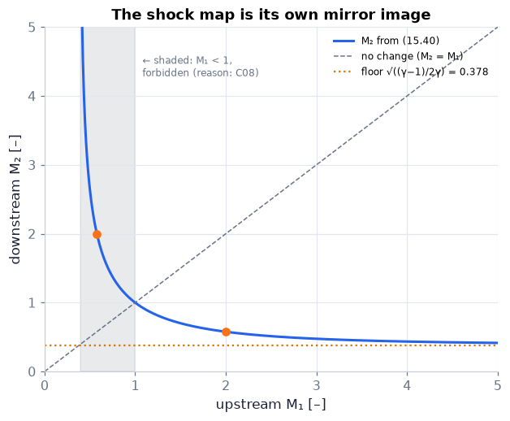

```python
M1 = np.linspace(0.4, 5.0, 400)                              # upstream Mach numbers (the formula is defined above 0.378)
M2 = GD.normal_shock_mach(M1)                                # (15.40)
fig, ax = plt.subplots(figsize=(5.6, 4.6))                   # a square-ish panel: the mirror symmetry shows
ax.axvspan(0.4, 1.0, color=COLORS["muted"], alpha=0.15)      # the forbidden half
ax.text(1.08, 4.6, "← shaded: M₁ < 1,\nforbidden (reason: C08)", ha="left", va="top", fontsize=8, color=COLORS["muted"])   # label beside the band, clear of the curve
ax.plot(M1, M2, color=COLORS["blue"], lw=2, label="M₂ from (15.40)")                     # the map
ax.plot([0, 5], [0, 5], color=COLORS["muted"], ls="--", lw=1, label="no change (M₂ = M₁)")   # the diagonal
lim = np.sqrt(0.4 / 2.8)                                     # sqrt((gamma-1)/(2 gamma)) = 0.378
ax.axhline(lim, color=COLORS["amber"], ls=":", lw=1.5, label=f"floor √((γ−1)/2γ) = {lim:.3f}")   # the asymptote
ax.plot([2.0, GD.normal_shock_mach(2.0)], [GD.normal_shock_mach(2.0), 2.0], "o", color=COLORS["orange"])   # the pair 2 <-> 0.577
ax.set(xlim=(0, 5), ylim=(0, 5), xlabel="upstream M₁ [–]", ylabel="downstream M₂ [–]",
       title="The shock map is its own mirror image")       # message
ax.legend(fontsize=8, loc="upper right"); savefig(fig, "ch15", "c07_M2_vs_M1"); plt.show()
```

**What you see.** The downstream Mach number against the upstream one (blue), the diagonal "nothing happens" (dashed), the floor 0.378 that $M_2$ approaches for very strong shocks (amber), and the forbidden half $M_1<1$ shaded. The two orange dots are the pair 2 ↔ 0.577.

**How to read it.** Reflect the curve in the diagonal and you get the same curve: apply the map twice and you are back. The two orange dots are mirror images. Only the part right of $M_1=1$ (supersonic in, subsonic out) is physical.

**What would change if…** …γ were 5/3? The floor would rise to $\sqrt{1/5}$ = 0.447: in a monatomic gas even the strongest shock leaves a faster outflow.

#### 🧮 Derivation — The density and temperature jumps `D15` ★★ (Eq. 15.41: $\dfrac{\rho_2}{\rho_1}=\dfrac{u_1}{u_2}=\dfrac{(\gamma+1)M_1^2}{(\gamma-1)M_1^2+2}$)

**What we want to show.** Complete the set of jump relations ("similarly obtained", says the book).

**Assumptions.** As D13.

**The plan.**

1. Density from mass.
2. Temperature from the gas law.
3. Massage it into the printed form.

**Tools we use** (each explained before this point): substitution · factoring a quadratic in $M_1^2$

**We start from**

$$ \begin{array}{l}\rho_1u_1=\rho_2u_2\ \text{(15.35), the velocity ratio of D13 step 10,}\ \dfrac{p_2}{p_1}=1+\dfrac{2\gamma}{\gamma+1}\left(M_1^2-1\right) \\ \text{(15.39) and}\ p=\rho RT\ \text{.}\end{array} $$

**Step 1 of 7 — Density ratio from mass.**

$$ \dfrac{\rho_2}{\rho_1}=\dfrac{u_1}{u_2}=\dfrac1r $$

- *Why we can do this:* Divide both sides of $\rho_1u_1=\rho_2u_2$ (15.35) by $\rho_1u_2$, which is never zero; the mass law then reads as a ratio, the form in which all the jumps are written.
- *In words:* The gas is compressed exactly as much as it is slowed.

**Step 2 of 7 — Write r with the Mach number.**

$$ r=\dfrac{(\gamma-1)M_1^2+2}{(\gamma+1)M_1^2} $$

- *Why we can do this:* D13 step 10 with $a=1/\gamma M_1^2$: $\dfrac{\gamma-1}{\gamma+1}+\dfrac{2}{(\gamma+1)M_1^2}$.
- *In words:* The speed ratio in terms of $M_1$.

**Step 3 of 7 — Invert.**

$$ \dfrac{\rho_2}{\rho_1}=\dfrac{u_1}{u_2}=\dfrac{(\gamma+1)M_1^2}{(\gamma-1)M_1^2+2}\ \text{(15.41)} $$

- *Why we can do this:* Put step 2 into step 1 and take the reciprocal of both sides (allowed: neither side is zero); the density jump is then a function of $M_1$ alone.
- *In words:* The density jump; it can never exceed (γ + 1)/(γ − 1).

**Step 4 of 7 — Temperature from the gas law.**

$$ \dfrac{T_2}{T_1}=\dfrac{p_2}{p_1}\,\dfrac{\rho_1}{\rho_2} $$

- *Why we can do this:* $T=p/(\rho R)$ on both sides; R cancels.
- *In words:* Temperature ratio = pressure ratio over density ratio.

**Step 5 of 7 — Insert both jumps.**

$$ \dfrac{T_2}{T_1}=\dfrac{\left[2\gamma M_1^2-(\gamma-1)\right]\left[(\gamma-1)M_1^2+2\right]}{(\gamma+1)^2M_1^2} $$

- *Why we can do this:* D14 step 4 and step 2 above. This is already correct; the remaining steps only reach the book's form.
- *In words:* The temperature jump as one fraction.

**Step 6 of 7 — Separate a 1.**

$$ \dfrac{T_2}{T_1}=1+\dfrac{2(\gamma-1)\left[\gamma M_1^4-(\gamma-1)M_1^2-1\right]}{(\gamma+1)^2M_1^2} $$

- *Why we can do this:* Expand the numerator, $2\gamma(\gamma-1)M_1^4+\left[4\gamma-(\gamma-1)^2\right]M_1^2-2(\gamma-1)$, and subtract $(\gamma+1)^2M_1^2=\left[4\gamma+(\gamma-1)^2\right]M_1^2$.
- *In words:* One, plus a term that vanishes when there is no shock.

**Step 7 of 7 — Factor the bracket.**

$$ \dfrac{T_2}{T_1}=1+\dfrac{2(\gamma-1)}{(\gamma+1)^2}\dfrac{\gamma M_1^2+1}{M_1^2}\left(M_1^2-1\right)\ \text{(15.42)} $$

- *Why we can do this:* $\gamma M_1^4-(\gamma-1)M_1^2-1=(\gamma M_1^2+1)(M_1^2-1)$ — multiply out to check.
- *In words:* The temperature rises by an amount proportional to $M_1^2-1$.

**Result**

$$ \begin{array}{l}\dfrac{\rho_2}{\rho_1}=\dfrac{u_1}{u_2}=\dfrac{(\gamma+1)M_1^2}{(\gamma-1)M_1^2+2}\ \text{(15.41) and}\ \dfrac{T_2}{T_1}=1+\dfrac{2(\gamma-1)}{(\gamma+1)^2}\dfrac{\gamma M_1^2+1}{M_1^2}\left(M_1^2-1\right) \\ \text{(15.42).}\end{array} $$

**What it means.** a strong shock heats without limit but compresses only sixfold. **Fails when:** as D13.

**Check it.** Units — numbers ✓. Limits — $M_1=1$: both 1; $M_1\to\infty$: density → 6, temperature → ∞ like $M_1^2$ (air). Number — $M_1$ = 2: 9.6/3.6 = 2.667; 4.5/2.667 = 1.6875 = 1 + (0.8/5.76)(6.6/4)(3) ✓.

📝 **Notes taught inside `D15`:** **N56 [B]** $\dfrac{\rho_2}{\rho_1}=\dfrac{u_1}{u_2}=\dfrac{(\gamma+1)M_1^2}{(\gamma-1)M_1^2+2}$ (15.41) (steps 1–3) · **N57 [B]** $\dfrac{T_2}{T_1}=1+\dfrac{2(\gamma-1)}{(\gamma+1)^2}\dfrac{\gamma M_1^2+1}{M_1^2}\left(M_1^2-1\right)$ (15.42) (steps 4–7)

As $M_1\to\infty$ the density ratio tends to $(\gamma+1)/(\gamma-1)$ = 6: **no shock squeezes air more than sixfold.**

> ⚠️ **Common confusion (traps in `D15`):** Check a rearrangement like step 6–7 with numbers before trusting it; the density limit is a property of the gas (γ), not of the shock.

#### ✏️ Tiny example: a Mach 2 shock by hand

γ = 1.4, $M_1$ = 2.

1. $\dfrac{p_2}{p_1}=1+\dfrac{2\gamma}{\gamma+1}\left(M_1^2-1\right)$ (15.39): $p_2/p_1$ = 1 + (2.8/2.4)(4 − 1) = **4.5**.
2. $\dfrac{\rho_2}{\rho_1}=\dfrac{u_1}{u_2}=\dfrac{(\gamma+1)M_1^2}{(\gamma-1)M_1^2+2}$ (15.41): $\rho_2/\rho_1$ = 2.4 × 4/(0.4 × 4 + 2) = 9.6/3.6 = **2.667**.
3. Gas law: $T_2/T_1$ = 4.5/2.667 = **1.6875** ($\dfrac{T_2}{T_1}=1+\dfrac{2(\gamma-1)}{(\gamma+1)^2}\dfrac{\gamma M_1^2+1}{M_1^2}\left(M_1^2-1\right)$ (15.42) gives the same).
4. $M_2^2=\dfrac{(\gamma-1)M_1^2+2}{2\gamma M_1^2+1-\gamma}$ (15.40): $M_2^2$ = (1.6 + 2)/(11.2 − 0.4) = 3.6/10.8 = 1/3, $M_2$ = **0.577**.
5. In sea-level air: 681 m/s in, 255 m/s out; 288 K in, 486 K out.
6. $T_0$: 288 × 1.8 = 519 K before; 486 × (1 + 0.2/3) = 519 K after ✓.

```python
s = GD.normal_shock(2.0)                                     # every jump at M1 = 2 (ratios downstream / upstream)
print({k: round(float(s[k]), 4) for k in ("M2", "p_ratio", "rho_ratio", "T_ratio", "p0_ratio", "T0_ratio", "dS_over_cv")})
state1 = dict(p=1.0, rho=1.4, u=2.0)                         # upstream in units where p1 = 1 and c1 = sqrt(1.4 × 1/1.4) = 1
state2 = dict(p=s["p_ratio"], rho=1.4 * s["rho_ratio"], u=2.0 * s["u_ratio"])   # downstream from the ratios
print(GD.normal_shock_residuals(state1, state2))             # (15.35)-(15.37): relative residuals ~1e-16
print({k: round(float(v), 3) for k, v in GD.normal_shock_fluxes(2.0).items()})   # each flux out/in = 1, and how it is shared
try:                                                         # a "shock" from M1 = 0.7 …
    GD.normal_shock(0.7)
except ValueError as err:                                    # … is refused (trap T6)
    print("ValueError:", err)
print(GD.normal_shock(0.7, allow_expansion=True)["admissible"])   # computed on request, but flagged as not admissible: False
nss = functools.lru_cache(maxsize=None)(ch15.normal_shock_sympy)   # cache the slow symbolic derivation (runs once per session)
print(nss()["p_ratio"])                                      # sympy's own (15.39)
```

```
{'M2': 0.5774, 'p_ratio': 4.5, 'rho_ratio': 2.6667, 'T_ratio': 1.6875, 'p0_ratio': 0.7209, 'T0_ratio': 1.0, 'dS_over_cv': 0.1309}
{'mass': 0.0, 'momentum': 0.0, 'energy': 0.0}
{'mass': 1.0, 'momentum': 1.0, 'energy': 1.0, 'p1_part': 0.152, 'ke1_part': 0.848, 'p2_part': 0.682, 'ke2_part': 0.318, 'h1_part': 0.556, 'k1_part': 0.444, 'h2_part': 0.938, 'k2_part': 0.062}
ValueError: normal_shock needs the UPSTREAM Mach number M1 >= 1 (station 1 is upstream; a shock from M1 < 1 would lower the entropy). Pass allow_expansion=True to see the forbidden root.
False
```

```
(2*M_1**2*gamma - gamma + 1)/(gamma + 1)
```

**What does the code above do?**

1. `GD.normal_shock(2.0)` returns all the jumps: $M_2$ = 0.5774, $p_2/p_1$ = 4.5, $\rho_2/\rho_1$ = 2.667, $T_2/T_1$ = 1.6875, $p_{02}/p_{01}$ = 0.7209, $T_{02}/T_{01}$ = 1 and $(S_2-S_1)/C_v$ = 0.1309.
2. Two state dicts in units where $p_1=1$, $c_1=1$ (so $u_1=M_1$) feed `GD.normal_shock_residuals`: mass, momentum and energy balance to round-off.
3. `GD.normal_shock_fluxes` shows how each conserved flux is split — the momentum flux is mostly $\rho u^2$ before the shock and mostly $p$ after it.
4. `try … except ValueError` catches the error the function raises for $M_1<1$; with `allow_expansion=True` it computes the jump but reports `admissible = False` — C08 says why.
5. `ch15.normal_shock_sympy()` re-derives $\dfrac{p_2}{p_1}=1+\dfrac{2\gamma}{\gamma+1}\left(M_1^2-1\right)$ (15.39) symbolically; `functools.lru_cache` remembers the answer so it runs once.

```python
g, M1 = 1.4, 2.0                                             # gamma; upstream Mach number
a = 1 / (g * M1**2)                                          # D13 step 6: a = p1/(rho1 u1²) = 1/(gamma M1²)
energy = lambda r: g/(g-1)*a + 0.5 - g/(g-1)*r*(a + 1 - r) - 0.5*r*r   # D13 step 6: energy law in r = u2/u1, left - right
r = brentq(energy, 0.05, 0.999)                              # the root that is not r = 1 (the bracket excludes it)
p_ratio = 1 + (1 - r) / a                                    # D13 step 12: back into momentum
assert np.allclose([1 / r, p_ratio], [s["rho_ratio"], s["p_ratio"]])   # same density and pressure jumps as the library
print(f"u2/u1 = {r:.4f}, rho2/rho1 = {1/r:.4f}, p2/p1 = {p_ratio:.4f}")
```

```
u2/u1 = 0.3750, rho2/rho1 = 2.6667, p2/p1 = 4.5000
```

**From scratch, without the closed form.** The energy law in the one unknown $r=u_2/u_1$ (D13 step 6) is solved numerically by `brentq` on a bracket that leaves out the trivial root r = 1; momentum then gives the pressure. Same numbers as `GD.normal_shock`.

```python
M1 = np.linspace(0.6, 5.0, 150)                              # upstream Mach numbers, including the forbidden half
gammas = [1.1, 1.15, 1.2, 1.25, 1.3, 1.35, 1.4, 1.45, 1.5, 1.55, 1.6, 5 / 3]                         # gamma slider
def jumps(g):                                                # the four jumps for one gamma
    return {"M₂, (15.40)": (M1, GD.normal_shock_mach(M1, g)),   # downstream Mach number
            "p₂/p₁ ÷ 10, (15.39)": (M1, GD.normal_shock_pressure_ratio(M1, g) / 10),   # pressure jump, scaled to share the axis
            "ρ₂/ρ₁, (15.41)": (M1, GD.normal_shock_density_ratio(M1, g)),   # density jump
            "T₂/T₁, (15.42)": (M1, GD.normal_shock_temperature_ratio(M1, g)),   # temperature jump
            "density limit (γ+1)/(γ−1)": ([0.6, 5.0], [(g + 1) / (g - 1)] * 2),   # the strong-shock limit of (15.41)
            "M₁ = 1 (left: forbidden, C08)": ([1.0, 1.0], [0.0, 9.0])}   # a vertical marker at M1 = 1
fig = slider_figure(jumps, "γ", gammas, xlabel="upstream Mach number M₁ [–]", ylabel="downstream / upstream [–]",   # slider over gamma
                    title="All the jumps of a normal shock follow from M₁ alone", yrange=[0, 9],   # the message
                    active=gammas.index(1.4))                # open on air, gamma = 1.4
fig.show()   # display
```

[interactive chart not shown]

**Figure F5a.** Slider: γ, from 1.1 to 5/3. Ratios are downstream / upstream; the pressure ratio is divided by 10 to share the axis.

**What you see.** The four jumps against $M_1$ for the chosen γ, with the density limit and the line $M_1=1$.

**How to read it.** At $M_1=1$ every ratio is 1 (no shock). Pressure and temperature keep growing like $M_1^2$; density levels off at $(\gamma+1)/(\gamma-1)$ — 6 for air, 4 for a monatomic gas. Left of $M_1=1$ the formulas still give numbers (an "expansion shock") — C08 forbids them.

**What would change if…** …γ → 1 (a very complex molecule)? The density limit $(\gamma+1)/(\gamma-1)$ runs away: such gases can be squeezed enormously by a strong shock.

📝 **Note.** **N64 [B]** **The same shock, seen from the still gas** (result given, not derived): subtract $u_1$ everywhere. The shock runs into still gas at $u_{\text{shock}}=M_1c_1$ and drags the gas behind it at $u_{\text{gas}}=u_1-u_2$. Tiny example: a shock that doubles the pressure of sea-level air — $\dfrac{p_2}{p_1}=1+\dfrac{2\gamma}{\gamma+1}\left(M_1^2-1\right)$ (15.39) gives $M_1^2$ = 1 + (2.4/2.8) × 1 = 1.857, $M_1$ = 1.363; shock speed 1.363 × 340.3 = 464 m/s; wind behind it 464 × (1 − 1/1.625) = 178 m/s.

```
{'M_s': 1.36, 'u_shock': 463.74, 'u_gas': 178.36, 'T2': 354.65, 'T0_behind_lab': 370.48, 'p0_behind_lab': 236120.69}
T0 in the shock's frame (both sides): 395.2 K
```

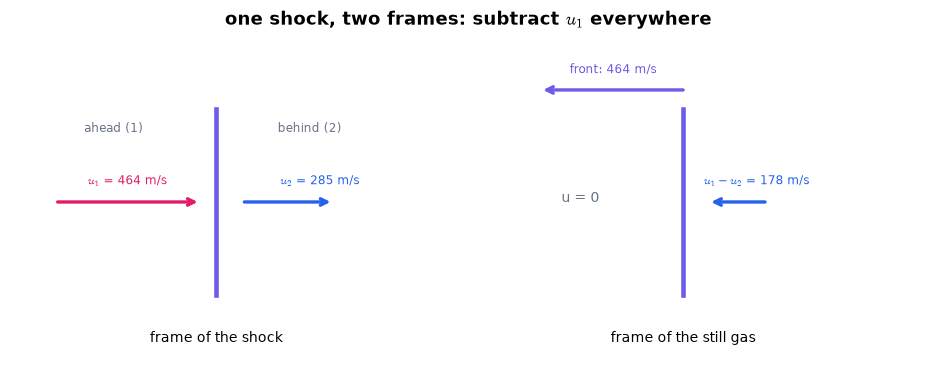

```python
ms = GD.moving_shock(101325.0, 288.15, p2_over_p1=2.0, gas=air)   # a shock that doubles the pressure of sea-level air
print({k: round(float(ms[k]), 2) for k in ("M_s", "u_shock", "u_gas", "T2", "T0_behind_lab", "p0_behind_lab")})
print("T0 in the shock's frame (both sides):", round(288.15 * GD.stagnation_temperature_ratio(ms["M_s"]), 1), "K")   # 395.2 K
fig = draw_shock_two_frames(ms)                              # the same shock at rest and running into still gas (arrows to scale)
plt.show()                                                   # display
```

**What you see.** The printed numbers ($M_s$ = 1.363, shock speed 463.7 m/s, wind behind it 178.4 m/s, $T_2$ = 354.6 K) and a two-panel sketch: left, the shock at rest with gas entering at $u_1$ and leaving at $u_2$; right, the same shock running into still air (front speed 464 m/s, leftward) with the gas behind following at $u_1-u_2$.

**How to read it.** Each arrow is drawn to scale. The right panel is the left panel with $u_1$ subtracted from every velocity — a Galilean shift (Ch. 3).

**What would change if…** …the pressure ratio were 10 (a blast)? $M_s$ = 2.95, and the wind behind the front would itself be supersonic relative to the ground.

> ⚠️ **Common confusion:** (trap T7) What changes with the frame and what does not:

| Same in both frames | Different |
| --- | --- |
| p, ρ, T, c, S | u, M, $T_0$, $p_0$ |

For the pressure-doubling shock above, $T_0$ is 395 K on both sides in the shock's frame (the energy law holds there); in the frame of the still gas it is 288 K ahead of the front and 370 K behind it (`T0_behind_lab`). Stagnation quantities belong to a frame.

> 🔁 **Recap — Strong shocks and the blast wave `R17`** (Ch. 1 Example 1.4 (C69)). Ch. 1 found $R(t)\propto(E/\rho_1)^{1/5}t^{2/5}$ by dimensional analysis. **New here:** for $M_1^2\gg1$, $\dfrac{\rho_2}{\rho_1}=\dfrac{u_1}{u_2}=\dfrac{(\gamma+1)M_1^2}{(\gamma-1)M_1^2+2}$ (15.41) tends to $(\gamma+1)/(\gamma-1)$ and $\dfrac{p_2}{p_1}=1+\dfrac{2\gamma}{\gamma+1}\left(M_1^2-1\right)$ (15.39) to $2\gamma M_1^2/(\gamma+1)$ (results given, not derived); a deliberately **crude** energy argument then gives a constant K in $R=K(E/\rho_1)^{1/5}t^{2/5}$.

> ⚠️ (trap T22) **crude**: all the energy as uniform internal energy behind the front. The true similarity solution has a non-uniform interior; the crude sphere constant is about 9 % below the similarity value (qualitative only). And the normalisation differs from Ch. 1: `ch01.blast_radius` writes $R=(Et^2/(K\rho))^{1/5}$, so its K is this chapter's K to the power −5.

```python
print(GD.strong_shock_limits())                              # rho ratio -> 6, M2 -> 0.378, p ratio -> 2 gamma M1²/(gamma+1)
K_h, K_s = ch15.blast_constant_crude(), ch15.blast_constant_crude(geometry="sphere")   # crude constants: hemisphere 1.07, sphere
print(f"crude K: hemisphere {K_h:.3f}, sphere {K_s:.3f}")
E, t, rho = 4.2e12, 0.01, 1.225                              # 1 kt of TNT [J], 10 ms, sea-level air
print(K_s * (E / rho)**0.2 * t**0.4, ch01.blast_radius(E, t, rho, K=K_s**-5))   # the same radius both ways [m]: Ch. 1's K = K**-5
m_ = sp.symbols("M_1", positive=True)                        # a symbol for M1
print(sp.limit((sp.Rational(12, 5) * m_**2) / (sp.Rational(2, 5) * m_**2 + 2), m_, sp.oo))   # (15.41) for gamma = 7/5 as M1 -> oo: 6
```

```
{'rho_ratio': 6.000000000000001, 'M2': 0.3779644730092272, 'p_ratio_over_M1sq': 1.1666666666666667, 'T_ratio_over_p_ratio': 0.16666666666666663, 'u1sq_rho1_over_p2': 1.2}
crude K: hemisphere 1.075, sphere 0.935
47.6462987404635 47.6462987404635
6
```

**What does the code above do?**

1. `GD.strong_shock_limits()` gives the limits of the jump relations as $M_1\to\infty$.
2. `ch15.blast_constant_crude` is the crude constant (1.07 for a hemisphere); the two radius computations agree once Ch. 1's K is set to this K to the power −5.
3. `sp.limit` confirms the sixfold density limit symbolically.

**What would change if…** …$M_1$ were below 1? The three laws still balance — step 8 of D13 never asked. What forbids it is the second law. C08.

### 🧩 Why a shock only compresses: $\dfrac{S_2-S_1}{C_v}=\ln\left[\dfrac{p_2}{p_1}\left(\dfrac{\rho_1}{\rho_2}\right)^{\gamma}\right]$ (15.43) `C08`

*The question:* Mass, momentum and energy allow a jump in either direction. Which law chooses — and what exactly is lost?

#### The problem in plain words

Film a traffic jam and play it backwards: slow dense cars suddenly spread out and speed up, with no reason. Nothing in the car count forbids it — it just never happens. A shock run backwards (subsonic gas jumping to supersonic) conserves mass, momentum and energy too. What it would do is *destroy* entropy, and the second law forbids that. The same bookkeeping tells us what a real shock costs: not energy — that is conserved — but stagnation pressure, the ability to do work.

#### The idea

| Conserved across a shock (flat, amber) | Not conserved |
| --- | --- |
| ṁ, momentum flux + p, $h_0$, $T_0$ | S rises (purple), $p_0$ falls, $A^*$ grows |

> 🔁 **Recap — Entropy and the Gibbs relation** (Ch. 1 C33–C35). Entropy is a state function; the first law with the Gibbs relation $T\,dS=dh-dp/\rho$; for a perfect gas the two logarithmic forms $S_2-S_1=C_p\ln\dfrac{T_2}{T_1}-R\ln\dfrac{p_2}{p_1}=C_v\ln\dfrac{T_2}{T_1}-R\ln\dfrac{\rho_2}{\rho_1}$ (15.1, entropy line).

> 🔁 **Tools from earlier chapters used in this block** (one line each; the full primers are in the chapters named)
- **`scipy.integrate.solve_ivp`** — `solve_ivp(rhs, (t0, t1), y0)` integrates an ordinary differential equation numerically; here it integrates the shock-structure equation as an independent check of the implicit profile. *(Ch. 3, P94)*
- **partial fractions; inverting an implicit solution** — a ratio of polynomials splits into simple fractions that integrate one by one, and a solution given as η(U) is turned round into U(η) by a root-finder; both are used for the inside of a shock and for the Prandtl–Meyer integral. *(Ch. 9, P219)*
- **`np.expm1`, `np.log1p` and cancellation (inside the library)** — `np.log1p(x)` computes ln(1 + x) accurately when x is tiny, where ln(1 + x) would lose digits; the library uses it for the entropy jump of very weak shocks. *(Ch. 3, P107)*

#### 🧮 Derivation — The entropy jump across a shock `D16` ★ (Eq. 15.43: $\dfrac{S_2-S_1}{C_v}=\ln\left[\dfrac{p_2}{p_1}\left(\dfrac{\rho_1}{\rho_2}\right)^{\gamma}\right]$)

**What we want to show.** Compute the entropy made by a shock, to let the second law judge it.

**Assumptions.** Perfect gas with constant specific heats.

**The plan.**

1. Replace T by p/ρ.
2. Combine the logarithms.
3. Insert the jumps.

**Tools we use** (each explained before this point): logarithm rules · $R=(\gamma-1)C_v$

**We start from**

$$ \begin{array}{l}S_2-S_1=C_p\ln\dfrac{T_2}{T_1}-R\ln\dfrac{p_2}{p_1}=C_v\ln\dfrac{T_2}{T_1}-R\ln\dfrac{\rho_2}{\rho_1}\ \text{(15.1, entropy line) in its second form,} \\ S_2-S_1=C_v\ln\dfrac{T_2}{T_1}-R\ln\dfrac{\rho_2}{\rho_1}\ \text{.}\end{array} $$

**Step 1 of 5 — Replace the temperature ratio.**

$$ \dfrac{T_2}{T_1}=\dfrac{p_2}{p_1}\,\dfrac{\rho_1}{\rho_2} $$

- *Why we can do this:* The gas law on both sides. We want an expression in the two jumps we know.
- *In words:* Temperature ratio = pressure ratio over density ratio.

**Step 2 of 5 — Substitute and split the logarithm.**

$$ S_2-S_1=C_v\ln\dfrac{p_2}{p_1}+C_v\ln\dfrac{\rho_1}{\rho_2}+R\ln\dfrac{\rho_1}{\rho_2} $$

- *Why we can do this:* ln(ab) = ln a + ln b; and $-\ln(\rho_2/\rho_1)=+\ln(\rho_1/\rho_2)$.
- *In words:* Three logarithms, two of the same ratio.

**Step 3 of 5 — Add the two density terms.**

$$ S_2-S_1=C_v\ln\dfrac{p_2}{p_1}+\gamma C_v\ln\dfrac{\rho_1}{\rho_2} $$

- *Why we can do this:* For a perfect gas $C_p-C_v=R$ and $C_p/C_v=\gamma$, so $C_v+R=C_p=\gamma C_v$; the two terms share the same logarithm, so their coefficients simply add.
- *In words:* The density ratio carries the weight γ.

**Step 4 of 5 — Combine and divide by $C_v$.**

$$ \dfrac{S_2-S_1}{C_v}=\ln\left[\dfrac{p_2}{p_1}\left(\dfrac{\rho_1}{\rho_2}\right)^{\gamma}\right]\ \text{(15.43)} $$

- *Why we can do this:* Two logarithm rules, $\gamma\ln x=\ln x^{\gamma}$ and $\ln a+\ln b=\ln(ab)$, merge the two terms; dividing by $C_v>0$ makes the entropy jump dimensionless.
- *In words:* Entropy measures how far $p/\rho^\gamma$ has moved; it is constant only in isentropic change.

**Step 5 of 5 — Insert the two jumps.**

$$ \dfrac{S_2-S_1}{C_v}=\ln\left\{\left[1+\dfrac{2\gamma}{\gamma+1}\left(M_1^2-1\right)\right]\left[\dfrac{(\gamma-1)M_1^2+2}{(\gamma+1)M_1^2}\right]^{\gamma}\right\} $$

- *Why we can do this:* $\dfrac{p_2}{p_1}=1+\dfrac{2\gamma}{\gamma+1}\left(M_1^2-1\right)$ (15.39) and the inverse of $\dfrac{\rho_2}{\rho_1}=\dfrac{u_1}{u_2}=\dfrac{(\gamma+1)M_1^2}{(\gamma-1)M_1^2+2}$ (15.41).
- *In words:* The entropy jump as a function of $M_1$ alone.

**Result**

$$ \dfrac{S_2-S_1}{C_v}=\ln\left[\dfrac{p_2}{p_1}\left(\dfrac{\rho_1}{\rho_2}\right)^{\gamma}\right]\ \text{(15.43) with its second member.} $$

**What it means.** Positive only for $M_1>1$ (D17 shows why near 1; the figure shows it everywhere): shocks compress. **Fails when:** the gas has another equation of state (N90).

**Check it.** Units — a number ✓. Limit — $M_1=1$: ln 1 = 0. Number — $M_1$ = 2: ln(4.5 × 0.375^1.4) = ln 1.140 = 0.131. Sign — $M_1$ = 0.7: −0.030 (forbidden).

> ⚠️ **Common confusion (traps in `D16`):** The exponent γ sits on the *inverse* density ratio; S is per unit mass; dividing by $C_v$, not R.

📝 **Note.** **N59 [B]** The entropy jump against $M_1$, and its third-order start.

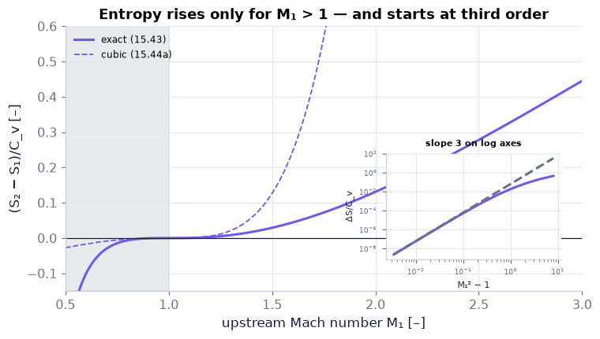

```python
M1 = np.linspace(0.5, 3.0, 300)                              # upstream Mach numbers on both sides of 1
dS = GD.normal_shock_entropy(M1)                             # (15.43) with the jumps inserted (D16 step 5)
cubic = GD.weak_shock_entropy(M1, form="mach")               # (15.44a): the cubic of D17
fig, ax = plt.subplots(figsize=(6.8, 3.8))                   # main panel
ax.axvspan(0.5, 1.0, color=COLORS["muted"], alpha=0.15)      # entropy would fall here: forbidden
ax.plot(M1, dS, color=COLORS["accent"], lw=2, label="exact (15.43)")      # entropy jump (purple)
ax.plot(M1, cubic, color=COLORS["accent"], ls="--", lw=1.2, label="cubic (15.44a)")   # its weak-shock form
ax.axhline(0, color=COLORS["ink"], lw=0.8)                   # zero
ax.set(xlim=(0.5, 3.0), ylim=(-0.15, 0.6), xlabel="upstream Mach number M₁ [–]", ylabel="(S₂ − S₁)/C_v [–]",
       title="Entropy rises only for M₁ > 1 — and starts at third order")
ax.legend(fontsize=8, loc="upper left")
ins = ax.inset_axes([0.62, 0.12, 0.34, 0.4])                 # a small log–log inset
eps = M1[M1 > 1.001]**2 - 1                                  # epsilon = M1² - 1 > 0
ins.loglog(eps, GD.normal_shock_entropy(np.sqrt(1 + eps)), color=COLORS["accent"])   # exact
ins.loglog(eps, 0.0648 * eps**3, color=COLORS["muted"], ls="--")   # slope 3 reference (coefficient of (15.44a))
ins.set_xlabel("M₁² − 1", fontsize=7); ins.set_ylabel("ΔS/C_v", fontsize=7); ins.tick_params(labelsize=6)
ins.set_title("slope 3 on log axes", fontsize=7)
savefig(fig, "ch15", "c08_entropy"); plt.show()
```

**What you see.** The entropy jump of a normal shock against $M_1$ (solid), the cubic $\dfrac{S_2-S_1}{C_v}\cong\dfrac{2\gamma(\gamma-1)}{3(\gamma+1)^2}\left(M_1^2-1\right)^3$ (15.44a) (dashed), the forbidden half shaded, and an inset with both axes logarithmic (each tick a factor 10).

**How to read it.** The curve crosses zero at $M_1=1$ with zero slope *and* zero curvature — it starts like a cube. Left of 1 it is negative: an expansion shock would destroy entropy. In the inset the exact curve runs parallel to a line of slope 3: a factor 10 in $M_1^2-1$ gives a factor 1000 in entropy.

**What would change if…** …we kept only the first two orders of the expansion? We would get zero — the reason D17 must go to third order.

📝 **Note.** **N61 [B]** Reading $\dfrac{S_2-S_1}{C_v}=\ln\left[\dfrac{p_2}{p_1}\left(\dfrac{\rho_1}{\rho_2}\right)^{\gamma}\right]$ (15.43): $S_2-S_1>0\iff M_1>1$. So $M_1>1$, $M_2<1$, compression only (for a perfect gas; expansion shocks need another equation of state — N90 in C12). Weak shocks are nearly isentropic, which is why even loud sound is still acoustics (C01).

```python
print(GD.shock_admissible(2.0), GD.shock_admissible(0.7))    # True, False: the second law's verdict
print(GD.normal_shock_entropy(0.7))                          # -0.0295: entropy would fall
```

```
True False
-0.029542068036409408
```

> 📎 **Primer — the series of ln(1 + x) to third order.** `P364` · $\ln(1+x)=x-\tfrac12x^2+\tfrac13x^3-\dots$ for small x. When several logarithms are added, their x and x² terms can cancel *exactly*, and the answer is then of third order — you must keep every x³.

```python
import sympy as sp
x = sp.symbols('x')
print(sp.series(sp.log(1 + x), x, 0, 4))                    # x - x**2/2 + x**3/3 + O(x**4)
print(sp.series(sp.log(1 + 2*x) - 2*sp.log(1 + x), x, 0, 4))   # -x**2 + 2*x**3 + ...: first order cancelled
```

```
x - x**2/2 + x**3/3 + O(x**4)
-x**2 + 2*x**3 + O(x**4)
```